# CHIC Landscape Analysis Exploratory Analysis

###### City

| question | city | base_size | Very Difficult | Difficult | Somewhat Difficult | Somewhat Easy | Easy | Very Easy |
| --- | --- | --- | --- | --- | --- | --- | --- | --- |
| Adult Education (e.g. associates degree, college, retraining) | Aurora | 6 | 16.67% | 33.33% | 16.67% | 16.67% | 16.67% | NA |
| Adult Education (e.g. associates degree, college, retraining) | Denver | 11 | 9.09% | 9.09% | 45.45% | 18.18% | NA | 9.09% |
| Advocacy (e.g. legal support, legal aid, immigration assistance, police justice) | Aurora | 3 | NA | 66.67% | 33.33% | NA | NA | NA |
| Advocacy (e.g. legal support, legal aid, immigration assistance, police justice) | Denver | 2 | NA | 50% | 50% | NA | NA | NA |
| Business assistance (e.g. startup assistance, startup financial capital, business development) | Aurora | 10 | 70% | 10% | NA | 10% | NA | 10% |
| Business assistance (e.g. startup assistance, startup financial capital, business development) | Denver | 13 | 23.08% | 15.38% | 38.46% | 23.08% | NA | NA |
| Criminal justice | Aurora | 2 | NA | 50% | 50% | NA | NA | NA |
| Criminal justice | Denver | 4 | 50% | NA | 25% | NA | NA | NA |
| Education (e.g. summer, after school, and enrichment) | Aurora | 23 | 21.74% | 17.39% | 17.39% | 30.43% | 13.04% | NA |
| Education (e.g. summer, after school, and enrichment) | Berkley | 1 | NA | NA | NA | 100% | NA | NA |
| Education (e.g. summer, after school, and enrichment) | Commerce City | 1 | NA | NA | NA | NA | 100% | NA |
| Education (e.g. summer, after school, and enrichment) | Denver | 40 | 12.5% | 10% | 35% | 17.5% | 12.5% | 10% |
| Education (e.g. summer, after school, and enrichment) | Lakewood | 1 | NA | NA | NA | NA | NA | NA |
| Education (e.g. summer, after school, and enrichment) | Thornton | 1 | NA | NA | NA | NA | NA | NA |
| Employment assistance (e.g. workforce development, job placement) | Aurora | 10 | 50% | 30% | 10% | 10% | NA | NA |
| Employment assistance (e.g. workforce development, job placement) | Denver | 6 | 16.67% | 33.33% | 16.67% | 16.67% | 16.67% | NA |
| Financial assistance (e.g. banking, financial planning) | Aurora | 13 | 46.15% | 23.08% | 15.38% | 7.69% | 7.69% | NA |
| Financial assistance (e.g. banking, financial planning) | Denver | 16 | 12.5% | 31.25% | 37.5% | 18.75% | NA | NA |
| Health (e.g. basic health care, health clinics) | Aurora | 20 | 5% | 15% | 15% | 25% | 25% | 10% |
| Health (e.g. basic health care, health clinics) | Commerce City | 1 | NA | NA | 100% | NA | NA | NA |
| Health (e.g. basic health care, health clinics) | Denver | 28 | 3.57% | 14.29% | 25% | 32.14% | 7.14% | 14.29% |
| Health (e.g. basic health care, health clinics) | Thornton | 1 | NA | NA | NA | 100% | NA | NA |
| Housing assistance (e.g. affordable housing, home purchase assistance, rent/mortgage assistance) | Aurora | 27 | 51.85% | 37.04% | 7.41% | NA | 3.7% | NA |
| Housing assistance (e.g. affordable housing, home purchase assistance, rent/mortgage assistance) | Denver | 31 | 38.71% | 12.9% | 22.58% | 16.13% | 6.45% | NA |
| Housing assistance (e.g. affordable housing, home purchase assistance, rent/mortgage assistance) | Lakewood | 1 | 100% | NA | NA | NA | NA | NA |
| Housing assistance (e.g. affordable housing, home purchase assistance, rent/mortgage assistance) | Thornton | 1 | NA | 100% | NA | NA | NA | NA |
| Mental Health (e.g. counseling, therapy) | Aurora | 18 | 16.67% | 16.67% | 16.67% | 33.33% | 11.11% | NA |
| Mental Health (e.g. counseling, therapy) | Berkley | 1 | 100% | NA | NA | NA | NA | NA |
| Mental Health (e.g. counseling, therapy) | Denver | 14 | 14.29% | 7.14% | 28.57% | 7.14% | 21.43% | 14.29% |
| Mental Health (e.g. counseling, therapy) | Lakewood | 1 | NA | 100% | NA | NA | NA | NA |
| Youth safety (e.g. youth/young adult support and mentorship, gang alternatives, gang intervention) | Aurora | 18 | 44.44% | 27.78% | NA | 11.11% | 5.56% | NA |
| Youth safety (e.g. youth/young adult support and mentorship, gang alternatives, gang intervention) | Berkley | 1 | NA | NA | 100% | NA | NA | NA |
| Youth safety (e.g. youth/young adult support and mentorship, gang alternatives, gang intervention) | Commerce City | 1 | NA | NA | NA | 100% | NA | NA |
| Youth safety (e.g. youth/young adult support and mentorship, gang alternatives, gang intervention) | Denver | 24 | 12.5% | 20.83% | 25% | 25% | 12.5% | NA |

#### Community Q8. How EFFECTIVE or INEFFECTIVE are community supports or resources for the following needs?

##### All Respondents

###### Total

| question | base_size | Very Ineffective | Ineffective | Somewhat Ineffective | Somewhat Effective | Effective | Very Effective |
| --- | --- | --- | --- | --- | --- | --- | --- |
| Adult Education (e.g. associates degree, college, retraining) | 19 | 15.79% | 21.05% | 15.79% | 31.58% | 10.53% | 5.26% |
| Advocacy (e.g. legal support, legal aid, immigration assistance, police justice) | 8 | NA | 50% | 37.5% | NA | NA | 12.5% |
| Business assistance (e.g. startup assistance, startup financial capital, business development) | 27 | 40.74% | 22.22% | 7.41% | 14.81% | 7.41% | 7.41% |
| Criminal justice | 7 | 28.57% | NA | 14.29% | 14.29% | 14.29% | 28.57% |
| Education (e.g. summer, after school, and enrichment) | 93 | 9.68% | 10.75% | 19.35% | 27.96% | 21.51% | 10.75% |
| Employment assistance (e.g. workforce development, job placement) | 27 | 33.33% | 22.22% | 7.41% | 29.63% | 3.7% | 3.7% |
| Financial assistance (e.g. banking, financial planning) | 44 | 20.45% | 9.09% | 25% | 34.09% | 6.82% | 4.55% |
| Health (e.g. basic health care, health clinics) | 74 | 8.11% | 14.86% | 10.81% | 39.19% | 14.86% | 12.16% |
| Housing assistance (e.g. affordable housing, home purchase assistance, rent/mortgage assistance) | 80 | 32.5% | 16.25% | 18.75% | 15% | 8.75% | 8.75% |
| Mental Health (e.g. counseling, therapy) | 48 | 20.83% | 4.17% | 18.75% | 22.92% | 20.83% | 12.5% |
| Youth safety (e.g. youth/young adult support and mentorship, gang alternatives, gang intervention) | 59 | 22.03% | 22.03% | 11.86% | 22.03% | 15.25% | 6.78% |

###### Race

| question | race | base_size | Very Ineffective | Ineffective | Somewhat Ineffective | Somewhat Effective | Effective | Very Effective |
| --- | --- | --- | --- | --- | --- | --- | --- | --- |
| Adult Education (e.g. associates degree, college, retraining) | 2 or More Race/Ethnicities | 4 | 25% | 25% | 25% | NA | NA | 25% |
| Adult Education (e.g. associates degree, college, retraining) | Black or African American | 9 | 22.22% | 22.22% | 11.11% | 33.33% | 11.11% | NA |
| Adult Education (e.g. associates degree, college, retraining) | Hispanic, Latino, or Spanish origin | 5 | NA | 20% | 20% | 40% | 20% | NA |
| Adult Education (e.g. associates degree, college, retraining) | White | 1 | NA | NA | NA | 100% | NA | NA |
| Advocacy (e.g. legal support, legal aid, immigration assistance, police justice) | Black or African American | 1 | NA | 100% | NA | NA | NA | NA |
| Advocacy (e.g. legal support, legal aid, immigration assistance, police justice) | Hispanic, Latino, or Spanish origin | 5 | NA | 60% | 40% | NA | NA | NA |
| Advocacy (e.g. legal support, legal aid, immigration assistance, police justice) | White | 2 | NA | NA | 50% | NA | NA | 50% |
| Business assistance (e.g. startup assistance, startup financial capital, business development) | 2 or More Race/Ethnicities | 7 | 42.86% | 14.29% | NA | 14.29% | NA | 28.57% |
| Business assistance (e.g. startup assistance, startup financial capital, business development) | Black or African American | 14 | 21.43% | 28.57% | 14.29% | 21.43% | 14.29% | NA |
| Business assistance (e.g. startup assistance, startup financial capital, business development) | Hispanic, Latino, or Spanish origin | 2 | 100% | NA | NA | NA | NA | NA |
| Business assistance (e.g. startup assistance, startup financial capital, business development) | Prefer not to say | 1 | 100% | NA | NA | NA | NA | NA |
| Business assistance (e.g. startup assistance, startup financial capital, business development) | White | 1 | 100% | NA | NA | NA | NA | NA |
| Business assistance (e.g. startup assistance, startup financial capital, business development) | NA | 2 | 50% | 50% | NA | NA | NA | NA |
| Criminal justice | 2 or More Race/Ethnicities | 1 | 100% | NA | NA | NA | NA | NA |
| Criminal justice | Black or African American | 4 | 25% | NA | NA | 25% | 25% | 25% |
| Criminal justice | Hispanic, Latino, or Spanish origin | 1 | NA | NA | 100% | NA | NA | NA |
| Criminal justice | White | 1 | NA | NA | NA | NA | NA | 100% |
| Education (e.g. summer, after school, and enrichment) | 2 or More Race/Ethnicities | 15 | 6.67% | 13.33% | 13.33% | 20% | 20% | 26.67% |
| Education (e.g. summer, after school, and enrichment) | Asian | 1 | NA | NA | NA | 100% | NA | NA |
| Education (e.g. summer, after school, and enrichment) | Black or African American | 34 | 14.71% | 5.88% | 11.76% | 38.24% | 26.47% | 2.94% |
| Education (e.g. summer, after school, and enrichment) | Hispanic, Latino, or Spanish origin | 18 | 5.56% | 16.67% | 33.33% | 16.67% | 22.22% | 5.56% |
| Education (e.g. summer, after school, and enrichment) | Prefer not to say | 6 | 16.67% | 16.67% | 33.33% | 16.67% | NA | 16.67% |
| Education (e.g. summer, after school, and enrichment) | White | 15 | 6.67% | 13.33% | 20% | 20% | 26.67% | 13.33% |
| Education (e.g. summer, after school, and enrichment) | NA | 4 | NA | NA | 25% | 50% | NA | 25% |
| Employment assistance (e.g. workforce development, job placement) | 2 or More Race/Ethnicities | 5 | 20% | 60% | NA | NA | NA | 20% |
| Employment assistance (e.g. workforce development, job placement) | American Indian or Alaska Native | 1 | NA | NA | NA | 100% | NA | NA |
| Employment assistance (e.g. workforce development, job placement) | Black or African American | 5 | 40% | NA | 20% | 40% | NA | NA |
| Employment assistance (e.g. workforce development, job placement) | Hispanic, Latino, or Spanish origin | 10 | 40% | 20% | 10% | 30% | NA | NA |
| Employment assistance (e.g. workforce development, job placement) | White | 4 | 25% | 25% | NA | 25% | 25% | NA |
| Employment assistance (e.g. workforce development, job placement) | NA | 2 | 50% | NA | NA | 50% | NA | NA |
| Financial assistance (e.g. banking, financial planning) | 2 or More Race/Ethnicities | 6 | 50% | NA | NA | 33.33% | NA | 16.67% |
| Financial assistance (e.g. banking, financial planning) | Black or African American | 17 | 5.88% | 11.76% | 47.06% | 23.53% | 5.88% | 5.88% |
| Financial assistance (e.g. banking, financial planning) | Hispanic, Latino, or Spanish origin | 7 | 28.57% | 14.29% | 28.57% | 28.57% | NA | NA |
| Financial assistance (e.g. banking, financial planning) | White | 12 | 25% | 8.33% | NA | 50% | 16.67% | NA |
| Financial assistance (e.g. banking, financial planning) | NA | 2 | NA | NA | 50% | 50% | NA | NA |
| Health (e.g. basic health care, health clinics) | 2 or More Race/Ethnicities | 13 | 15.38% | 15.38% | 15.38% | 30.77% | NA | 23.08% |
| Health (e.g. basic health care, health clinics) | Asian | 1 | NA | NA | 100% | NA | NA | NA |
| Health (e.g. basic health care, health clinics) | Black or African American | 25 | NA | 16% | 4% | 40% | 28% | 12% |
| Health (e.g. basic health care, health clinics) | Hispanic, Latino, or Spanish origin | 22 | 13.64% | 22.73% | 13.64% | 31.82% | 9.09% | 9.09% |
| Health (e.g. basic health care, health clinics) | Prefer not to say | 4 | NA | NA | NA | 100% | NA | NA |
| Health (e.g. basic health care, health clinics) | White | 8 | 12.5% | NA | 12.5% | 50% | 12.5% | 12.5% |
| Health (e.g. basic health care, health clinics) | NA | 1 | NA | NA | NA | NA | 100% | NA |
| Housing assistance (e.g. affordable housing, home purchase assistance, rent/mortgage assistance) | 2 or More Race/Ethnicities | 18 | 27.78% | 27.78% | NA | 5.56% | 16.67% | 22.22% |
| Housing assistance (e.g. affordable housing, home purchase assistance, rent/mortgage assistance) | American Indian or Alaska Native | 1 | NA | NA | NA | 100% | NA | NA |
| Housing assistance (e.g. affordable housing, home purchase assistance, rent/mortgage assistance) | Asian | 1 | 100% | NA | NA | NA | NA | NA |
| Housing assistance (e.g. affordable housing, home purchase assistance, rent/mortgage assistance) | Black or African American | 31 | 29.03% | 19.35% | 25.81% | 12.9% | 9.68% | 3.23% |
| Housing assistance (e.g. affordable housing, home purchase assistance, rent/mortgage assistance) | Hispanic, Latino, or Spanish origin | 14 | 42.86% | 7.14% | 35.71% | 14.29% | NA | NA |
| Housing assistance (e.g. affordable housing, home purchase assistance, rent/mortgage assistance) | Prefer not to say | 5 | 20% | NA | 20% | 40% | NA | 20% |
| Housing assistance (e.g. affordable housing, home purchase assistance, rent/mortgage assistance) | White | 6 | 33.33% | NA | 16.67% | 16.67% | 16.67% | 16.67% |
| Housing assistance (e.g. affordable housing, home purchase assistance, rent/mortgage assistance) | NA | 4 | 50% | 25% | NA | 25% | NA | NA |
| Mental Health (e.g. counseling, therapy) | 2 or More Race/Ethnicities | 9 | 22.22% | 11.11% | 22.22% | 11.11% | 11.11% | 22.22% |
| Mental Health (e.g. counseling, therapy) | Black or African American | 13 | 15.38% | NA | 7.69% | 38.46% | 38.46% | NA |
| Mental Health (e.g. counseling, therapy) | Hispanic, Latino, or Spanish origin | 12 | 25% | 8.33% | 25% | 33.33% | 8.33% | NA |
| Mental Health (e.g. counseling, therapy) | Prefer not to say | 4 | 25% | NA | 25% | NA | 50% | NA |
| Mental Health (e.g. counseling, therapy) | White | 9 | 22.22% | NA | 22.22% | 11.11% | 11.11% | 33.33% |
| Mental Health (e.g. counseling, therapy) | NA | 1 | NA | NA | NA | NA | NA | 100% |
| Youth safety (e.g. youth/young adult support and mentorship, gang alternatives, gang intervention) | 2 or More Race/Ethnicities | 12 | 25% | 8.33% | 16.67% | 16.67% | 8.33% | 25% |
| Youth safety (e.g. youth/young adult support and mentorship, gang alternatives, gang intervention) | American Indian or Alaska Native | 1 | NA | NA | 100% | NA | NA | NA |
| Youth safety (e.g. youth/young adult support and mentorship, gang alternatives, gang intervention) | Black or African American | 24 | 29.17% | 20.83% | 4.17% | 29.17% | 12.5% | 4.17% |
| Youth safety (e.g. youth/young adult support and mentorship, gang alternatives, gang intervention) | Hispanic, Latino, or Spanish origin | 14 | 14.29% | 35.71% | 21.43% | 21.43% | 7.14% | NA |
| Youth safety (e.g. youth/young adult support and mentorship, gang alternatives, gang intervention) | Prefer not to say | 4 | 25% | 25% | NA | NA | 50% | NA |
| Youth safety (e.g. youth/young adult support and mentorship, gang alternatives, gang intervention) | White | 4 | NA | 25% | NA | 25% | 50% | NA |

###### Gender Identity

| question | gender_identity | base_size | Very Ineffective | Ineffective | Somewhat Ineffective | Somewhat Effective | Effective | Very Effective |
| --- | --- | --- | --- | --- | --- | --- | --- | --- |
| Adult Education (e.g. associates degree, college, retraining) | Female | 16 | 12.5% | 18.75% | 18.75% | 31.25% | 12.5% | 6.25% |
| Adult Education (e.g. associates degree, college, retraining) | Male | 2 | 50% | 50% | NA | NA | NA | NA |
| Adult Education (e.g. associates degree, college, retraining) | Transgender Male | 1 | NA | NA | NA | 100% | NA | NA |
| Advocacy (e.g. legal support, legal aid, immigration assistance, police justice) | Female | 5 | NA | 60% | 40% | NA | NA | NA |
| Advocacy (e.g. legal support, legal aid, immigration assistance, police justice) | Male | 2 | NA | 50% | NA | NA | NA | 50% |
| Advocacy (e.g. legal support, legal aid, immigration assistance, police justice) | Transgender Male | 1 | NA | NA | 100% | NA | NA | NA |
| Business assistance (e.g. startup assistance, startup financial capital, business development) | Female | 24 | 41.67% | 20.83% | 4.17% | 16.67% | 8.33% | 8.33% |
| Business assistance (e.g. startup assistance, startup financial capital, business development) | Male | 1 | NA | NA | 100% | NA | NA | NA |
| Business assistance (e.g. startup assistance, startup financial capital, business development) | NA | 2 | 50% | 50% | NA | NA | NA | NA |
| Criminal justice | Female | 6 | 33.33% | NA | 16.67% | 16.67% | 16.67% | 16.67% |
| Criminal justice | Male | 1 | NA | NA | NA | NA | NA | 100% |
| Education (e.g. summer, after school, and enrichment) | Female | 80 | 10% | 11.25% | 17.5% | 27.5% | 23.75% | 10% |
| Education (e.g. summer, after school, and enrichment) | Male | 7 | NA | 14.29% | 42.86% | 28.57% | 14.29% | NA |
| Education (e.g. summer, after school, and enrichment) | Prefer not to say | 2 | 50% | NA | NA | NA | NA | 50% |
| Education (e.g. summer, after school, and enrichment) | NA | 4 | NA | NA | 25% | 50% | NA | 25% |
| Employment assistance (e.g. workforce development, job placement) | Female | 19 | 31.58% | 21.05% | 10.53% | 26.32% | 5.26% | 5.26% |
| Employment assistance (e.g. workforce development, job placement) | Male | 6 | 33.33% | 33.33% | NA | 33.33% | NA | NA |
| Employment assistance (e.g. workforce development, job placement) | NA | 2 | 50% | NA | NA | 50% | NA | NA |
| Financial assistance (e.g. banking, financial planning) | Female | 39 | 23.08% | 10.26% | 25.64% | 30.77% | 5.13% | 5.13% |
| Financial assistance (e.g. banking, financial planning) | Male | 3 | NA | NA | NA | 66.67% | 33.33% | NA |
| Financial assistance (e.g. banking, financial planning) | NA | 2 | NA | NA | 50% | 50% | NA | NA |
| Health (e.g. basic health care, health clinics) | Female | 59 | 6.78% | 13.56% | 10.17% | 37.29% | 16.95% | 15.25% |
| Health (e.g. basic health care, health clinics) | Male | 11 | 18.18% | 18.18% | 18.18% | 45.45% | NA | NA |
| Health (e.g. basic health care, health clinics) | Prefer not to say | 1 | NA | NA | NA | 100% | NA | NA |
| Health (e.g. basic health care, health clinics) | Transgender Male | 1 | NA | NA | NA | 100% | NA | NA |
| Health (e.g. basic health care, health clinics) | NA | 2 | NA | 50% | NA | NA | 50% | NA |
| Housing assistance (e.g. affordable housing, home purchase assistance, rent/mortgage assistance) | Female | 64 | 32.81% | 14.06% | 23.44% | 10.94% | 10.94% | 7.81% |
| Housing assistance (e.g. affordable housing, home purchase assistance, rent/mortgage assistance) | Male | 8 | 25% | 25% | NA | 37.5% | NA | 12.5% |
| Housing assistance (e.g. affordable housing, home purchase assistance, rent/mortgage assistance) | Prefer not to say | 3 | 33.33% | NA | NA | 33.33% | NA | 33.33% |
| Housing assistance (e.g. affordable housing, home purchase assistance, rent/mortgage assistance) | NA | 5 | 40% | 40% | NA | 20% | NA | NA |
| Mental Health (e.g. counseling, therapy) | Female | 42 | 21.43% | 2.38% | 19.05% | 26.19% | 19.05% | 11.9% |
| Mental Health (e.g. counseling, therapy) | Male | 2 | NA | 50% | 50% | NA | NA | NA |
| Mental Health (e.g. counseling, therapy) | Prefer not to say | 3 | 33.33% | NA | NA | NA | 66.67% | NA |
| Mental Health (e.g. counseling, therapy) | NA | 1 | NA | NA | NA | NA | NA | 100% |
| Youth safety (e.g. youth/young adult support and mentorship, gang alternatives, gang intervention) | Female | 47 | 21.28% | 19.15% | 10.64% | 27.66% | 12.77% | 8.51% |
| Youth safety (e.g. youth/young adult support and mentorship, gang alternatives, gang intervention) | Male | 8 | 25% | 50% | 12.5% | NA | 12.5% | NA |
| Youth safety (e.g. youth/young adult support and mentorship, gang alternatives, gang intervention) | Prefer not to say | 3 | 33.33% | NA | NA | NA | 66.67% | NA |
| Youth safety (e.g. youth/young adult support and mentorship, gang alternatives, gang intervention) | NA | 1 | NA | NA | 100% | NA | NA | NA |

###### Age Band

| question | age | base_size | Very Ineffective | Ineffective | Somewhat Ineffective | Somewhat Effective | Effective | Very Effective |
| --- | --- | --- | --- | --- | --- | --- | --- | --- |
| Adult Education (e.g. associates degree, college, retraining) | 18-24 | 3 | 33.33% | NA | NA | 33.33% | 33.33% | NA |
| Adult Education (e.g. associates degree, college, retraining) | 25-34 | 7 | 14.29% | 14.29% | NA | 57.14% | NA | 14.29% |
| Adult Education (e.g. associates degree, college, retraining) | 35-44 | 3 | NA | NA | 66.67% | NA | 33.33% | NA |
| Adult Education (e.g. associates degree, college, retraining) | 45-54 | 3 | NA | 66.67% | 33.33% | NA | NA | NA |
| Adult Education (e.g. associates degree, college, retraining) | 55-64 | 3 | 33.33% | 33.33% | NA | 33.33% | NA | NA |
| Advocacy (e.g. legal support, legal aid, immigration assistance, police justice) | 18-24 | 2 | NA | NA | 100% | NA | NA | NA |
| Advocacy (e.g. legal support, legal aid, immigration assistance, police justice) | 35-44 | 5 | NA | 60% | 20% | NA | NA | 20% |
| Advocacy (e.g. legal support, legal aid, immigration assistance, police justice) | 45-54 | 1 | NA | 100% | NA | NA | NA | NA |
| Business assistance (e.g. startup assistance, startup financial capital, business development) | 18-24 | 1 | 100% | NA | NA | NA | NA | NA |
| Business assistance (e.g. startup assistance, startup financial capital, business development) | 25-34 | 10 | 40% | 10% | 10% | 40% | NA | NA |
| Business assistance (e.g. startup assistance, startup financial capital, business development) | 35-44 | 7 | 42.86% | 14.29% | 14.29% | NA | 14.29% | 14.29% |
| Business assistance (e.g. startup assistance, startup financial capital, business development) | 45-54 | 3 | 33.33% | 33.33% | NA | NA | NA | 33.33% |
| Business assistance (e.g. startup assistance, startup financial capital, business development) | 55-64 | 2 | NA | 50% | NA | NA | 50% | NA |
| Business assistance (e.g. startup assistance, startup financial capital, business development) | 65+ | 2 | 50% | 50% | NA | NA | NA | NA |
| Business assistance (e.g. startup assistance, startup financial capital, business development) | NA | 2 | 50% | 50% | NA | NA | NA | NA |
| Criminal justice | 25-34 | 2 | NA | NA | 50% | 50% | NA | NA |
| Criminal justice | 35-44 | 4 | 25% | NA | NA | NA | 25% | 50% |
| Criminal justice | 45-54 | 1 | 100% | NA | NA | NA | NA | NA |
| Education (e.g. summer, after school, and enrichment) | 18-24 | 4 | 25% | NA | 25% | 25% | 25% | NA |
| Education (e.g. summer, after school, and enrichment) | 25-34 | 37 | 5.41% | 8.11% | 18.92% | 27.03% | 24.32% | 16.22% |
| Education (e.g. summer, after school, and enrichment) | 35-44 | 28 | 10.71% | 10.71% | 21.43% | 25% | 21.43% | 10.71% |
| Education (e.g. summer, after school, and enrichment) | 45-54 | 11 | 9.09% | 9.09% | 18.18% | 54.55% | 9.09% | NA |
| Education (e.g. summer, after school, and enrichment) | 55-64 | 5 | 20% | NA | 20% | NA | 60% | NA |
| Education (e.g. summer, after school, and enrichment) | 65+ | 4 | 25% | 75% | NA | NA | NA | NA |
| Education (e.g. summer, after school, and enrichment) | NA | 4 | NA | NA | 25% | 50% | NA | 25% |
| Employment assistance (e.g. workforce development, job placement) | 18-24 | 2 | NA | NA | 100% | NA | NA | NA |
| Employment assistance (e.g. workforce development, job placement) | 25-34 | 6 | 33.33% | 16.67% | NA | 50% | NA | NA |
| Employment assistance (e.g. workforce development, job placement) | 35-44 | 8 | 12.5% | 50% | NA | 12.5% | 12.5% | 12.5% |
| Employment assistance (e.g. workforce development, job placement) | 45-54 | 7 | 57.14% | 14.29% | NA | 28.57% | NA | NA |
| Employment assistance (e.g. workforce development, job placement) | 55-64 | 1 | NA | NA | NA | 100% | NA | NA |
| Employment assistance (e.g. workforce development, job placement) | Under 18 | 1 | 100% | NA | NA | NA | NA | NA |
| Employment assistance (e.g. workforce development, job placement) | NA | 2 | 50% | NA | NA | 50% | NA | NA |
| Financial assistance (e.g. banking, financial planning) | 18-24 | 4 | NA | 25% | 50% | 25% | NA | NA |
| Financial assistance (e.g. banking, financial planning) | 25-34 | 21 | 23.81% | 9.52% | 9.52% | 33.33% | 14.29% | 9.52% |
| Financial assistance (e.g. banking, financial planning) | 35-44 | 9 | 22.22% | 11.11% | 33.33% | 33.33% | NA | NA |
| Financial assistance (e.g. banking, financial planning) | 45-54 | 5 | 40% | NA | 60% | NA | NA | NA |
| Financial assistance (e.g. banking, financial planning) | 55-64 | 3 | NA | NA | NA | 100% | NA | NA |
| Financial assistance (e.g. banking, financial planning) | NA | 2 | NA | NA | 50% | 50% | NA | NA |
| Health (e.g. basic health care, health clinics) | 18-24 | 5 | 20% | 20% | 20% | 20% | NA | 20% |
| Health (e.g. basic health care, health clinics) | 25-34 | 28 | 10.71% | 17.86% | 10.71% | 39.29% | 3.57% | 17.86% |
| Health (e.g. basic health care, health clinics) | 35-44 | 23 | 8.7% | 21.74% | 8.7% | 39.13% | 17.39% | 4.35% |
| Health (e.g. basic health care, health clinics) | 45-54 | 11 | NA | NA | 18.18% | 45.45% | 27.27% | 9.09% |
| Health (e.g. basic health care, health clinics) | 55-64 | 5 | NA | NA | NA | 60% | 40% | NA |
| Health (e.g. basic health care, health clinics) | Under 18 | 1 | NA | NA | NA | NA | NA | 100% |
| Health (e.g. basic health care, health clinics) | NA | 1 | NA | NA | NA | NA | 100% | NA |
| Housing assistance (e.g. affordable housing, home purchase assistance, rent/mortgage assistance) | 18-24 | 4 | NA | 25% | 75% | NA | NA | NA |
| Housing assistance (e.g. affordable housing, home purchase assistance, rent/mortgage assistance) | 25-34 | 33 | 30.3% | 9.09% | 12.12% | 24.24% | 15.15% | 9.09% |
| Housing assistance (e.g. affordable housing, home purchase assistance, rent/mortgage assistance) | 35-44 | 17 | 29.41% | 29.41% | 17.65% | 5.88% | NA | 17.65% |
| Housing assistance (e.g. affordable housing, home purchase assistance, rent/mortgage assistance) | 45-54 | 15 | 40% | 20% | 20% | 13.33% | 6.67% | NA |
| Housing assistance (e.g. affordable housing, home purchase assistance, rent/mortgage assistance) | 55-64 | 3 | 33.33% | NA | 33.33% | NA | 33.33% | NA |
| Housing assistance (e.g. affordable housing, home purchase assistance, rent/mortgage assistance) | 65+ | 3 | 66.67% | NA | 33.33% | NA | NA | NA |
| Housing assistance (e.g. affordable housing, home purchase assistance, rent/mortgage assistance) | Under 18 | 1 | NA | NA | NA | NA | NA | 100% |
| Housing assistance (e.g. affordable housing, home purchase assistance, rent/mortgage assistance) | NA | 4 | 50% | 25% | NA | 25% | NA | NA |
| Mental Health (e.g. counseling, therapy) | 18-24 | 3 | 66.67% | NA | NA | NA | 33.33% | NA |
| Mental Health (e.g. counseling, therapy) | 25-34 | 16 | 12.5% | NA | 25% | 18.75% | 25% | 18.75% |
| Mental Health (e.g. counseling, therapy) | 35-44 | 14 | 14.29% | 7.14% | 28.57% | 35.71% | 14.29% | NA |
| Mental Health (e.g. counseling, therapy) | 45-54 | 7 | 42.86% | NA | NA | 28.57% | 14.29% | 14.29% |
| Mental Health (e.g. counseling, therapy) | 55-64 | 5 | 20% | NA | 20% | 20% | 40% | NA |
| Mental Health (e.g. counseling, therapy) | 65+ | 2 | NA | 50% | NA | NA | NA | 50% |
| Mental Health (e.g. counseling, therapy) | NA | 1 | NA | NA | NA | NA | NA | 100% |
| Youth safety (e.g. youth/young adult support and mentorship, gang alternatives, gang intervention) | 18-24 | 2 | 50% | NA | NA | 50% | NA | NA |
| Youth safety (e.g. youth/young adult support and mentorship, gang alternatives, gang intervention) | 25-34 | 23 | 13.04% | 26.09% | 8.7% | 21.74% | 21.74% | 8.7% |
| Youth safety (e.g. youth/young adult support and mentorship, gang alternatives, gang intervention) | 35-44 | 18 | 27.78% | 22.22% | 16.67% | 11.11% | 16.67% | 5.56% |
| Youth safety (e.g. youth/young adult support and mentorship, gang alternatives, gang intervention) | 45-54 | 8 | 25% | 12.5% | 25% | 25% | NA | 12.5% |
| Youth safety (e.g. youth/young adult support and mentorship, gang alternatives, gang intervention) | 55-64 | 5 | 20% | 20% | NA | 40% | 20% | NA |
| Youth safety (e.g. youth/young adult support and mentorship, gang alternatives, gang intervention) | 65+ | 3 | 33.33% | 33.33% | NA | 33.33% | NA | NA |

###### Num of Children

| question | children_range | base_size | Very Ineffective | Ineffective | Somewhat Ineffective | Somewhat Effective | Effective | Very Effective |
| --- | --- | --- | --- | --- | --- | --- | --- | --- |
| Adult Education (e.g. associates degree, college, retraining) | 0 | 3 | NA | NA | NA | 100% | NA | NA |
| Adult Education (e.g. associates degree, college, retraining) | 1-3 | 12 | 8.33% | 33.33% | 16.67% | 25% | 16.67% | NA |
| Adult Education (e.g. associates degree, college, retraining) | 4-6 | 2 | 50% | NA | 50% | NA | NA | NA |
| Adult Education (e.g. associates degree, college, retraining) | 7-10 | 1 | 100% | NA | NA | NA | NA | NA |
| Adult Education (e.g. associates degree, college, retraining) | NA | 1 | NA | NA | NA | NA | NA | 100% |
| Advocacy (e.g. legal support, legal aid, immigration assistance, police justice) | 0 | 1 | NA | NA | 100% | NA | NA | NA |
| Advocacy (e.g. legal support, legal aid, immigration assistance, police justice) | 1-3 | 4 | NA | 75% | 25% | NA | NA | NA |
| Advocacy (e.g. legal support, legal aid, immigration assistance, police justice) | 4-6 | 1 | NA | 100% | NA | NA | NA | NA |
| Advocacy (e.g. legal support, legal aid, immigration assistance, police justice) | NA | 2 | NA | NA | 50% | NA | NA | 50% |
| Business assistance (e.g. startup assistance, startup financial capital, business development) | 0 | 2 | 50% | NA | NA | NA | 50% | NA |
| Business assistance (e.g. startup assistance, startup financial capital, business development) | 1-3 | 19 | 47.37% | 21.05% | 5.26% | 10.53% | 5.26% | 10.53% |
| Business assistance (e.g. startup assistance, startup financial capital, business development) | 4-6 | 3 | NA | 33.33% | 33.33% | 33.33% | NA | NA |
| Business assistance (e.g. startup assistance, startup financial capital, business development) | NA | 3 | 33.33% | 33.33% | NA | 33.33% | NA | NA |
| Criminal justice | 0 | 1 | NA | NA | NA | 100% | NA | NA |
| Criminal justice | 1-3 | 5 | 40% | NA | 20% | NA | 20% | 20% |
| Criminal justice | NA | 1 | NA | NA | NA | NA | NA | 100% |
| Education (e.g. summer, after school, and enrichment) | 0 | 5 | 20% | 20% | 20% | NA | 40% | NA |
| Education (e.g. summer, after school, and enrichment) | 1-3 | 68 | 8.82% | 13.24% | 19.12% | 27.94% | 22.06% | 8.82% |
| Education (e.g. summer, after school, and enrichment) | 11+ | 1 | NA | NA | 100% | NA | NA | NA |
| Education (e.g. summer, after school, and enrichment) | 4-6 | 11 | NA | NA | 18.18% | 36.36% | 27.27% | 18.18% |
| Education (e.g. summer, after school, and enrichment) | 7-10 | 2 | 50% | NA | NA | 50% | NA | NA |
| Education (e.g. summer, after school, and enrichment) | NA | 6 | 16.67% | NA | 16.67% | 33.33% | NA | 33.33% |
| Employment assistance (e.g. workforce development, job placement) | 0 | 3 | 33.33% | NA | 33.33% | 33.33% | NA | NA |
| Employment assistance (e.g. workforce development, job placement) | 1-3 | 19 | 31.58% | 31.58% | NA | 31.58% | NA | 5.26% |
| Employment assistance (e.g. workforce development, job placement) | 4-6 | 2 | 50% | NA | NA | NA | 50% | NA |
| Employment assistance (e.g. workforce development, job placement) | NA | 3 | 33.33% | NA | 33.33% | 33.33% | NA | NA |
| Financial assistance (e.g. banking, financial planning) | 0 | 5 | NA | 20% | 20% | 60% | NA | NA |
| Financial assistance (e.g. banking, financial planning) | 1-3 | 26 | 23.08% | 7.69% | 23.08% | 34.62% | 7.69% | 3.85% |
| Financial assistance (e.g. banking, financial planning) | 4-6 | 8 | 25% | 12.5% | 25% | 25% | NA | 12.5% |
| Financial assistance (e.g. banking, financial planning) | 7-10 | 1 | NA | NA | NA | NA | 100% | NA |
| Financial assistance (e.g. banking, financial planning) | NA | 4 | 25% | NA | 50% | 25% | NA | NA |
| Health (e.g. basic health care, health clinics) | 0 | 11 | NA | 18.18% | 9.09% | 54.55% | 18.18% | NA |
| Health (e.g. basic health care, health clinics) | 1-3 | 49 | 8.16% | 14.29% | 12.24% | 34.69% | 16.33% | 14.29% |
| Health (e.g. basic health care, health clinics) | 11+ | 2 | NA | NA | 50% | 50% | NA | NA |
| Health (e.g. basic health care, health clinics) | 4-6 | 8 | 25% | 25% | NA | 37.5% | NA | 12.5% |
| Health (e.g. basic health care, health clinics) | 7-10 | 1 | NA | NA | NA | 100% | NA | NA |
| Health (e.g. basic health care, health clinics) | NA | 3 | NA | NA | NA | 33.33% | 33.33% | 33.33% |
| Housing assistance (e.g. affordable housing, home purchase assistance, rent/mortgage assistance) | 0 | 8 | 25% | 12.5% | 25% | 25% | 12.5% | NA |
| Housing assistance (e.g. affordable housing, home purchase assistance, rent/mortgage assistance) | 1-3 | 52 | 38.46% | 19.23% | 17.31% | 11.54% | 3.85% | 9.62% |
| Housing assistance (e.g. affordable housing, home purchase assistance, rent/mortgage assistance) | 11+ | 1 | NA | NA | 100% | NA | NA | NA |
| Housing assistance (e.g. affordable housing, home purchase assistance, rent/mortgage assistance) | 4-6 | 7 | NA | NA | 28.57% | 42.86% | 28.57% | NA |
| Housing assistance (e.g. affordable housing, home purchase assistance, rent/mortgage assistance) | 7-10 | 2 | 50% | 50% | NA | NA | NA | NA |
| Housing assistance (e.g. affordable housing, home purchase assistance, rent/mortgage assistance) | NA | 10 | 30% | 10% | 10% | 10% | 20% | 20% |
| Mental Health (e.g. counseling, therapy) | 0 | 11 | 18.18% | 9.09% | 9.09% | 36.36% | 27.27% | NA |
| Mental Health (e.g. counseling, therapy) | 1-3 | 29 | 24.14% | NA | 24.14% | 20.69% | 17.24% | 13.79% |
| Mental Health (e.g. counseling, therapy) | 4-6 | 5 | NA | 20% | 20% | 20% | 20% | 20% |
| Mental Health (e.g. counseling, therapy) | 7-10 | 1 | NA | NA | NA | NA | 100% | NA |
| Mental Health (e.g. counseling, therapy) | NA | 2 | 50% | NA | NA | NA | NA | 50% |
| Youth safety (e.g. youth/young adult support and mentorship, gang alternatives, gang intervention) | 0 | 7 | 42.86% | NA | NA | 28.57% | 28.57% | NA |
| Youth safety (e.g. youth/young adult support and mentorship, gang alternatives, gang intervention) | 1-3 | 37 | 13.51% | 24.32% | 16.22% | 18.92% | 16.22% | 10.81% |
| Youth safety (e.g. youth/young adult support and mentorship, gang alternatives, gang intervention) | 11+ | 1 | NA | 100% | NA | NA | NA | NA |
| Youth safety (e.g. youth/young adult support and mentorship, gang alternatives, gang intervention) | 4-6 | 9 | 22.22% | 33.33% | NA | 33.33% | 11.11% | NA |
| Youth safety (e.g. youth/young adult support and mentorship, gang alternatives, gang intervention) | 7-10 | 3 | 66.67% | NA | NA | 33.33% | NA | NA |
| Youth safety (e.g. youth/young adult support and mentorship, gang alternatives, gang intervention) | NA | 2 | 50% | NA | 50% | NA | NA | NA |

###### Is Children’s Caretaker

| question | childrens_caretaker | base_size | Very Ineffective | Ineffective | Somewhat Ineffective | Somewhat Effective | Effective | Very Effective |
| --- | --- | --- | --- | --- | --- | --- | --- | --- |
| Adult Education (e.g. associates degree, college, retraining) | No | 8 | 25% | 25% | 12.5% | 25% | NA | 12.5% |
| Adult Education (e.g. associates degree, college, retraining) | Yes | 10 | 10% | 20% | 20% | 30% | 20% | NA |
| Adult Education (e.g. associates degree, college, retraining) | NA | 1 | NA | NA | NA | 100% | NA | NA |
| Advocacy (e.g. legal support, legal aid, immigration assistance, police justice) | No | 4 | NA | 25% | 50% | NA | NA | 25% |
| Advocacy (e.g. legal support, legal aid, immigration assistance, police justice) | Yes | 4 | NA | 75% | 25% | NA | NA | NA |
| Business assistance (e.g. startup assistance, startup financial capital, business development) | No | 5 | 20% | 40% | NA | 20% | 20% | NA |
| Business assistance (e.g. startup assistance, startup financial capital, business development) | Yes | 20 | 45% | 15% | 10% | 15% | 5% | 10% |
| Business assistance (e.g. startup assistance, startup financial capital, business development) | NA | 2 | 50% | 50% | NA | NA | NA | NA |
| Criminal justice | No | 3 | NA | NA | 33.33% | 33.33% | NA | 33.33% |
| Criminal justice | Yes | 4 | 50% | NA | NA | NA | 25% | 25% |
| Education (e.g. summer, after school, and enrichment) | No | 9 | 33.33% | 22.22% | 11.11% | 11.11% | 22.22% | NA |
| Education (e.g. summer, after school, and enrichment) | Yes | 80 | 7.5% | 10% | 20% | 28.75% | 22.5% | 11.25% |
| Education (e.g. summer, after school, and enrichment) | NA | 4 | NA | NA | 25% | 50% | NA | 25% |
| Employment assistance (e.g. workforce development, job placement) | No | 6 | 16.67% | 16.67% | 33.33% | 33.33% | NA | NA |
| Employment assistance (e.g. workforce development, job placement) | Yes | 19 | 36.84% | 26.32% | NA | 26.32% | 5.26% | 5.26% |
| Employment assistance (e.g. workforce development, job placement) | NA | 2 | 50% | NA | NA | 50% | NA | NA |
| Financial assistance (e.g. banking, financial planning) | No | 5 | NA | 20% | 20% | 60% | NA | NA |
| Financial assistance (e.g. banking, financial planning) | Yes | 37 | 24.32% | 8.11% | 24.32% | 29.73% | 8.11% | 5.41% |
| Financial assistance (e.g. banking, financial planning) | NA | 2 | NA | NA | 50% | 50% | NA | NA |
| Health (e.g. basic health care, health clinics) | No | 17 | 5.88% | 11.76% | 11.76% | 41.18% | 11.76% | 17.65% |
| Health (e.g. basic health care, health clinics) | Yes | 56 | 8.93% | 16.07% | 10.71% | 39.29% | 14.29% | 10.71% |
| Health (e.g. basic health care, health clinics) | NA | 1 | NA | NA | NA | NA | 100% | NA |
| Housing assistance (e.g. affordable housing, home purchase assistance, rent/mortgage assistance) | No | 14 | 14.29% | 14.29% | 35.71% | 14.29% | 7.14% | 14.29% |
| Housing assistance (e.g. affordable housing, home purchase assistance, rent/mortgage assistance) | Yes | 61 | 36.07% | 16.39% | 14.75% | 14.75% | 9.84% | 8.2% |
| Housing assistance (e.g. affordable housing, home purchase assistance, rent/mortgage assistance) | NA | 5 | 40% | 20% | 20% | 20% | NA | NA |
| Mental Health (e.g. counseling, therapy) | No | 12 | 16.67% | 8.33% | 16.67% | 33.33% | 25% | NA |
| Mental Health (e.g. counseling, therapy) | Yes | 34 | 23.53% | 2.94% | 20.59% | 17.65% | 20.59% | 14.71% |
| Mental Health (e.g. counseling, therapy) | NA | 2 | NA | NA | NA | 50% | NA | 50% |
| Youth safety (e.g. youth/young adult support and mentorship, gang alternatives, gang intervention) | No | 11 | 45.45% | 18.18% | NA | 27.27% | 9.09% | NA |
| Youth safety (e.g. youth/young adult support and mentorship, gang alternatives, gang intervention) | Yes | 48 | 16.67% | 22.92% | 14.58% | 20.83% | 16.67% | 8.33% |

###### Marital Status

| question | marital_status | base_size | Very Ineffective | Ineffective | Somewhat Ineffective | Somewhat Effective | Effective | Very Effective |
| --- | --- | --- | --- | --- | --- | --- | --- | --- |
| Adult Education (e.g. associates degree, college, retraining) | Divorced | 5 | 40% | 40% | NA | 20% | NA | NA |
| Adult Education (e.g. associates degree, college, retraining) | Married or domestic partnership | 6 | NA | 16.67% | 50% | 33.33% | NA | NA |
| Adult Education (e.g. associates degree, college, retraining) | Single, never married | 8 | 12.5% | 12.5% | NA | 37.5% | 25% | 12.5% |
| Advocacy (e.g. legal support, legal aid, immigration assistance, police justice) | Divorced | 2 | NA | 50% | 50% | NA | NA | NA |
| Advocacy (e.g. legal support, legal aid, immigration assistance, police justice) | Married or domestic partnership | 3 | NA | 100% | NA | NA | NA | NA |
| Advocacy (e.g. legal support, legal aid, immigration assistance, police justice) | Single, never married | 3 | NA | NA | 66.67% | NA | NA | 33.33% |
| Business assistance (e.g. startup assistance, startup financial capital, business development) | Divorced | 9 | 44.44% | 33.33% | NA | NA | 11.11% | 11.11% |
| Business assistance (e.g. startup assistance, startup financial capital, business development) | Married or domestic partnership | 4 | 75% | NA | NA | 25% | NA | NA |
| Business assistance (e.g. startup assistance, startup financial capital, business development) | Separated | 1 | NA | NA | NA | 100% | NA | NA |
| Business assistance (e.g. startup assistance, startup financial capital, business development) | Single, never married | 10 | 30% | 20% | 20% | 20% | 10% | NA |
| Business assistance (e.g. startup assistance, startup financial capital, business development) | Widowed | 1 | NA | NA | NA | NA | NA | 100% |
| Business assistance (e.g. startup assistance, startup financial capital, business development) | NA | 2 | 50% | 50% | NA | NA | NA | NA |
| Criminal justice | Married or domestic partnership | 3 | 33.33% | NA | NA | NA | 33.33% | 33.33% |
| Criminal justice | Single, never married | 4 | 25% | NA | 25% | 25% | NA | 25% |
| Education (e.g. summer, after school, and enrichment) | Divorced | 12 | 8.33% | 33.33% | 16.67% | 16.67% | 16.67% | 8.33% |
| Education (e.g. summer, after school, and enrichment) | Married or domestic partnership | 33 | 6.06% | 6.06% | 24.24% | 33.33% | 15.15% | 15.15% |
| Education (e.g. summer, after school, and enrichment) | Separated | 2 | 50% | NA | NA | 50% | NA | NA |
| Education (e.g. summer, after school, and enrichment) | Single, never married | 39 | 7.69% | 10.26% | 17.95% | 25.64% | 30.77% | 7.69% |
| Education (e.g. summer, after school, and enrichment) | Widowed | 3 | 66.67% | NA | NA | NA | 33.33% | NA |
| Education (e.g. summer, after school, and enrichment) | NA | 4 | NA | NA | 25% | 50% | NA | 25% |
| Employment assistance (e.g. workforce development, job placement) | Divorced | 2 | NA | NA | NA | 50% | NA | 50% |
| Employment assistance (e.g. workforce development, job placement) | Married or domestic partnership | 13 | 38.46% | 38.46% | NA | 23.08% | NA | NA |
| Employment assistance (e.g. workforce development, job placement) | Separated | 1 | 100% | NA | NA | NA | NA | NA |
| Employment assistance (e.g. workforce development, job placement) | Single, never married | 9 | 22.22% | 11.11% | 22.22% | 33.33% | 11.11% | NA |
| Employment assistance (e.g. workforce development, job placement) | NA | 2 | 50% | NA | NA | 50% | NA | NA |
| Financial assistance (e.g. banking, financial planning) | Divorced | 5 | NA | 20% | 60% | 20% | NA | NA |
| Financial assistance (e.g. banking, financial planning) | Married or domestic partnership | 21 | 28.57% | NA | 23.81% | 33.33% | 9.52% | 4.76% |
| Financial assistance (e.g. banking, financial planning) | Single, never married | 14 | 21.43% | 21.43% | 14.29% | 28.57% | 7.14% | 7.14% |
| Financial assistance (e.g. banking, financial planning) | Widowed | 2 | NA | NA | NA | 100% | NA | NA |
| Financial assistance (e.g. banking, financial planning) | NA | 2 | NA | NA | 50% | 50% | NA | NA |
| Health (e.g. basic health care, health clinics) | Divorced | 5 | 40% | 20% | NA | NA | 40% | NA |
| Health (e.g. basic health care, health clinics) | Married or domestic partnership | 34 | 5.88% | 26.47% | 14.71% | 32.35% | 8.82% | 11.76% |
| Health (e.g. basic health care, health clinics) | Separated | 1 | NA | NA | NA | NA | 100% | NA |
| Health (e.g. basic health care, health clinics) | Single, never married | 31 | 6.45% | 3.23% | 9.68% | 51.61% | 12.9% | 16.13% |
| Health (e.g. basic health care, health clinics) | Widowed | 2 | NA | NA | NA | 100% | NA | NA |
| Health (e.g. basic health care, health clinics) | NA | 1 | NA | NA | NA | NA | 100% | NA |
| Housing assistance (e.g. affordable housing, home purchase assistance, rent/mortgage assistance) | Divorced | 11 | 36.36% | 18.18% | 9.09% | 18.18% | 9.09% | 9.09% |
| Housing assistance (e.g. affordable housing, home purchase assistance, rent/mortgage assistance) | Married or domestic partnership | 26 | 34.62% | 15.38% | 23.08% | 19.23% | 3.85% | 3.85% |
| Housing assistance (e.g. affordable housing, home purchase assistance, rent/mortgage assistance) | Separated | 2 | 100% | NA | NA | NA | NA | NA |
| Housing assistance (e.g. affordable housing, home purchase assistance, rent/mortgage assistance) | Single, never married | 33 | 21.21% | 18.18% | 21.21% | 12.12% | 12.12% | 15.15% |
| Housing assistance (e.g. affordable housing, home purchase assistance, rent/mortgage assistance) | Widowed | 4 | 50% | NA | 25% | NA | 25% | NA |
| Housing assistance (e.g. affordable housing, home purchase assistance, rent/mortgage assistance) | NA | 4 | 50% | 25% | NA | 25% | NA | NA |
| Mental Health (e.g. counseling, therapy) | Divorced | 9 | 22.22% | NA | 22.22% | 22.22% | 22.22% | 11.11% |
| Mental Health (e.g. counseling, therapy) | Married or domestic partnership | 14 | 21.43% | 7.14% | 35.71% | 14.29% | 14.29% | 7.14% |
| Mental Health (e.g. counseling, therapy) | Separated | 1 | NA | NA | NA | 100% | NA | NA |
| Mental Health (e.g. counseling, therapy) | Single, never married | 19 | 26.32% | NA | 10.53% | 26.32% | 26.32% | 10.53% |
| Mental Health (e.g. counseling, therapy) | Widowed | 4 | NA | 25% | NA | 25% | 25% | 25% |
| Mental Health (e.g. counseling, therapy) | NA | 1 | NA | NA | NA | NA | NA | 100% |
| Youth safety (e.g. youth/young adult support and mentorship, gang alternatives, gang intervention) | Divorced | 10 | 30% | 30% | 10% | 10% | 10% | 10% |
| Youth safety (e.g. youth/young adult support and mentorship, gang alternatives, gang intervention) | Married or domestic partnership | 21 | 9.52% | 28.57% | 14.29% | 23.81% | 19.05% | 4.76% |
| Youth safety (e.g. youth/young adult support and mentorship, gang alternatives, gang intervention) | Separated | 1 | 100% | NA | NA | NA | NA | NA |
| Youth safety (e.g. youth/young adult support and mentorship, gang alternatives, gang intervention) | Single, never married | 23 | 21.74% | 17.39% | 13.04% | 26.09% | 17.39% | 4.35% |
| Youth safety (e.g. youth/young adult support and mentorship, gang alternatives, gang intervention) | Widowed | 4 | 50% | NA | NA | 25% | NA | 25% |

###### Education Level

| question | edu_level | base_size | Very Ineffective | Ineffective | Somewhat Ineffective | Somewhat Effective | Effective | Very Effective |
| --- | --- | --- | --- | --- | --- | --- | --- | --- |
| Adult Education (e.g. associates degree, college, retraining) | Associate degree | 1 | NA | NA | 100% | NA | NA | NA |
| Adult Education (e.g. associates degree, college, retraining) | Bachelor’s degree | 4 | 25% | 50% | NA | NA | NA | 25% |
| Adult Education (e.g. associates degree, college, retraining) | HS Grad or Eq | 3 | NA | 33.33% | 33.33% | NA | 33.33% | NA |
| Adult Education (e.g. associates degree, college, retraining) | Master’s degree | 1 | NA | NA | NA | 100% | NA | NA |
| Adult Education (e.g. associates degree, college, retraining) | Some college credit, no degree | 6 | 16.67% | NA | NA | 66.67% | 16.67% | NA |
| Adult Education (e.g. associates degree, college, retraining) | Some high school, no diploma | 4 | 25% | 25% | 25% | 25% | NA | NA |
| Advocacy (e.g. legal support, legal aid, immigration assistance, police justice) | HS Grad or Eq | 1 | NA | NA | 100% | NA | NA | NA |
| Advocacy (e.g. legal support, legal aid, immigration assistance, police justice) | No schooling completed | 1 | NA | 100% | NA | NA | NA | NA |
| Advocacy (e.g. legal support, legal aid, immigration assistance, police justice) | Some college credit, no degree | 5 | NA | 60% | 40% | NA | NA | NA |
| Advocacy (e.g. legal support, legal aid, immigration assistance, police justice) | Trade/technical/vocational training | 1 | NA | NA | NA | NA | NA | 100% |
| Business assistance (e.g. startup assistance, startup financial capital, business development) | Associate degree | 2 | NA | NA | NA | NA | 50% | 50% |
| Business assistance (e.g. startup assistance, startup financial capital, business development) | Bachelor’s degree | 4 | 25% | 50% | NA | NA | NA | 25% |
| Business assistance (e.g. startup assistance, startup financial capital, business development) | HS Grad or Eq | 6 | 66.67% | 16.67% | 16.67% | NA | NA | NA |
| Business assistance (e.g. startup assistance, startup financial capital, business development) | Master’s degree | 1 | NA | NA | NA | 100% | NA | NA |
| Business assistance (e.g. startup assistance, startup financial capital, business development) | Some college credit, no degree | 10 | 50% | 20% | 10% | 20% | NA | NA |
| Business assistance (e.g. startup assistance, startup financial capital, business development) | Some high school, no diploma | 1 | NA | NA | NA | 100% | NA | NA |
| Business assistance (e.g. startup assistance, startup financial capital, business development) | Trade/technical/vocational training | 1 | NA | NA | NA | NA | 100% | NA |
| Business assistance (e.g. startup assistance, startup financial capital, business development) | NA | 2 | 50% | 50% | NA | NA | NA | NA |
| Criminal justice | Bachelor’s degree | 2 | 50% | NA | NA | NA | 50% | NA |
| Criminal justice | HS Grad or Eq | 1 | NA | NA | 100% | NA | NA | NA |
| Criminal justice | Master’s degree | 1 | NA | NA | NA | 100% | NA | NA |
| Criminal justice | Some college credit, no degree | 2 | 50% | NA | NA | NA | NA | 50% |
| Criminal justice | Trade/technical/vocational training | 1 | NA | NA | NA | NA | NA | 100% |
| Education (e.g. summer, after school, and enrichment) | Associate degree | 7 | 28.57% | NA | NA | 28.57% | 14.29% | 28.57% |
| Education (e.g. summer, after school, and enrichment) | Bachelor’s degree | 10 | 20% | 20% | NA | 40% | 20% | NA |
| Education (e.g. summer, after school, and enrichment) | HS Grad or Eq | 14 | 7.14% | 21.43% | 7.14% | 21.43% | 21.43% | 21.43% |
| Education (e.g. summer, after school, and enrichment) | Master’s degree | 2 | 50% | NA | NA | 50% | NA | NA |
| Education (e.g. summer, after school, and enrichment) | No schooling completed | 3 | NA | 33.33% | 66.67% | NA | NA | NA |
| Education (e.g. summer, after school, and enrichment) | Professional degree | 2 | NA | 50% | NA | 50% | NA | NA |
| Education (e.g. summer, after school, and enrichment) | Some college credit, no degree | 36 | 2.78% | 8.33% | 25% | 22.22% | 30.56% | 11.11% |

[output cut: 58 more lines]

###### Household Income

| question | household_income | base_size | Very Ineffective | Ineffective | Somewhat Ineffective | Somewhat Effective | Effective | Very Effective |
| --- | --- | --- | --- | --- | --- | --- | --- | --- |
| Adult Education (e.g. associates degree, college, retraining) | Between $15,000 and $29,999 | 3 | NA | NA | 33.33% | 33.33% | 33.33% | NA |
| Adult Education (e.g. associates degree, college, retraining) | Between $30,000 and $49,999 | 8 | 12.5% | 25% | 12.5% | 37.5% | 12.5% | NA |
| Adult Education (e.g. associates degree, college, retraining) | Between $50,000 and $74,999 | 2 | NA | NA | 50% | 50% | NA | NA |
| Adult Education (e.g. associates degree, college, retraining) | Under $15,000 | 6 | 33.33% | 33.33% | NA | 16.67% | NA | 16.67% |
| Advocacy (e.g. legal support, legal aid, immigration assistance, police justice) | Between $15,000 and $29,999 | 1 | NA | 100% | NA | NA | NA | NA |
| Advocacy (e.g. legal support, legal aid, immigration assistance, police justice) | Between $30,000 and $49,999 | 3 | NA | 66.67% | NA | NA | NA | 33.33% |
| Advocacy (e.g. legal support, legal aid, immigration assistance, police justice) | Between $50,000 and $74,999 | 1 | NA | 100% | NA | NA | NA | NA |
| Advocacy (e.g. legal support, legal aid, immigration assistance, police justice) | Under $15,000 | 2 | NA | NA | 100% | NA | NA | NA |
| Advocacy (e.g. legal support, legal aid, immigration assistance, police justice) | NA | 1 | NA | NA | 100% | NA | NA | NA |
| Business assistance (e.g. startup assistance, startup financial capital, business development) | Between $15,000 and $29,999 | 9 | 66.67% | 11.11% | 11.11% | 11.11% | NA | NA |
| Business assistance (e.g. startup assistance, startup financial capital, business development) | Between $30,000 and $49,999 | 6 | NA | 33.33% | 16.67% | 33.33% | 16.67% | NA |
| Business assistance (e.g. startup assistance, startup financial capital, business development) | Under $15,000 | 9 | 33.33% | 22.22% | NA | 11.11% | 11.11% | 22.22% |
| Business assistance (e.g. startup assistance, startup financial capital, business development) | NA | 3 | 66.67% | 33.33% | NA | NA | NA | NA |
| Criminal justice | Between $15,000 and $29,999 | 1 | NA | NA | NA | 100% | NA | NA |
| Criminal justice | Between $30,000 and $49,999 | 2 | 50% | NA | NA | NA | NA | 50% |
| Criminal justice | Between $50,000 and $74,999 | 1 | NA | NA | NA | NA | NA | 100% |
| Criminal justice | Between $75,000 and $99,999 | 1 | NA | NA | NA | NA | 100% | NA |
| Criminal justice | Under $15,000 | 2 | 50% | NA | 50% | NA | NA | NA |
| Education (e.g. summer, after school, and enrichment) | Between $100,000 and $150,000 | 1 | NA | NA | NA | NA | NA | 100% |
| Education (e.g. summer, after school, and enrichment) | Between $15,000 and $29,999 | 27 | NA | 22.22% | 11.11% | 25.93% | 33.33% | 7.41% |
| Education (e.g. summer, after school, and enrichment) | Between $30,000 and $49,999 | 29 | 24.14% | 6.9% | 20.69% | 17.24% | 20.69% | 10.34% |
| Education (e.g. summer, after school, and enrichment) | Between $50,000 and $74,999 | 9 | NA | NA | 33.33% | 44.44% | NA | 22.22% |
| Education (e.g. summer, after school, and enrichment) | Between $75,000 and $99,999 | 2 | NA | NA | NA | 100% | NA | NA |
| Education (e.g. summer, after school, and enrichment) | Under $15,000 | 21 | 9.52% | 9.52% | 23.81% | 28.57% | 23.81% | 4.76% |
| Education (e.g. summer, after school, and enrichment) | NA | 4 | NA | NA | 25% | 50% | NA | 25% |
| Employment assistance (e.g. workforce development, job placement) | Between $15,000 and $29,999 | 3 | 33.33% | 33.33% | NA | 33.33% | NA | NA |
| Employment assistance (e.g. workforce development, job placement) | Between $30,000 and $49,999 | 4 | NA | 25% | NA | 75% | NA | NA |
| Employment assistance (e.g. workforce development, job placement) | Between $50,000 and $74,999 | 1 | NA | NA | NA | 100% | NA | NA |
| Employment assistance (e.g. workforce development, job placement) | Under $15,000 | 16 | 43.75% | 25% | 6.25% | 12.5% | 6.25% | 6.25% |
| Employment assistance (e.g. workforce development, job placement) | NA | 3 | 33.33% | NA | 33.33% | 33.33% | NA | NA |
| Financial assistance (e.g. banking, financial planning) | Between $15,000 and $29,999 | 6 | NA | 33.33% | 33.33% | 33.33% | NA | NA |
| Financial assistance (e.g. banking, financial planning) | Between $30,000 and $49,999 | 18 | 16.67% | 5.56% | 22.22% | 38.89% | 11.11% | 5.56% |
| Financial assistance (e.g. banking, financial planning) | Between $50,000 and $74,999 | 4 | NA | NA | 25% | 50% | 25% | NA |
| Financial assistance (e.g. banking, financial planning) | Between $75,000 and $99,999 | 1 | NA | NA | 100% | NA | NA | NA |
| Financial assistance (e.g. banking, financial planning) | Under $15,000 | 13 | 46.15% | 7.69% | 15.38% | 23.08% | NA | 7.69% |
| Financial assistance (e.g. banking, financial planning) | NA | 2 | NA | NA | 50% | 50% | NA | NA |
| Health (e.g. basic health care, health clinics) | Between $100,000 and $150,000 | 1 | NA | NA | NA | NA | NA | 100% |
| Health (e.g. basic health care, health clinics) | Between $15,000 and $29,999 | 17 | 17.65% | 23.53% | 11.76% | 17.65% | 23.53% | 5.88% |
| Health (e.g. basic health care, health clinics) | Between $30,000 and $49,999 | 17 | NA | NA | 5.88% | 70.59% | 17.65% | 5.88% |
| Health (e.g. basic health care, health clinics) | Between $50,000 and $74,999 | 4 | 25% | NA | NA | 50% | NA | 25% |
| Health (e.g. basic health care, health clinics) | Between $75,000 and $99,999 | 3 | NA | 33.33% | NA | 66.67% | NA | NA |
| Health (e.g. basic health care, health clinics) | Under $15,000 | 30 | 6.67% | 16.67% | 16.67% | 33.33% | 10% | 16.67% |
| Health (e.g. basic health care, health clinics) | NA | 2 | NA | 50% | NA | NA | 50% | NA |
| Housing assistance (e.g. affordable housing, home purchase assistance, rent/mortgage assistance) | Between $15,000 and $29,999 | 15 | 33.33% | 26.67% | 13.33% | 13.33% | 13.33% | NA |
| Housing assistance (e.g. affordable housing, home purchase assistance, rent/mortgage assistance) | Between $30,000 and $49,999 | 22 | 27.27% | 9.09% | 22.73% | 18.18% | 13.64% | 9.09% |
| Housing assistance (e.g. affordable housing, home purchase assistance, rent/mortgage assistance) | Between $50,000 and $74,999 | 4 | NA | 25% | 25% | 25% | NA | 25% |
| Housing assistance (e.g. affordable housing, home purchase assistance, rent/mortgage assistance) | Under $15,000 | 34 | 38.24% | 14.71% | 17.65% | 11.76% | 5.88% | 11.76% |
| Housing assistance (e.g. affordable housing, home purchase assistance, rent/mortgage assistance) | NA | 5 | 40% | 20% | 20% | 20% | NA | NA |
| Mental Health (e.g. counseling, therapy) | Between $100,000 and $150,000 | 1 | NA | NA | NA | NA | NA | 100% |
| Mental Health (e.g. counseling, therapy) | Between $15,000 and $29,999 | 9 | 11.11% | NA | 22.22% | 33.33% | 33.33% | NA |
| Mental Health (e.g. counseling, therapy) | Between $30,000 and $49,999 | 20 | 30% | 10% | 15% | 20% | 15% | 10% |
| Mental Health (e.g. counseling, therapy) | Between $50,000 and $74,999 | 2 | NA | NA | 50% | 50% | NA | NA |
| Mental Health (e.g. counseling, therapy) | Between $75,000 and $99,999 | 1 | 100% | NA | NA | NA | NA | NA |
| Mental Health (e.g. counseling, therapy) | Under $15,000 | 14 | 14.29% | NA | 21.43% | 21.43% | 28.57% | 14.29% |
| Mental Health (e.g. counseling, therapy) | NA | 1 | NA | NA | NA | NA | NA | 100% |
| Youth safety (e.g. youth/young adult support and mentorship, gang alternatives, gang intervention) | Between $15,000 and $29,999 | 11 | NA | 18.18% | 27.27% | 27.27% | 27.27% | NA |
| Youth safety (e.g. youth/young adult support and mentorship, gang alternatives, gang intervention) | Between $30,000 and $49,999 | 15 | 40% | 20% | 13.33% | 13.33% | 6.67% | 6.67% |
| Youth safety (e.g. youth/young adult support and mentorship, gang alternatives, gang intervention) | Between $50,000 and $74,999 | 7 | 28.57% | NA | NA | 28.57% | 28.57% | 14.29% |
| Youth safety (e.g. youth/young adult support and mentorship, gang alternatives, gang intervention) | Between $75,000 and $99,999 | 1 | NA | NA | NA | NA | 100% | NA |
| Youth safety (e.g. youth/young adult support and mentorship, gang alternatives, gang intervention) | Under $15,000 | 24 | 20.83% | 29.17% | 8.33% | 25% | 8.33% | 8.33% |
| Youth safety (e.g. youth/young adult support and mentorship, gang alternatives, gang intervention) | NA | 1 | NA | 100% | NA | NA | NA | NA |

###### City

| question | city | base_size | Very Ineffective | Ineffective | Somewhat Ineffective | Somewhat Effective | Effective | Very Effective |
| --- | --- | --- | --- | --- | --- | --- | --- | --- |
| Adult Education (e.g. associates degree, college, retraining) | Aurora | 7 | NA | 14.29% | 28.57% | 42.86% | NA | 14.29% |
| Adult Education (e.g. associates degree, college, retraining) | Denver | 12 | 25% | 25% | 8.33% | 25% | 16.67% | NA |
| Advocacy (e.g. legal support, legal aid, immigration assistance, police justice) | Aurora | 4 | NA | 75% | 25% | NA | NA | NA |
| Advocacy (e.g. legal support, legal aid, immigration assistance, police justice) | Denver | 4 | NA | 25% | 50% | NA | NA | 25% |
| Business assistance (e.g. startup assistance, startup financial capital, business development) | Aurora | 9 | 44.44% | 22.22% | NA | 22.22% | NA | 11.11% |
| Business assistance (e.g. startup assistance, startup financial capital, business development) | Denver | 16 | 37.5% | 18.75% | 12.5% | 12.5% | 12.5% | 6.25% |
| Business assistance (e.g. startup assistance, startup financial capital, business development) | NA | 2 | 50% | 50% | NA | NA | NA | NA |
| Criminal justice | Aurora | 2 | 50% | NA | 50% | NA | NA | NA |
| Criminal justice | Denver | 5 | 20% | NA | NA | 20% | 20% | 40% |
| Education (e.g. summer, after school, and enrichment) | Aurora | 33 | 15.15% | 24.24% | 18.18% | 27.27% | 6.06% | 9.09% |
| Education (e.g. summer, after school, and enrichment) | Berkley | 1 | NA | NA | 100% | NA | NA | NA |
| Education (e.g. summer, after school, and enrichment) | Brighton | 1 | NA | NA | 100% | NA | NA | NA |
| Education (e.g. summer, after school, and enrichment) | Broomfield | 1 | NA | NA | NA | 100% | NA | NA |
| Education (e.g. summer, after school, and enrichment) | Commerce City | 1 | NA | NA | 100% | NA | NA | NA |
| Education (e.g. summer, after school, and enrichment) | Denver | 50 | 8% | 4% | 16% | 26% | 36% | 10% |
| Education (e.g. summer, after school, and enrichment) | Lakewood | 1 | NA | NA | NA | NA | NA | 100% |
| Education (e.g. summer, after school, and enrichment) | NA | 5 | NA | NA | 20% | 60% | NA | 20% |
| Employment assistance (e.g. workforce development, job placement) | Aurora | 11 | 36.36% | 27.27% | 9.09% | 27.27% | NA | NA |
| Employment assistance (e.g. workforce development, job placement) | Denver | 14 | 28.57% | 21.43% | 7.14% | 28.57% | 7.14% | 7.14% |
| Employment assistance (e.g. workforce development, job placement) | NA | 2 | 50% | NA | NA | 50% | NA | NA |
| Financial assistance (e.g. banking, financial planning) | Aurora | 16 | 31.25% | 6.25% | 18.75% | 37.5% | 6.25% | NA |
| Financial assistance (e.g. banking, financial planning) | Brighton | 1 | NA | NA | NA | 100% | NA | NA |
| Financial assistance (e.g. banking, financial planning) | Denver | 24 | 16.67% | 8.33% | 29.17% | 29.17% | 8.33% | 8.33% |
| Financial assistance (e.g. banking, financial planning) | NA | 3 | NA | 33.33% | 33.33% | 33.33% | NA | NA |
| Health (e.g. basic health care, health clinics) | Aurora | 30 | 3.33% | 13.33% | 6.67% | 43.33% | 13.33% | 20% |
| Health (e.g. basic health care, health clinics) | Broomfield | 1 | NA | NA | NA | 100% | NA | NA |
| Health (e.g. basic health care, health clinics) | Commerce City | 1 | NA | NA | 100% | NA | NA | NA |
| Health (e.g. basic health care, health clinics) | Denver | 38 | 13.16% | 18.42% | 7.89% | 36.84% | 15.79% | 7.89% |
| Health (e.g. basic health care, health clinics) | Thornton | 1 | NA | NA | 100% | NA | NA | NA |
| Health (e.g. basic health care, health clinics) | NA | 3 | NA | NA | 33.33% | 33.33% | 33.33% | NA |
| Housing assistance (e.g. affordable housing, home purchase assistance, rent/mortgage assistance) | Aurora | 35 | 31.43% | 17.14% | 22.86% | 17.14% | NA | 11.43% |
| Housing assistance (e.g. affordable housing, home purchase assistance, rent/mortgage assistance) | Denver | 38 | 31.58% | 15.79% | 15.79% | 10.53% | 18.42% | 7.89% |
| Housing assistance (e.g. affordable housing, home purchase assistance, rent/mortgage assistance) | Lakewood | 1 | 100% | NA | NA | NA | NA | NA |
| Housing assistance (e.g. affordable housing, home purchase assistance, rent/mortgage assistance) | Thornton | 2 | NA | NA | 50% | 50% | NA | NA |
| Housing assistance (e.g. affordable housing, home purchase assistance, rent/mortgage assistance) | NA | 4 | 50% | 25% | NA | 25% | NA | NA |
| Mental Health (e.g. counseling, therapy) | Aurora | 22 | 13.64% | 9.09% | 13.64% | 27.27% | 18.18% | 18.18% |
| Mental Health (e.g. counseling, therapy) | Berkley | 1 | 100% | NA | NA | NA | NA | NA |
| Mental Health (e.g. counseling, therapy) | Brighton | 1 | NA | NA | 100% | NA | NA | NA |
| Mental Health (e.g. counseling, therapy) | Denver | 21 | 23.81% | NA | 23.81% | 23.81% | 23.81% | 4.76% |
| Mental Health (e.g. counseling, therapy) | Thornton | 1 | NA | NA | NA | NA | 100% | NA |
| Mental Health (e.g. counseling, therapy) | NA | 2 | 50% | NA | NA | NA | NA | 50% |
| Youth safety (e.g. youth/young adult support and mentorship, gang alternatives, gang intervention) | Aurora | 22 | 27.27% | 27.27% | 13.64% | 13.64% | 9.09% | 9.09% |
| Youth safety (e.g. youth/young adult support and mentorship, gang alternatives, gang intervention) | Berkley | 1 | NA | NA | NA | 100% | NA | NA |
| Youth safety (e.g. youth/young adult support and mentorship, gang alternatives, gang intervention) | Broomfield | 1 | NA | NA | NA | NA | 100% | NA |
| Youth safety (e.g. youth/young adult support and mentorship, gang alternatives, gang intervention) | Commerce City | 1 | NA | NA | 100% | NA | NA | NA |
| Youth safety (e.g. youth/young adult support and mentorship, gang alternatives, gang intervention) | Denver | 32 | 21.88% | 21.88% | 9.38% | 28.12% | 12.5% | 6.25% |
| Youth safety (e.g. youth/young adult support and mentorship, gang alternatives, gang intervention) | Thornton | 1 | NA | NA | NA | NA | 100% | NA |
| Youth safety (e.g. youth/young adult support and mentorship, gang alternatives, gang intervention) | NA | 1 | NA | NA | NA | NA | 100% | NA |

##### Women of Color Respondents

###### Total

| question | base_size | Very Ineffective | Ineffective | Somewhat Ineffective | Somewhat Effective | Effective | Very Effective |
| --- | --- | --- | --- | --- | --- | --- | --- |
| Adult Education (e.g. associates degree, college, retraining) | 15 | 13.33% | 20% | 20% | 26.67% | 13.33% | 6.67% |
| Advocacy (e.g. legal support, legal aid, immigration assistance, police justice) | 4 | NA | 75% | 25% | NA | NA | NA |
| Business assistance (e.g. startup assistance, startup financial capital, business development) | 22 | 36.36% | 22.73% | 4.55% | 18.18% | 9.09% | 9.09% |
| Criminal justice | 6 | 33.33% | NA | 16.67% | 16.67% | 16.67% | 16.67% |
| Education (e.g. summer, after school, and enrichment) | 63 | 11.11% | 9.52% | 15.87% | 28.57% | 25.4% | 9.52% |
| Employment assistance (e.g. workforce development, job placement) | 16 | 31.25% | 18.75% | 12.5% | 31.25% | NA | 6.25% |
| Financial assistance (e.g. banking, financial planning) | 29 | 20.69% | 10.34% | 34.48% | 24.14% | 3.45% | 6.9% |
| Health (e.g. basic health care, health clinics) | 49 | 6.12% | 16.33% | 10.2% | 32.65% | 18.37% | 16.33% |
| Housing assistance (e.g. affordable housing, home purchase assistance, rent/mortgage assistance) | 57 | 33.33% | 15.79% | 22.81% | 8.77% | 10.53% | 8.77% |
| Mental Health (e.g. counseling, therapy) | 32 | 21.88% | 3.12% | 15.62% | 31.25% | 21.88% | 6.25% |
| Youth safety (e.g. youth/young adult support and mentorship, gang alternatives, gang intervention) | 42 | 23.81% | 16.67% | 11.9% | 28.57% | 9.52% | 9.52% |

###### Race

| question | race | base_size | Very Ineffective | Ineffective | Somewhat Ineffective | Somewhat Effective | Effective | Very Effective |
| --- | --- | --- | --- | --- | --- | --- | --- | --- |
| Adult Education (e.g. associates degree, college, retraining) | 2 or More Race/Ethnicities | 2 | NA | NA | 50% | NA | NA | 50% |
| Adult Education (e.g. associates degree, college, retraining) | Black or African American | 9 | 22.22% | 22.22% | 11.11% | 33.33% | 11.11% | NA |
| Adult Education (e.g. associates degree, college, retraining) | Hispanic, Latino, or Spanish origin | 4 | NA | 25% | 25% | 25% | 25% | NA |
| Advocacy (e.g. legal support, legal aid, immigration assistance, police justice) | Black or African American | 1 | NA | 100% | NA | NA | NA | NA |
| Advocacy (e.g. legal support, legal aid, immigration assistance, police justice) | Hispanic, Latino, or Spanish origin | 3 | NA | 66.67% | 33.33% | NA | NA | NA |
| Business assistance (e.g. startup assistance, startup financial capital, business development) | 2 or More Race/Ethnicities | 7 | 42.86% | 14.29% | NA | 14.29% | NA | 28.57% |
| Business assistance (e.g. startup assistance, startup financial capital, business development) | Black or African American | 13 | 23.08% | 30.77% | 7.69% | 23.08% | 15.38% | NA |
| Business assistance (e.g. startup assistance, startup financial capital, business development) | Hispanic, Latino, or Spanish origin | 2 | 100% | NA | NA | NA | NA | NA |
| Criminal justice | 2 or More Race/Ethnicities | 1 | 100% | NA | NA | NA | NA | NA |
| Criminal justice | Black or African American | 4 | 25% | NA | NA | 25% | 25% | 25% |
| Criminal justice | Hispanic, Latino, or Spanish origin | 1 | NA | NA | 100% | NA | NA | NA |
| Education (e.g. summer, after school, and enrichment) | 2 or More Race/Ethnicities | 14 | 7.14% | 14.29% | 14.29% | 14.29% | 21.43% | 28.57% |
| Education (e.g. summer, after school, and enrichment) | Asian | 1 | NA | NA | NA | 100% | NA | NA |
| Education (e.g. summer, after school, and enrichment) | Black or African American | 33 | 15.15% | 6.06% | 12.12% | 36.36% | 27.27% | 3.03% |
| Education (e.g. summer, after school, and enrichment) | Hispanic, Latino, or Spanish origin | 15 | 6.67% | 13.33% | 26.67% | 20% | 26.67% | 6.67% |
| Employment assistance (e.g. workforce development, job placement) | 2 or More Race/Ethnicities | 4 | 25% | 50% | NA | NA | NA | 25% |
| Employment assistance (e.g. workforce development, job placement) | Black or African American | 5 | 40% | NA | 20% | 40% | NA | NA |
| Employment assistance (e.g. workforce development, job placement) | Hispanic, Latino, or Spanish origin | 7 | 28.57% | 14.29% | 14.29% | 42.86% | NA | NA |
| Financial assistance (e.g. banking, financial planning) | 2 or More Race/Ethnicities | 6 | 50% | NA | NA | 33.33% | NA | 16.67% |
| Financial assistance (e.g. banking, financial planning) | Black or African American | 17 | 5.88% | 11.76% | 47.06% | 23.53% | 5.88% | 5.88% |
| Financial assistance (e.g. banking, financial planning) | Hispanic, Latino, or Spanish origin | 6 | 33.33% | 16.67% | 33.33% | 16.67% | NA | NA |
| Health (e.g. basic health care, health clinics) | 2 or More Race/Ethnicities | 9 | 11.11% | 22.22% | 11.11% | 22.22% | NA | 33.33% |
| Health (e.g. basic health care, health clinics) | Asian | 1 | NA | NA | 100% | NA | NA | NA |
| Health (e.g. basic health care, health clinics) | Black or African American | 23 | NA | 13.04% | 4.35% | 39.13% | 30.43% | 13.04% |
| Health (e.g. basic health care, health clinics) | Hispanic, Latino, or Spanish origin | 16 | 12.5% | 18.75% | 12.5% | 31.25% | 12.5% | 12.5% |
| Housing assistance (e.g. affordable housing, home purchase assistance, rent/mortgage assistance) | 2 or More Race/Ethnicities | 16 | 25% | 25% | NA | 6.25% | 18.75% | 25% |
| Housing assistance (e.g. affordable housing, home purchase assistance, rent/mortgage assistance) | Asian | 1 | 100% | NA | NA | NA | NA | NA |
| Housing assistance (e.g. affordable housing, home purchase assistance, rent/mortgage assistance) | Black or African American | 29 | 31.03% | 17.24% | 27.59% | 10.34% | 10.34% | 3.45% |
| Housing assistance (e.g. affordable housing, home purchase assistance, rent/mortgage assistance) | Hispanic, Latino, or Spanish origin | 11 | 45.45% | NA | 45.45% | 9.09% | NA | NA |
| Mental Health (e.g. counseling, therapy) | 2 or More Race/Ethnicities | 8 | 25% | 12.5% | 12.5% | 12.5% | 12.5% | 25% |
| Mental Health (e.g. counseling, therapy) | Black or African American | 13 | 15.38% | NA | 7.69% | 38.46% | 38.46% | NA |
| Mental Health (e.g. counseling, therapy) | Hispanic, Latino, or Spanish origin | 11 | 27.27% | NA | 27.27% | 36.36% | 9.09% | NA |
| Youth safety (e.g. youth/young adult support and mentorship, gang alternatives, gang intervention) | 2 or More Race/Ethnicities | 11 | 18.18% | 9.09% | 18.18% | 18.18% | 9.09% | 27.27% |
| Youth safety (e.g. youth/young adult support and mentorship, gang alternatives, gang intervention) | Black or African American | 21 | 33.33% | 14.29% | 4.76% | 33.33% | 9.52% | 4.76% |
| Youth safety (e.g. youth/young adult support and mentorship, gang alternatives, gang intervention) | Hispanic, Latino, or Spanish origin | 10 | 10% | 30% | 20% | 30% | 10% | NA |

###### Age Band

| question | age | base_size | Very Ineffective | Ineffective | Somewhat Ineffective | Somewhat Effective | Effective | Very Effective |
| --- | --- | --- | --- | --- | --- | --- | --- | --- |
| Adult Education (e.g. associates degree, college, retraining) | 18-24 | 2 | 50% | NA | NA | NA | 50% | NA |
| Adult Education (e.g. associates degree, college, retraining) | 25-34 | 5 | NA | 20% | NA | 60% | NA | 20% |
| Adult Education (e.g. associates degree, college, retraining) | 35-44 | 3 | NA | NA | 66.67% | NA | 33.33% | NA |
| Adult Education (e.g. associates degree, college, retraining) | 45-54 | 2 | NA | 50% | 50% | NA | NA | NA |
| Adult Education (e.g. associates degree, college, retraining) | 55-64 | 3 | 33.33% | 33.33% | NA | 33.33% | NA | NA |
| Advocacy (e.g. legal support, legal aid, immigration assistance, police justice) | 18-24 | 1 | NA | NA | 100% | NA | NA | NA |
| Advocacy (e.g. legal support, legal aid, immigration assistance, police justice) | 35-44 | 2 | NA | 100% | NA | NA | NA | NA |
| Advocacy (e.g. legal support, legal aid, immigration assistance, police justice) | 45-54 | 1 | NA | 100% | NA | NA | NA | NA |
| Business assistance (e.g. startup assistance, startup financial capital, business development) | 18-24 | 1 | 100% | NA | NA | NA | NA | NA |
| Business assistance (e.g. startup assistance, startup financial capital, business development) | 25-34 | 8 | 37.5% | 12.5% | NA | 50% | NA | NA |
| Business assistance (e.g. startup assistance, startup financial capital, business development) | 35-44 | 6 | 33.33% | 16.67% | 16.67% | NA | 16.67% | 16.67% |
| Business assistance (e.g. startup assistance, startup financial capital, business development) | 45-54 | 3 | 33.33% | 33.33% | NA | NA | NA | 33.33% |
| Business assistance (e.g. startup assistance, startup financial capital, business development) | 55-64 | 2 | NA | 50% | NA | NA | 50% | NA |
| Business assistance (e.g. startup assistance, startup financial capital, business development) | 65+ | 2 | 50% | 50% | NA | NA | NA | NA |
| Criminal justice | 25-34 | 2 | NA | NA | 50% | 50% | NA | NA |
| Criminal justice | 35-44 | 3 | 33.33% | NA | NA | NA | 33.33% | 33.33% |
| Criminal justice | 45-54 | 1 | 100% | NA | NA | NA | NA | NA |
| Education (e.g. summer, after school, and enrichment) | 18-24 | 4 | 25% | NA | 25% | 25% | 25% | NA |
| Education (e.g. summer, after school, and enrichment) | 25-34 | 26 | 3.85% | 7.69% | 19.23% | 26.92% | 26.92% | 15.38% |
| Education (e.g. summer, after school, and enrichment) | 35-44 | 16 | 12.5% | 6.25% | 12.5% | 31.25% | 25% | 12.5% |
| Education (e.g. summer, after school, and enrichment) | 45-54 | 9 | 11.11% | 11.11% | 11.11% | 55.56% | 11.11% | NA |
| Education (e.g. summer, after school, and enrichment) | 55-64 | 5 | 20% | NA | 20% | NA | 60% | NA |
| Education (e.g. summer, after school, and enrichment) | 65+ | 3 | 33.33% | 66.67% | NA | NA | NA | NA |
| Employment assistance (e.g. workforce development, job placement) | 18-24 | 2 | NA | NA | 100% | NA | NA | NA |
| Employment assistance (e.g. workforce development, job placement) | 25-34 | 2 | 50% | NA | NA | 50% | NA | NA |
| Employment assistance (e.g. workforce development, job placement) | 35-44 | 6 | 16.67% | 50% | NA | 16.67% | NA | 16.67% |
| Employment assistance (e.g. workforce development, job placement) | 45-54 | 4 | 50% | NA | NA | 50% | NA | NA |
| Employment assistance (e.g. workforce development, job placement) | 55-64 | 1 | NA | NA | NA | 100% | NA | NA |
| Employment assistance (e.g. workforce development, job placement) | Under 18 | 1 | 100% | NA | NA | NA | NA | NA |
| Financial assistance (e.g. banking, financial planning) | 18-24 | 3 | NA | NA | 66.67% | 33.33% | NA | NA |
| Financial assistance (e.g. banking, financial planning) | 25-34 | 13 | 23.08% | 15.38% | 15.38% | 23.08% | 7.69% | 15.38% |
| Financial assistance (e.g. banking, financial planning) | 35-44 | 8 | 25% | 12.5% | 37.5% | 25% | NA | NA |
| Financial assistance (e.g. banking, financial planning) | 45-54 | 4 | 25% | NA | 75% | NA | NA | NA |
| Financial assistance (e.g. banking, financial planning) | 55-64 | 1 | NA | NA | NA | 100% | NA | NA |
| Health (e.g. basic health care, health clinics) | 18-24 | 3 | 33.33% | 33.33% | NA | NA | NA | 33.33% |
| Health (e.g. basic health care, health clinics) | 25-34 | 19 | 10.53% | 21.05% | 10.53% | 31.58% | 5.26% | 21.05% |
| Health (e.g. basic health care, health clinics) | 35-44 | 13 | NA | 23.08% | 15.38% | 30.77% | 23.08% | 7.69% |
| Health (e.g. basic health care, health clinics) | 45-54 | 9 | NA | NA | 11.11% | 44.44% | 33.33% | 11.11% |
| Health (e.g. basic health care, health clinics) | 55-64 | 4 | NA | NA | NA | 50% | 50% | NA |
| Health (e.g. basic health care, health clinics) | Under 18 | 1 | NA | NA | NA | NA | NA | 100% |
| Housing assistance (e.g. affordable housing, home purchase assistance, rent/mortgage assistance) | 18-24 | 4 | NA | 25% | 75% | NA | NA | NA |
| Housing assistance (e.g. affordable housing, home purchase assistance, rent/mortgage assistance) | 25-34 | 25 | 32% | 12% | 16% | 12% | 20% | 8% |
| Housing assistance (e.g. affordable housing, home purchase assistance, rent/mortgage assistance) | 35-44 | 12 | 33.33% | 25% | 25% | NA | NA | 16.67% |
| Housing assistance (e.g. affordable housing, home purchase assistance, rent/mortgage assistance) | 45-54 | 11 | 36.36% | 18.18% | 18.18% | 18.18% | 9.09% | NA |
| Housing assistance (e.g. affordable housing, home purchase assistance, rent/mortgage assistance) | 55-64 | 1 | 100% | NA | NA | NA | NA | NA |
| Housing assistance (e.g. affordable housing, home purchase assistance, rent/mortgage assistance) | 65+ | 3 | 66.67% | NA | 33.33% | NA | NA | NA |
| Housing assistance (e.g. affordable housing, home purchase assistance, rent/mortgage assistance) | Under 18 | 1 | NA | NA | NA | NA | NA | 100% |
| Mental Health (e.g. counseling, therapy) | 18-24 | 2 | 50% | NA | NA | NA | 50% | NA |
| Mental Health (e.g. counseling, therapy) | 25-34 | 10 | 20% | NA | 10% | 30% | 30% | 10% |
| Mental Health (e.g. counseling, therapy) | 35-44 | 9 | 11.11% | NA | 33.33% | 44.44% | 11.11% | NA |
| Mental Health (e.g. counseling, therapy) | 45-54 | 6 | 33.33% | NA | NA | 33.33% | 16.67% | 16.67% |
| Mental Health (e.g. counseling, therapy) | 55-64 | 4 | 25% | NA | 25% | 25% | 25% | NA |
| Mental Health (e.g. counseling, therapy) | 65+ | 1 | NA | 100% | NA | NA | NA | NA |
| Youth safety (e.g. youth/young adult support and mentorship, gang alternatives, gang intervention) | 18-24 | 2 | 50% | NA | NA | 50% | NA | NA |
| Youth safety (e.g. youth/young adult support and mentorship, gang alternatives, gang intervention) | 25-34 | 16 | 12.5% | 25% | 6.25% | 25% | 18.75% | 12.5% |
| Youth safety (e.g. youth/young adult support and mentorship, gang alternatives, gang intervention) | 35-44 | 10 | 30% | 20% | 20% | 20% | NA | 10% |
| Youth safety (e.g. youth/young adult support and mentorship, gang alternatives, gang intervention) | 45-54 | 7 | 28.57% | NA | 28.57% | 28.57% | NA | 14.29% |
| Youth safety (e.g. youth/young adult support and mentorship, gang alternatives, gang intervention) | 55-64 | 5 | 20% | 20% | NA | 40% | 20% | NA |
| Youth safety (e.g. youth/young adult support and mentorship, gang alternatives, gang intervention) | 65+ | 2 | 50% | NA | NA | 50% | NA | NA |

###### Num of Children

| question | children_range | base_size | Very Ineffective | Ineffective | Somewhat Ineffective | Somewhat Effective | Effective | Very Effective |
| --- | --- | --- | --- | --- | --- | --- | --- | --- |
| Adult Education (e.g. associates degree, college, retraining) | 0 | 2 | NA | NA | NA | 100% | NA | NA |
| Adult Education (e.g. associates degree, college, retraining) | 1-3 | 10 | 10% | 30% | 20% | 20% | 20% | NA |
| Adult Education (e.g. associates degree, college, retraining) | 4-6 | 1 | NA | NA | 100% | NA | NA | NA |
| Adult Education (e.g. associates degree, college, retraining) | 7-10 | 1 | 100% | NA | NA | NA | NA | NA |
| Adult Education (e.g. associates degree, college, retraining) | NA | 1 | NA | NA | NA | NA | NA | 100% |
| Advocacy (e.g. legal support, legal aid, immigration assistance, police justice) | 1-3 | 2 | NA | 100% | NA | NA | NA | NA |
| Advocacy (e.g. legal support, legal aid, immigration assistance, police justice) | 4-6 | 1 | NA | 100% | NA | NA | NA | NA |
| Advocacy (e.g. legal support, legal aid, immigration assistance, police justice) | NA | 1 | NA | NA | 100% | NA | NA | NA |
| Business assistance (e.g. startup assistance, startup financial capital, business development) | 0 | 2 | 50% | NA | NA | NA | 50% | NA |
| Business assistance (e.g. startup assistance, startup financial capital, business development) | 1-3 | 17 | 41.18% | 23.53% | 5.88% | 11.76% | 5.88% | 11.76% |
| Business assistance (e.g. startup assistance, startup financial capital, business development) | 4-6 | 2 | NA | 50% | NA | 50% | NA | NA |
| Business assistance (e.g. startup assistance, startup financial capital, business development) | NA | 1 | NA | NA | NA | 100% | NA | NA |
| Criminal justice | 0 | 1 | NA | NA | NA | 100% | NA | NA |
| Criminal justice | 1-3 | 5 | 40% | NA | 20% | NA | 20% | 20% |
| Education (e.g. summer, after school, and enrichment) | 0 | 4 | 25% | NA | 25% | NA | 50% | NA |
| Education (e.g. summer, after school, and enrichment) | 1-3 | 48 | 8.33% | 12.5% | 18.75% | 27.08% | 25% | 8.33% |
| Education (e.g. summer, after school, and enrichment) | 4-6 | 7 | NA | NA | NA | 57.14% | 28.57% | 14.29% |
| Education (e.g. summer, after school, and enrichment) | 7-10 | 2 | 50% | NA | NA | 50% | NA | NA |
| Education (e.g. summer, after school, and enrichment) | NA | 2 | 50% | NA | NA | NA | NA | 50% |
| Employment assistance (e.g. workforce development, job placement) | 0 | 3 | 33.33% | NA | 33.33% | 33.33% | NA | NA |
| Employment assistance (e.g. workforce development, job placement) | 1-3 | 12 | 33.33% | 25% | NA | 33.33% | NA | 8.33% |
| Employment assistance (e.g. workforce development, job placement) | NA | 1 | NA | NA | 100% | NA | NA | NA |
| Financial assistance (e.g. banking, financial planning) | 0 | 2 | NA | NA | 50% | 50% | NA | NA |
| Financial assistance (e.g. banking, financial planning) | 1-3 | 16 | 18.75% | 12.5% | 37.5% | 25% | NA | 6.25% |
| Financial assistance (e.g. banking, financial planning) | 4-6 | 8 | 25% | 12.5% | 25% | 25% | NA | 12.5% |
| Financial assistance (e.g. banking, financial planning) | 7-10 | 1 | NA | NA | NA | NA | 100% | NA |
| Financial assistance (e.g. banking, financial planning) | NA | 2 | 50% | NA | 50% | NA | NA | NA |
| Health (e.g. basic health care, health clinics) | 0 | 7 | NA | 28.57% | NA | 42.86% | 28.57% | NA |
| Health (e.g. basic health care, health clinics) | 1-3 | 36 | 8.33% | 13.89% | 11.11% | 27.78% | 19.44% | 19.44% |
| Health (e.g. basic health care, health clinics) | 11+ | 1 | NA | NA | 100% | NA | NA | NA |
| Health (e.g. basic health care, health clinics) | 4-6 | 3 | NA | 33.33% | NA | 66.67% | NA | NA |
| Health (e.g. basic health care, health clinics) | NA | 2 | NA | NA | NA | 50% | NA | 50% |
| Housing assistance (e.g. affordable housing, home purchase assistance, rent/mortgage assistance) | 0 | 5 | 40% | 20% | 20% | 20% | NA | NA |
| Housing assistance (e.g. affordable housing, home purchase assistance, rent/mortgage assistance) | 1-3 | 39 | 41.03% | 17.95% | 20.51% | 5.13% | 5.13% | 10.26% |
| Housing assistance (e.g. affordable housing, home purchase assistance, rent/mortgage assistance) | 11+ | 1 | NA | NA | 100% | NA | NA | NA |
| Housing assistance (e.g. affordable housing, home purchase assistance, rent/mortgage assistance) | 4-6 | 6 | NA | NA | 33.33% | 33.33% | 33.33% | NA |
| Housing assistance (e.g. affordable housing, home purchase assistance, rent/mortgage assistance) | 7-10 | 1 | NA | 100% | NA | NA | NA | NA |
| Housing assistance (e.g. affordable housing, home purchase assistance, rent/mortgage assistance) | NA | 5 | 20% | NA | 20% | NA | 40% | 20% |
| Mental Health (e.g. counseling, therapy) | 0 | 9 | 11.11% | 11.11% | 11.11% | 44.44% | 22.22% | NA |
| Mental Health (e.g. counseling, therapy) | 1-3 | 19 | 26.32% | NA | 15.79% | 26.32% | 21.05% | 10.53% |
| Mental Health (e.g. counseling, therapy) | 4-6 | 3 | NA | NA | 33.33% | 33.33% | 33.33% | NA |
| Mental Health (e.g. counseling, therapy) | NA | 1 | 100% | NA | NA | NA | NA | NA |
| Youth safety (e.g. youth/young adult support and mentorship, gang alternatives, gang intervention) | 0 | 7 | 42.86% | NA | NA | 28.57% | 28.57% | NA |
| Youth safety (e.g. youth/young adult support and mentorship, gang alternatives, gang intervention) | 1-3 | 26 | 15.38% | 23.08% | 15.38% | 23.08% | 7.69% | 15.38% |
| Youth safety (e.g. youth/young adult support and mentorship, gang alternatives, gang intervention) | 4-6 | 4 | NA | 25% | NA | 75% | NA | NA |
| Youth safety (e.g. youth/young adult support and mentorship, gang alternatives, gang intervention) | 7-10 | 3 | 66.67% | NA | NA | 33.33% | NA | NA |
| Youth safety (e.g. youth/young adult support and mentorship, gang alternatives, gang intervention) | NA | 2 | 50% | NA | 50% | NA | NA | NA |

###### Is Children’s Caretaker

| question | childrens_caretaker | base_size | Very Ineffective | Ineffective | Somewhat Ineffective | Somewhat Effective | Effective | Very Effective |
| --- | --- | --- | --- | --- | --- | --- | --- | --- |
| Adult Education (e.g. associates degree, college, retraining) | No | 6 | 16.67% | 33.33% | 16.67% | 16.67% | NA | 16.67% |
| Adult Education (e.g. associates degree, college, retraining) | Yes | 8 | 12.5% | 12.5% | 25% | 25% | 25% | NA |
| Adult Education (e.g. associates degree, college, retraining) | NA | 1 | NA | NA | NA | 100% | NA | NA |
| Advocacy (e.g. legal support, legal aid, immigration assistance, police justice) | No | 2 | NA | 50% | 50% | NA | NA | NA |
| Advocacy (e.g. legal support, legal aid, immigration assistance, police justice) | Yes | 2 | NA | 100% | NA | NA | NA | NA |
| Business assistance (e.g. startup assistance, startup financial capital, business development) | No | 5 | 20% | 40% | NA | 20% | 20% | NA |
| Business assistance (e.g. startup assistance, startup financial capital, business development) | Yes | 17 | 41.18% | 17.65% | 5.88% | 17.65% | 5.88% | 11.76% |
| Criminal justice | No | 2 | NA | NA | 50% | 50% | NA | NA |
| Criminal justice | Yes | 4 | 50% | NA | NA | NA | 25% | 25% |
| Education (e.g. summer, after school, and enrichment) | No | 8 | 37.5% | 12.5% | 12.5% | 12.5% | 25% | NA |
| Education (e.g. summer, after school, and enrichment) | Yes | 55 | 7.27% | 9.09% | 16.36% | 30.91% | 25.45% | 10.91% |
| Employment assistance (e.g. workforce development, job placement) | No | 6 | 16.67% | 16.67% | 33.33% | 33.33% | NA | NA |
| Employment assistance (e.g. workforce development, job placement) | Yes | 10 | 40% | 20% | NA | 30% | NA | 10% |
| Financial assistance (e.g. banking, financial planning) | No | 2 | NA | NA | 50% | 50% | NA | NA |
| Financial assistance (e.g. banking, financial planning) | Yes | 27 | 22.22% | 11.11% | 33.33% | 22.22% | 3.7% | 7.41% |
| Health (e.g. basic health care, health clinics) | No | 12 | NA | 16.67% | 8.33% | 33.33% | 16.67% | 25% |
| Health (e.g. basic health care, health clinics) | Yes | 37 | 8.11% | 16.22% | 10.81% | 32.43% | 18.92% | 13.51% |
| Housing assistance (e.g. affordable housing, home purchase assistance, rent/mortgage assistance) | No | 10 | 20% | 20% | 40% | 10% | NA | 10% |
| Housing assistance (e.g. affordable housing, home purchase assistance, rent/mortgage assistance) | Yes | 46 | 36.96% | 15.22% | 17.39% | 8.7% | 13.04% | 8.7% |
| Housing assistance (e.g. affordable housing, home purchase assistance, rent/mortgage assistance) | NA | 1 | NA | NA | 100% | NA | NA | NA |
| Mental Health (e.g. counseling, therapy) | No | 10 | 10% | 10% | 20% | 40% | 20% | NA |
| Mental Health (e.g. counseling, therapy) | Yes | 21 | 28.57% | NA | 14.29% | 23.81% | 23.81% | 9.52% |
| Mental Health (e.g. counseling, therapy) | NA | 1 | NA | NA | NA | 100% | NA | NA |
| Youth safety (e.g. youth/young adult support and mentorship, gang alternatives, gang intervention) | No | 10 | 40% | 20% | NA | 30% | 10% | NA |
| Youth safety (e.g. youth/young adult support and mentorship, gang alternatives, gang intervention) | Yes | 32 | 18.75% | 15.62% | 15.62% | 28.12% | 9.38% | 12.5% |

###### Marital Status

| question | marital_status | base_size | Very Ineffective | Ineffective | Somewhat Ineffective | Somewhat Effective | Effective | Very Effective |
| --- | --- | --- | --- | --- | --- | --- | --- | --- |
| Adult Education (e.g. associates degree, college, retraining) | Divorced | 4 | 25% | 50% | NA | 25% | NA | NA |
| Adult Education (e.g. associates degree, college, retraining) | Married or domestic partnership | 5 | NA | NA | 60% | 40% | NA | NA |
| Adult Education (e.g. associates degree, college, retraining) | Single, never married | 6 | 16.67% | 16.67% | NA | 16.67% | 33.33% | 16.67% |
| Advocacy (e.g. legal support, legal aid, immigration assistance, police justice) | Divorced | 1 | NA | 100% | NA | NA | NA | NA |
| Advocacy (e.g. legal support, legal aid, immigration assistance, police justice) | Married or domestic partnership | 2 | NA | 100% | NA | NA | NA | NA |
| Advocacy (e.g. legal support, legal aid, immigration assistance, police justice) | Single, never married | 1 | NA | NA | 100% | NA | NA | NA |
| Business assistance (e.g. startup assistance, startup financial capital, business development) | Divorced | 9 | 44.44% | 33.33% | NA | NA | 11.11% | 11.11% |
| Business assistance (e.g. startup assistance, startup financial capital, business development) | Married or domestic partnership | 3 | 66.67% | NA | NA | 33.33% | NA | NA |
| Business assistance (e.g. startup assistance, startup financial capital, business development) | Separated | 1 | NA | NA | NA | 100% | NA | NA |
| Business assistance (e.g. startup assistance, startup financial capital, business development) | Single, never married | 8 | 25% | 25% | 12.5% | 25% | 12.5% | NA |
| Business assistance (e.g. startup assistance, startup financial capital, business development) | Widowed | 1 | NA | NA | NA | NA | NA | 100% |
| Criminal justice | Married or domestic partnership | 3 | 33.33% | NA | NA | NA | 33.33% | 33.33% |
| Criminal justice | Single, never married | 3 | 33.33% | NA | 33.33% | 33.33% | NA | NA |
| Education (e.g. summer, after school, and enrichment) | Divorced | 9 | 11.11% | 33.33% | 11.11% | 22.22% | 22.22% | NA |
| Education (e.g. summer, after school, and enrichment) | Married or domestic partnership | 21 | 4.76% | 4.76% | 19.05% | 33.33% | 19.05% | 19.05% |
| Education (e.g. summer, after school, and enrichment) | Separated | 2 | 50% | NA | NA | 50% | NA | NA |
| Education (e.g. summer, after school, and enrichment) | Single, never married | 28 | 7.14% | 7.14% | 17.86% | 28.57% | 32.14% | 7.14% |
| Education (e.g. summer, after school, and enrichment) | Widowed | 3 | 66.67% | NA | NA | NA | 33.33% | NA |
| Employment assistance (e.g. workforce development, job placement) | Divorced | 2 | NA | NA | NA | 50% | NA | 50% |
| Employment assistance (e.g. workforce development, job placement) | Married or domestic partnership | 6 | 33.33% | 33.33% | NA | 33.33% | NA | NA |
| Employment assistance (e.g. workforce development, job placement) | Separated | 1 | 100% | NA | NA | NA | NA | NA |
| Employment assistance (e.g. workforce development, job placement) | Single, never married | 7 | 28.57% | 14.29% | 28.57% | 28.57% | NA | NA |
| Financial assistance (e.g. banking, financial planning) | Divorced | 4 | NA | 25% | 75% | NA | NA | NA |
| Financial assistance (e.g. banking, financial planning) | Married or domestic partnership | 15 | 26.67% | NA | 33.33% | 26.67% | 6.67% | 6.67% |
| Financial assistance (e.g. banking, financial planning) | Single, never married | 10 | 20% | 20% | 20% | 30% | NA | 10% |
| Health (e.g. basic health care, health clinics) | Divorced | 3 | 33.33% | 33.33% | NA | NA | 33.33% | NA |
| Health (e.g. basic health care, health clinics) | Married or domestic partnership | 21 | 4.76% | 28.57% | 14.29% | 23.81% | 14.29% | 14.29% |
| Health (e.g. basic health care, health clinics) | Separated | 1 | NA | NA | NA | NA | 100% | NA |
| Health (e.g. basic health care, health clinics) | Single, never married | 23 | 4.35% | 4.35% | 8.7% | 43.48% | 17.39% | 21.74% |
| Health (e.g. basic health care, health clinics) | Widowed | 1 | NA | NA | NA | 100% | NA | NA |
| Housing assistance (e.g. affordable housing, home purchase assistance, rent/mortgage assistance) | Divorced | 11 | 36.36% | 18.18% | 9.09% | 18.18% | 9.09% | 9.09% |
| Housing assistance (e.g. affordable housing, home purchase assistance, rent/mortgage assistance) | Married or domestic partnership | 17 | 35.29% | 5.88% | 35.29% | 11.76% | 5.88% | 5.88% |
| Housing assistance (e.g. affordable housing, home purchase assistance, rent/mortgage assistance) | Separated | 2 | 100% | NA | NA | NA | NA | NA |
| Housing assistance (e.g. affordable housing, home purchase assistance, rent/mortgage assistance) | Single, never married | 25 | 20% | 24% | 24% | 4% | 16% | 12% |
| Housing assistance (e.g. affordable housing, home purchase assistance, rent/mortgage assistance) | Widowed | 2 | 100% | NA | NA | NA | NA | NA |
| Mental Health (e.g. counseling, therapy) | Divorced | 7 | 28.57% | NA | 14.29% | 28.57% | 28.57% | NA |
| Mental Health (e.g. counseling, therapy) | Married or domestic partnership | 6 | 33.33% | NA | 33.33% | 33.33% | NA | NA |
| Mental Health (e.g. counseling, therapy) | Separated | 1 | NA | NA | NA | 100% | NA | NA |
| Mental Health (e.g. counseling, therapy) | Single, never married | 15 | 20% | NA | 13.33% | 26.67% | 33.33% | 6.67% |
| Mental Health (e.g. counseling, therapy) | Widowed | 3 | NA | 33.33% | NA | 33.33% | NA | 33.33% |
| Youth safety (e.g. youth/young adult support and mentorship, gang alternatives, gang intervention) | Divorced | 8 | 25% | 25% | 12.5% | 12.5% | 12.5% | 12.5% |
| Youth safety (e.g. youth/young adult support and mentorship, gang alternatives, gang intervention) | Married or domestic partnership | 13 | 7.69% | 23.08% | 15.38% | 38.46% | 7.69% | 7.69% |
| Youth safety (e.g. youth/young adult support and mentorship, gang alternatives, gang intervention) | Separated | 1 | 100% | NA | NA | NA | NA | NA |
| Youth safety (e.g. youth/young adult support and mentorship, gang alternatives, gang intervention) | Single, never married | 16 | 25% | 12.5% | 12.5% | 31.25% | 12.5% | 6.25% |
| Youth safety (e.g. youth/young adult support and mentorship, gang alternatives, gang intervention) | Widowed | 4 | 50% | NA | NA | 25% | NA | 25% |

###### Education Level

| question | edu_level | base_size | Very Ineffective | Ineffective | Somewhat Ineffective | Somewhat Effective | Effective | Very Effective |
| --- | --- | --- | --- | --- | --- | --- | --- | --- |
| Adult Education (e.g. associates degree, college, retraining) | Associate degree | 1 | NA | NA | 100% | NA | NA | NA |
| Adult Education (e.g. associates degree, college, retraining) | Bachelor’s degree | 4 | 25% | 50% | NA | NA | NA | 25% |
| Adult Education (e.g. associates degree, college, retraining) | HS Grad or Eq | 3 | NA | 33.33% | 33.33% | NA | 33.33% | NA |
| Adult Education (e.g. associates degree, college, retraining) | Master’s degree | 1 | NA | NA | NA | 100% | NA | NA |
| Adult Education (e.g. associates degree, college, retraining) | Some college credit, no degree | 4 | NA | NA | NA | 75% | 25% | NA |
| Adult Education (e.g. associates degree, college, retraining) | Some high school, no diploma | 2 | 50% | NA | 50% | NA | NA | NA |
| Advocacy (e.g. legal support, legal aid, immigration assistance, police justice) | No schooling completed | 1 | NA | 100% | NA | NA | NA | NA |
| Advocacy (e.g. legal support, legal aid, immigration assistance, police justice) | Some college credit, no degree | 3 | NA | 66.67% | 33.33% | NA | NA | NA |
| Business assistance (e.g. startup assistance, startup financial capital, business development) | Associate degree | 2 | NA | NA | NA | NA | 50% | 50% |
| Business assistance (e.g. startup assistance, startup financial capital, business development) | Bachelor’s degree | 3 | NA | 66.67% | NA | NA | NA | 33.33% |
| Business assistance (e.g. startup assistance, startup financial capital, business development) | HS Grad or Eq | 5 | 80% | 20% | NA | NA | NA | NA |
| Business assistance (e.g. startup assistance, startup financial capital, business development) | Master’s degree | 1 | NA | NA | NA | 100% | NA | NA |
| Business assistance (e.g. startup assistance, startup financial capital, business development) | Some college credit, no degree | 9 | 44.44% | 22.22% | 11.11% | 22.22% | NA | NA |
| Business assistance (e.g. startup assistance, startup financial capital, business development) | Some high school, no diploma | 1 | NA | NA | NA | 100% | NA | NA |
| Business assistance (e.g. startup assistance, startup financial capital, business development) | Trade/technical/vocational training | 1 | NA | NA | NA | NA | 100% | NA |
| Criminal justice | Bachelor’s degree | 2 | 50% | NA | NA | NA | 50% | NA |
| Criminal justice | HS Grad or Eq | 1 | NA | NA | 100% | NA | NA | NA |
| Criminal justice | Master’s degree | 1 | NA | NA | NA | 100% | NA | NA |
| Criminal justice | Some college credit, no degree | 2 | 50% | NA | NA | NA | NA | 50% |
| Education (e.g. summer, after school, and enrichment) | Associate degree | 6 | 33.33% | NA | NA | 33.33% | 16.67% | 16.67% |
| Education (e.g. summer, after school, and enrichment) | Bachelor’s degree | 5 | 40% | NA | NA | 40% | 20% | NA |
| Education (e.g. summer, after school, and enrichment) | HS Grad or Eq | 11 | 9.09% | 18.18% | NA | 27.27% | 27.27% | 18.18% |
| Education (e.g. summer, after school, and enrichment) | Master’s degree | 1 | NA | NA | NA | 100% | NA | NA |
| Education (e.g. summer, after school, and enrichment) | No schooling completed | 2 | NA | 50% | 50% | NA | NA | NA |
| Education (e.g. summer, after school, and enrichment) | Professional degree | 2 | NA | 50% | NA | 50% | NA | NA |
| Education (e.g. summer, after school, and enrichment) | Some college credit, no degree | 27 | 3.7% | 7.41% | 18.52% | 25.93% | 33.33% | 11.11% |
| Education (e.g. summer, after school, and enrichment) | Some high school, no diploma | 2 | 50% | NA | NA | 50% | NA | NA |
| Education (e.g. summer, after school, and enrichment) | Trade/technical/vocational training | 7 | NA | NA | 57.14% | 14.29% | 28.57% | NA |
| Employment assistance (e.g. workforce development, job placement) | Associate degree | 2 | NA | 50% | NA | NA | NA | 50% |
| Employment assistance (e.g. workforce development, job placement) | Bachelor’s degree | 1 | NA | NA | NA | 100% | NA | NA |
| Employment assistance (e.g. workforce development, job placement) | HS Grad or Eq | 3 | 33.33% | NA | 33.33% | 33.33% | NA | NA |
| Employment assistance (e.g. workforce development, job placement) | Master’s degree | 1 | NA | NA | NA | 100% | NA | NA |
| Employment assistance (e.g. workforce development, job placement) | No schooling completed | 1 | NA | 100% | NA | NA | NA | NA |
| Employment assistance (e.g. workforce development, job placement) | Some college credit, no degree | 4 | 25% | 25% | 25% | 25% | NA | NA |
| Employment assistance (e.g. workforce development, job placement) | Some high school, no diploma | 1 | 100% | NA | NA | NA | NA | NA |
| Employment assistance (e.g. workforce development, job placement) | Trade/technical/vocational training | 3 | 66.67% | NA | NA | 33.33% | NA | NA |
| Financial assistance (e.g. banking, financial planning) | Associate degree | 3 | 33.33% | NA | 33.33% | NA | NA | 33.33% |
| Financial assistance (e.g. banking, financial planning) | Bachelor’s degree | 5 | 20% | NA | 40% | 20% | 20% | NA |
| Financial assistance (e.g. banking, financial planning) | HS Grad or Eq | 5 | 20% | 40% | 20% | 20% | NA | NA |
| Financial assistance (e.g. banking, financial planning) | Master’s degree | 1 | NA | NA | NA | 100% | NA | NA |
| Financial assistance (e.g. banking, financial planning) | Professional degree | 2 | NA | NA | 50% | 50% | NA | NA |
| Financial assistance (e.g. banking, financial planning) | Some college credit, no degree | 9 | 33.33% | 11.11% | 33.33% | 11.11% | NA | 11.11% |
| Financial assistance (e.g. banking, financial planning) | Some high school, no diploma | 1 | NA | NA | NA | 100% | NA | NA |
| Financial assistance (e.g. banking, financial planning) | Trade/technical/vocational training | 3 | NA | NA | 66.67% | 33.33% | NA | NA |
| Health (e.g. basic health care, health clinics) | Associate degree | 3 | NA | NA | 33.33% | NA | NA | 66.67% |
| Health (e.g. basic health care, health clinics) | Bachelor’s degree | 4 | NA | 25% | NA | 50% | NA | 25% |
| Health (e.g. basic health care, health clinics) | HS Grad or Eq | 15 | 6.67% | 26.67% | 6.67% | 33.33% | NA | 26.67% |
| Health (e.g. basic health care, health clinics) | Master’s degree | 2 | NA | 50% | NA | 50% | NA | NA |
| Health (e.g. basic health care, health clinics) | No schooling completed | 2 | NA | NA | 50% | NA | 50% | NA |
| Health (e.g. basic health care, health clinics) | Some college credit, no degree | 13 | 7.69% | 7.69% | 15.38% | 38.46% | 23.08% | 7.69% |
| Health (e.g. basic health care, health clinics) | Some high school, no diploma | 2 | NA | 50% | NA | 50% | NA | NA |
| Health (e.g. basic health care, health clinics) | Trade/technical/vocational training | 8 | 12.5% | NA | NA | 25% | 62.5% | NA |
| Housing assistance (e.g. affordable housing, home purchase assistance, rent/mortgage assistance) | Associate degree | 5 | 60% | NA | 20% | NA | NA | 20% |
| Housing assistance (e.g. affordable housing, home purchase assistance, rent/mortgage assistance) | Bachelor’s degree | 6 | 16.67% | 33.33% | 16.67% | 16.67% | NA | 16.67% |
| Housing assistance (e.g. affordable housing, home purchase assistance, rent/mortgage assistance) | HS Grad or Eq | 16 | 25% | 18.75% | 18.75% | 12.5% | 12.5% | 12.5% |
| Housing assistance (e.g. affordable housing, home purchase assistance, rent/mortgage assistance) | No schooling completed | 1 | 100% | NA | NA | NA | NA | NA |
| Housing assistance (e.g. affordable housing, home purchase assistance, rent/mortgage assistance) | Professional degree | 1 | 100% | NA | NA | NA | NA | NA |
| Housing assistance (e.g. affordable housing, home purchase assistance, rent/mortgage assistance) | Some college credit, no degree | 19 | 36.84% | 15.79% | 26.32% | 5.26% | 15.79% | NA |
| Housing assistance (e.g. affordable housing, home purchase assistance, rent/mortgage assistance) | Some high school, no diploma | 2 | 50% | NA | NA | 50% | NA | NA |
| Housing assistance (e.g. affordable housing, home purchase assistance, rent/mortgage assistance) | Trade/technical/vocational training | 7 | 14.29% | 14.29% | 42.86% | NA | 14.29% | 14.29% |
| Mental Health (e.g. counseling, therapy) | Associate degree | 2 | NA | 50% | NA | NA | 50% | NA |
| Mental Health (e.g. counseling, therapy) | Bachelor’s degree | 6 | 50% | NA | NA | 16.67% | 16.67% | 16.67% |
| Mental Health (e.g. counseling, therapy) | HS Grad or Eq | 4 | 25% | NA | 25% | NA | 50% | NA |
| Mental Health (e.g. counseling, therapy) | Master’s degree | 1 | NA | NA | 100% | NA | NA | NA |
| Mental Health (e.g. counseling, therapy) | Professional degree | 1 | NA | NA | NA | 100% | NA | NA |
| Mental Health (e.g. counseling, therapy) | Some college credit, no degree | 11 | 27.27% | NA | 18.18% | 45.45% | 9.09% | NA |
| Mental Health (e.g. counseling, therapy) | Some high school, no diploma | 1 | NA | NA | NA | 100% | NA | NA |
| Mental Health (e.g. counseling, therapy) | Trade/technical/vocational training | 6 | NA | NA | 16.67% | 33.33% | 33.33% | 16.67% |
| Youth safety (e.g. youth/young adult support and mentorship, gang alternatives, gang intervention) | Associate degree | 5 | 100% | NA | NA | NA | NA | NA |
| Youth safety (e.g. youth/young adult support and mentorship, gang alternatives, gang intervention) | Bachelor’s degree | 3 | NA | 33.33% | NA | 33.33% | NA | 33.33% |
| Youth safety (e.g. youth/young adult support and mentorship, gang alternatives, gang intervention) | HS Grad or Eq | 12 | 16.67% | 41.67% | 16.67% | 16.67% | 8.33% | NA |
| Youth safety (e.g. youth/young adult support and mentorship, gang alternatives, gang intervention) | Master’s degree | 3 | NA | NA | NA | 66.67% | 33.33% | NA |
| Youth safety (e.g. youth/young adult support and mentorship, gang alternatives, gang intervention) | No schooling completed | 2 | NA | NA | 50% | NA | 50% | NA |
| Youth safety (e.g. youth/young adult support and mentorship, gang alternatives, gang intervention) | Some college credit, no degree | 8 | 12.5% | 12.5% | NA | 50% | 12.5% | 12.5% |
| Youth safety (e.g. youth/young adult support and mentorship, gang alternatives, gang intervention) | Some high school, no diploma | 2 | 50% | NA | NA | 50% | NA | NA |
| Youth safety (e.g. youth/young adult support and mentorship, gang alternatives, gang intervention) | Trade/technical/vocational training | 7 | 14.29% | NA | 28.57% | 28.57% | NA | 28.57% |

###### Household Income

| question | household_income | base_size | Very Ineffective | Ineffective | Somewhat Ineffective | Somewhat Effective | Effective | Very Effective |
| --- | --- | --- | --- | --- | --- | --- | --- | --- |
| Adult Education (e.g. associates degree, college, retraining) | Between $15,000 and $29,999 | 2 | NA | NA | 50% | NA | 50% | NA |
| Adult Education (e.g. associates degree, college, retraining) | Between $30,000 and $49,999 | 8 | 12.5% | 25% | 12.5% | 37.5% | 12.5% | NA |
| Adult Education (e.g. associates degree, college, retraining) | Between $50,000 and $74,999 | 2 | NA | NA | 50% | 50% | NA | NA |
| Adult Education (e.g. associates degree, college, retraining) | Under $15,000 | 3 | 33.33% | 33.33% | NA | NA | NA | 33.33% |
| Advocacy (e.g. legal support, legal aid, immigration assistance, police justice) | Between $15,000 and $29,999 | 1 | NA | 100% | NA | NA | NA | NA |
| Advocacy (e.g. legal support, legal aid, immigration assistance, police justice) | Between $30,000 and $49,999 | 1 | NA | 100% | NA | NA | NA | NA |
| Advocacy (e.g. legal support, legal aid, immigration assistance, police justice) | Between $50,000 and $74,999 | 1 | NA | 100% | NA | NA | NA | NA |
| Advocacy (e.g. legal support, legal aid, immigration assistance, police justice) | NA | 1 | NA | NA | 100% | NA | NA | NA |
| Business assistance (e.g. startup assistance, startup financial capital, business development) | Between $15,000 and $29,999 | 7 | 57.14% | 14.29% | 14.29% | 14.29% | NA | NA |
| Business assistance (e.g. startup assistance, startup financial capital, business development) | Between $30,000 and $49,999 | 5 | NA | 40% | NA | 40% | 20% | NA |
| Business assistance (e.g. startup assistance, startup financial capital, business development) | Under $15,000 | 9 | 33.33% | 22.22% | NA | 11.11% | 11.11% | 22.22% |
| Business assistance (e.g. startup assistance, startup financial capital, business development) | NA | 1 | 100% | NA | NA | NA | NA | NA |
| Criminal justice | Between $15,000 and $29,999 | 1 | NA | NA | NA | 100% | NA | NA |
| Criminal justice | Between $30,000 and $49,999 | 1 | 100% | NA | NA | NA | NA | NA |
| Criminal justice | Between $50,000 and $74,999 | 1 | NA | NA | NA | NA | NA | 100% |
| Criminal justice | Between $75,000 and $99,999 | 1 | NA | NA | NA | NA | 100% | NA |
| Criminal justice | Under $15,000 | 2 | 50% | NA | 50% | NA | NA | NA |
| Education (e.g. summer, after school, and enrichment) | Between $15,000 and $29,999 | 23 | NA | 17.39% | 13.04% | 21.74% | 39.13% | 8.7% |
| Education (e.g. summer, after school, and enrichment) | Between $30,000 and $49,999 | 18 | 27.78% | 5.56% | 16.67% | 22.22% | 16.67% | 11.11% |
| Education (e.g. summer, after school, and enrichment) | Between $50,000 and $74,999 | 6 | NA | NA | 16.67% | 66.67% | NA | 16.67% |
| Education (e.g. summer, after school, and enrichment) | Between $75,000 and $99,999 | 1 | NA | NA | NA | 100% | NA | NA |
| Education (e.g. summer, after school, and enrichment) | Under $15,000 | 15 | 13.33% | 6.67% | 20% | 26.67% | 26.67% | 6.67% |
| Employment assistance (e.g. workforce development, job placement) | Between $15,000 and $29,999 | 3 | 33.33% | 33.33% | NA | 33.33% | NA | NA |
| Employment assistance (e.g. workforce development, job placement) | Between $30,000 and $49,999 | 3 | NA | NA | NA | 100% | NA | NA |
| Employment assistance (e.g. workforce development, job placement) | Under $15,000 | 9 | 44.44% | 22.22% | 11.11% | 11.11% | NA | 11.11% |
| Employment assistance (e.g. workforce development, job placement) | NA | 1 | NA | NA | 100% | NA | NA | NA |
| Financial assistance (e.g. banking, financial planning) | Between $15,000 and $29,999 | 4 | NA | 25% | 50% | 25% | NA | NA |
| Financial assistance (e.g. banking, financial planning) | Between $30,000 and $49,999 | 12 | 16.67% | 8.33% | 33.33% | 33.33% | NA | 8.33% |
| Financial assistance (e.g. banking, financial planning) | Between $50,000 and $74,999 | 3 | NA | NA | 33.33% | 33.33% | 33.33% | NA |
| Financial assistance (e.g. banking, financial planning) | Between $75,000 and $99,999 | 1 | NA | NA | 100% | NA | NA | NA |
| Financial assistance (e.g. banking, financial planning) | Under $15,000 | 9 | 44.44% | 11.11% | 22.22% | 11.11% | NA | 11.11% |
| Health (e.g. basic health care, health clinics) | Between $15,000 and $29,999 | 13 | 15.38% | 23.08% | 7.69% | 15.38% | 30.77% | 7.69% |
| Health (e.g. basic health care, health clinics) | Between $30,000 and $49,999 | 9 | NA | NA | NA | 66.67% | 22.22% | 11.11% |
| Health (e.g. basic health care, health clinics) | Between $50,000 and $74,999 | 3 | NA | NA | NA | 66.67% | NA | 33.33% |
| Health (e.g. basic health care, health clinics) | Between $75,000 and $99,999 | 2 | NA | 50% | NA | 50% | NA | NA |
| Health (e.g. basic health care, health clinics) | Under $15,000 | 21 | 4.76% | 14.29% | 19.05% | 23.81% | 14.29% | 23.81% |
| Health (e.g. basic health care, health clinics) | NA | 1 | NA | 100% | NA | NA | NA | NA |
| Housing assistance (e.g. affordable housing, home purchase assistance, rent/mortgage assistance) | Between $15,000 and $29,999 | 13 | 38.46% | 23.08% | 15.38% | 7.69% | 15.38% | NA |
| Housing assistance (e.g. affordable housing, home purchase assistance, rent/mortgage assistance) | Between $30,000 and $49,999 | 17 | 29.41% | 11.76% | 29.41% | 5.88% | 17.65% | 5.88% |
| Housing assistance (e.g. affordable housing, home purchase assistance, rent/mortgage assistance) | Between $50,000 and $74,999 | 3 | NA | 33.33% | 33.33% | 33.33% | NA | NA |
| Housing assistance (e.g. affordable housing, home purchase assistance, rent/mortgage assistance) | Under $15,000 | 23 | 39.13% | 13.04% | 17.39% | 8.7% | 4.35% | 17.39% |
| Housing assistance (e.g. affordable housing, home purchase assistance, rent/mortgage assistance) | NA | 1 | NA | NA | 100% | NA | NA | NA |
| Mental Health (e.g. counseling, therapy) | Between $15,000 and $29,999 | 7 | NA | NA | 14.29% | 42.86% | 42.86% | NA |
| Mental Health (e.g. counseling, therapy) | Between $30,000 and $49,999 | 14 | 35.71% | 7.14% | 14.29% | 21.43% | 14.29% | 7.14% |
| Mental Health (e.g. counseling, therapy) | Between $50,000 and $74,999 | 2 | NA | NA | 50% | 50% | NA | NA |
| Mental Health (e.g. counseling, therapy) | Between $75,000 and $99,999 | 1 | 100% | NA | NA | NA | NA | NA |
| Mental Health (e.g. counseling, therapy) | Under $15,000 | 8 | 12.5% | NA | 12.5% | 37.5% | 25% | 12.5% |
| Youth safety (e.g. youth/young adult support and mentorship, gang alternatives, gang intervention) | Between $15,000 and $29,999 | 10 | NA | 20% | 20% | 30% | 30% | NA |
| Youth safety (e.g. youth/young adult support and mentorship, gang alternatives, gang intervention) | Between $30,000 and $49,999 | 11 | 45.45% | 9.09% | 18.18% | 18.18% | NA | 9.09% |
| Youth safety (e.g. youth/young adult support and mentorship, gang alternatives, gang intervention) | Between $50,000 and $74,999 | 5 | 20% | NA | NA | 40% | 20% | 20% |
| Youth safety (e.g. youth/young adult support and mentorship, gang alternatives, gang intervention) | Under $15,000 | 15 | 26.67% | 20% | 6.67% | 33.33% | NA | 13.33% |
| Youth safety (e.g. youth/young adult support and mentorship, gang alternatives, gang intervention) | NA | 1 | NA | 100% | NA | NA | NA | NA |

###### City

| question | city | base_size | Very Ineffective | Ineffective | Somewhat Ineffective | Somewhat Effective | Effective | Very Effective |
| --- | --- | --- | --- | --- | --- | --- | --- | --- |
| Adult Education (e.g. associates degree, college, retraining) | Aurora | 6 | NA | 16.67% | 33.33% | 33.33% | NA | 16.67% |
| Adult Education (e.g. associates degree, college, retraining) | Denver | 9 | 22.22% | 22.22% | 11.11% | 22.22% | 22.22% | NA |
| Advocacy (e.g. legal support, legal aid, immigration assistance, police justice) | Aurora | 3 | NA | 66.67% | 33.33% | NA | NA | NA |
| Advocacy (e.g. legal support, legal aid, immigration assistance, police justice) | Denver | 1 | NA | 100% | NA | NA | NA | NA |
| Business assistance (e.g. startup assistance, startup financial capital, business development) | Aurora | 9 | 44.44% | 22.22% | NA | 22.22% | NA | 11.11% |
| Business assistance (e.g. startup assistance, startup financial capital, business development) | Denver | 13 | 30.77% | 23.08% | 7.69% | 15.38% | 15.38% | 7.69% |
| Criminal justice | Aurora | 2 | 50% | NA | 50% | NA | NA | NA |
| Criminal justice | Denver | 4 | 25% | NA | NA | 25% | 25% | 25% |
| Education (e.g. summer, after school, and enrichment) | Aurora | 22 | 18.18% | 22.73% | 13.64% | 31.82% | 9.09% | 4.55% |
| Education (e.g. summer, after school, and enrichment) | Berkley | 1 | NA | NA | 100% | NA | NA | NA |
| Education (e.g. summer, after school, and enrichment) | Commerce City | 1 | NA | NA | 100% | NA | NA | NA |
| Education (e.g. summer, after school, and enrichment) | Denver | 38 | 7.89% | 2.63% | 13.16% | 28.95% | 36.84% | 10.53% |
| Education (e.g. summer, after school, and enrichment) | Lakewood | 1 | NA | NA | NA | NA | NA | 100% |
| Employment assistance (e.g. workforce development, job placement) | Aurora | 10 | 40% | 20% | 10% | 30% | NA | NA |
| Employment assistance (e.g. workforce development, job placement) | Denver | 6 | 16.67% | 16.67% | 16.67% | 33.33% | NA | 16.67% |
| Financial assistance (e.g. banking, financial planning) | Aurora | 13 | 30.77% | 7.69% | 23.08% | 30.77% | 7.69% | NA |
| Financial assistance (e.g. banking, financial planning) | Denver | 16 | 12.5% | 12.5% | 43.75% | 18.75% | NA | 12.5% |
| Health (e.g. basic health care, health clinics) | Aurora | 20 | NA | 10% | 5% | 40% | 20% | 25% |
| Health (e.g. basic health care, health clinics) | Commerce City | 1 | NA | NA | 100% | NA | NA | NA |
| Health (e.g. basic health care, health clinics) | Denver | 27 | 11.11% | 22.22% | 7.41% | 29.63% | 18.52% | 11.11% |
| Health (e.g. basic health care, health clinics) | Thornton | 1 | NA | NA | 100% | NA | NA | NA |
| Housing assistance (e.g. affordable housing, home purchase assistance, rent/mortgage assistance) | Aurora | 26 | 34.62% | 15.38% | 26.92% | 11.54% | NA | 11.54% |
| Housing assistance (e.g. affordable housing, home purchase assistance, rent/mortgage assistance) | Denver | 29 | 31.03% | 17.24% | 17.24% | 6.9% | 20.69% | 6.9% |
| Housing assistance (e.g. affordable housing, home purchase assistance, rent/mortgage assistance) | Lakewood | 1 | 100% | NA | NA | NA | NA | NA |
| Housing assistance (e.g. affordable housing, home purchase assistance, rent/mortgage assistance) | Thornton | 1 | NA | NA | 100% | NA | NA | NA |
| Mental Health (e.g. counseling, therapy) | Aurora | 18 | 16.67% | 5.56% | 16.67% | 33.33% | 16.67% | 11.11% |
| Mental Health (e.g. counseling, therapy) | Berkley | 1 | 100% | NA | NA | NA | NA | NA |
| Mental Health (e.g. counseling, therapy) | Denver | 13 | 23.08% | NA | 15.38% | 30.77% | 30.77% | NA |
| Youth safety (e.g. youth/young adult support and mentorship, gang alternatives, gang intervention) | Aurora | 17 | 29.41% | 23.53% | 11.76% | 17.65% | 5.88% | 11.76% |
| Youth safety (e.g. youth/young adult support and mentorship, gang alternatives, gang intervention) | Berkley | 1 | NA | NA | NA | 100% | NA | NA |
| Youth safety (e.g. youth/young adult support and mentorship, gang alternatives, gang intervention) | Commerce City | 1 | NA | NA | 100% | NA | NA | NA |
| Youth safety (e.g. youth/young adult support and mentorship, gang alternatives, gang intervention) | Denver | 23 | 21.74% | 13.04% | 8.7% | 34.78% | 13.04% | 8.7% |

#### Relationship Between Services Being Rated Accessible and Effective

Color scale is indicative of the strength and direction of the relationship between accessibility and effectiveness. If the correlation coefficient has an X over it, then it’s not a significant relationship.

##### Across All Issues

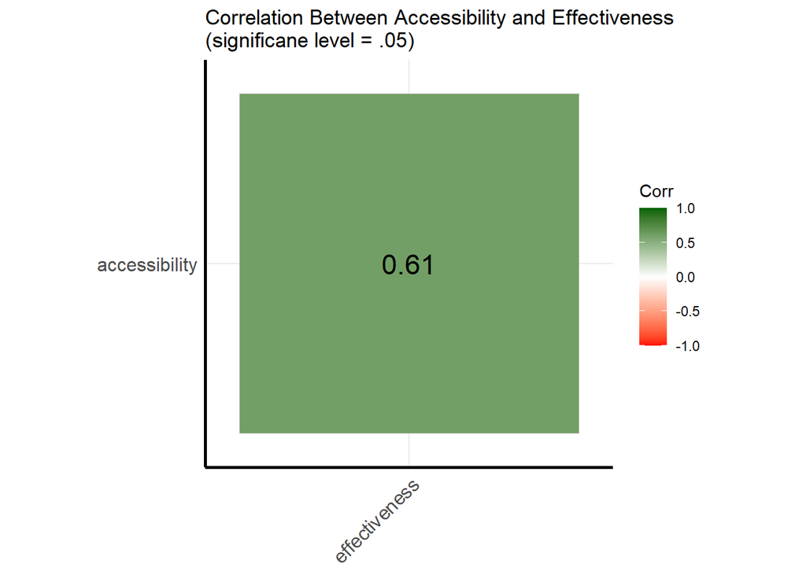

##### Adult Education

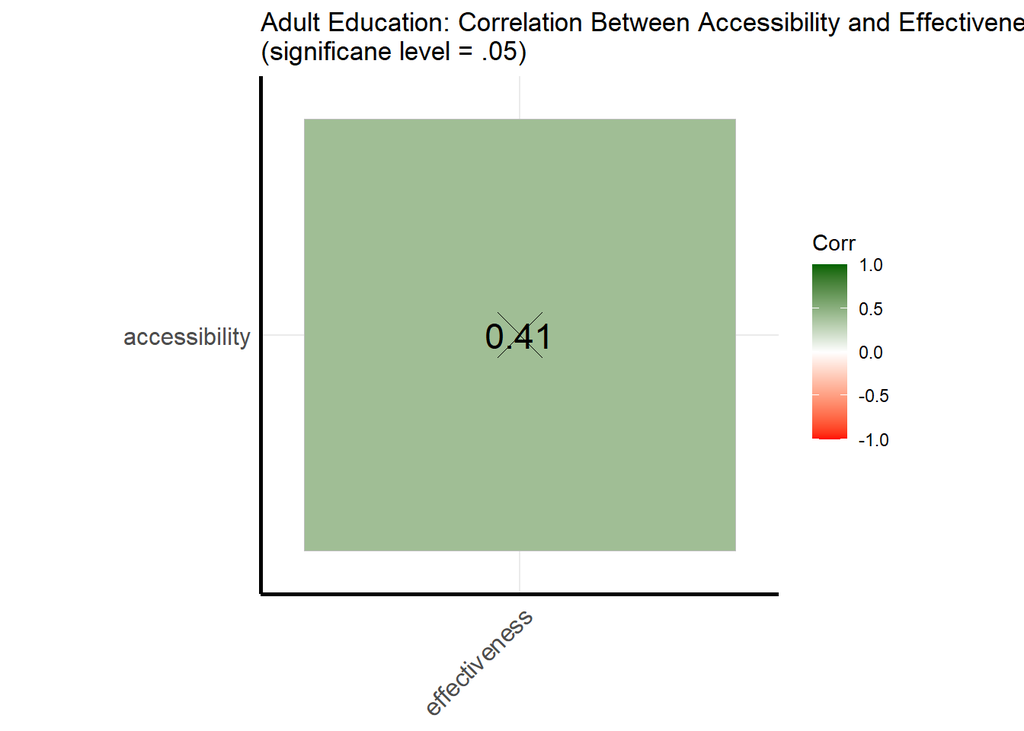

##### Advocacy

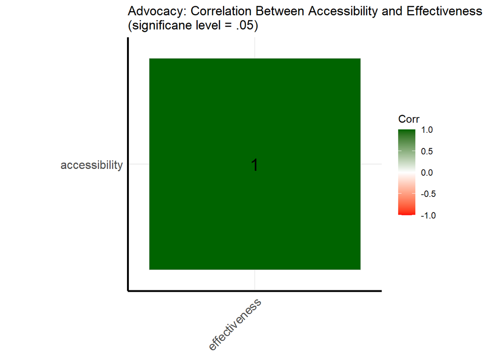

##### Business Assistance

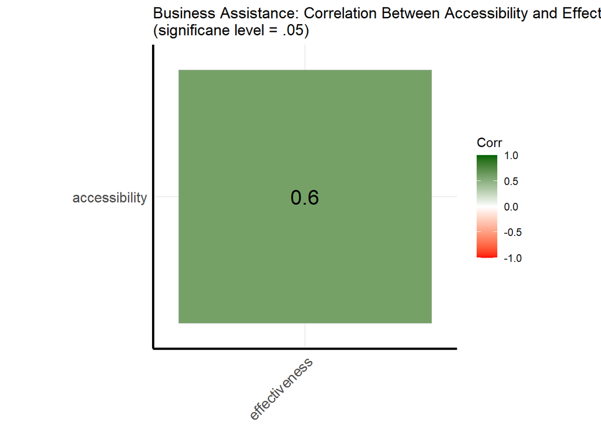

##### Criminal Justice

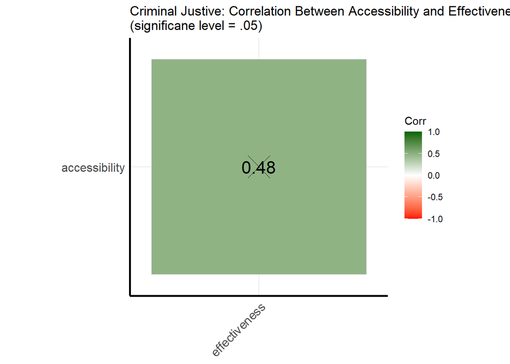

##### Education

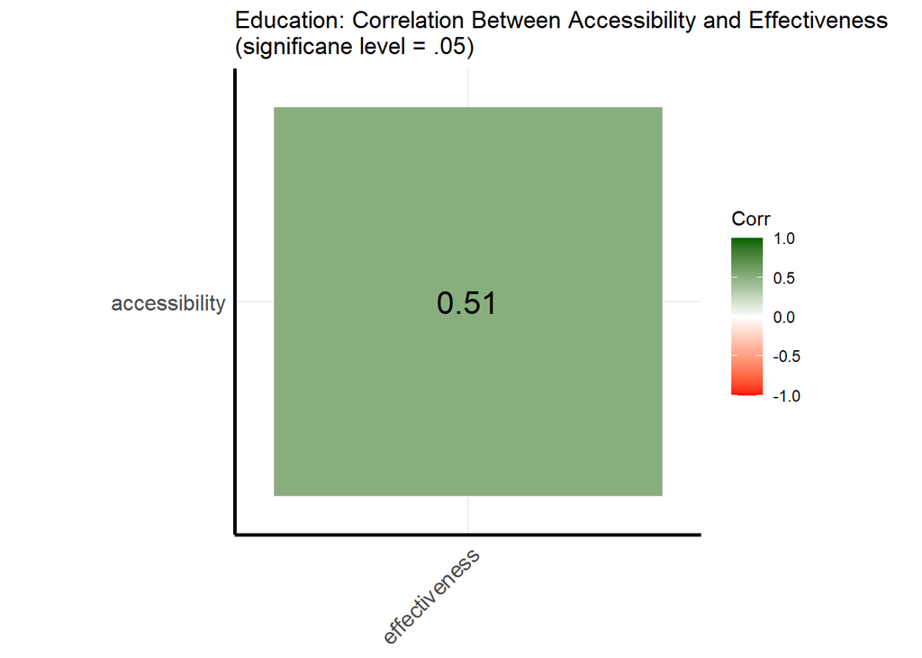

##### Employment Assistance

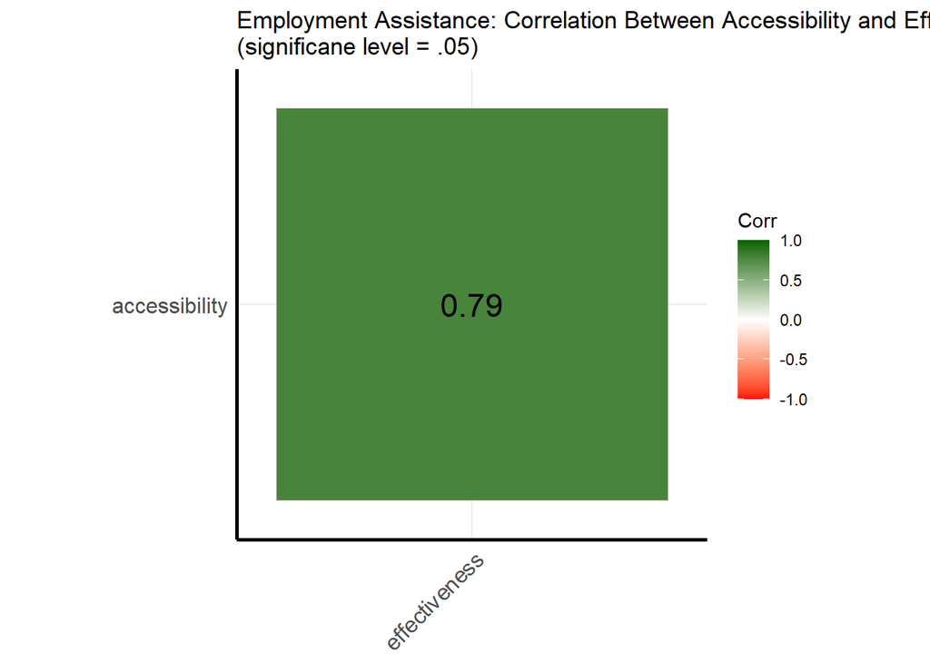

##### Financial Assistance

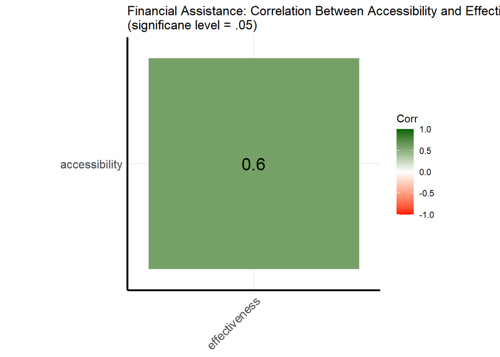

##### Health

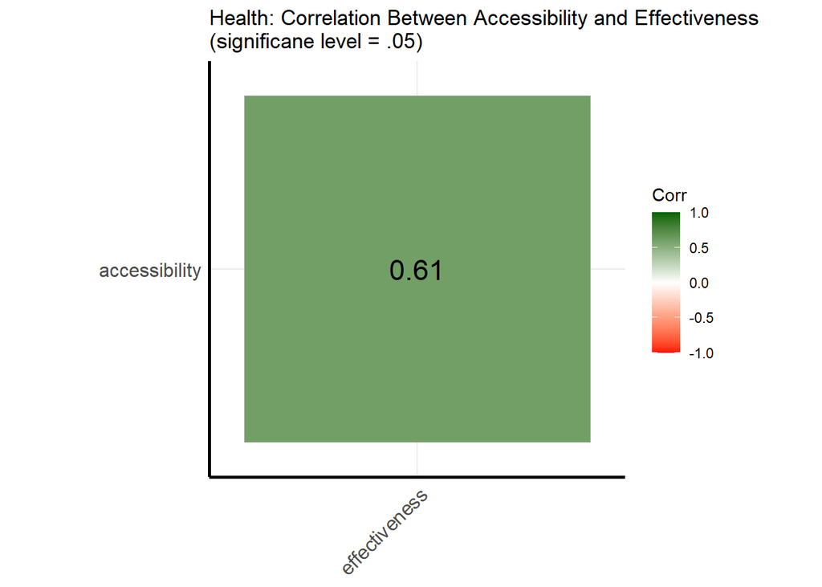

##### Housing Assistance

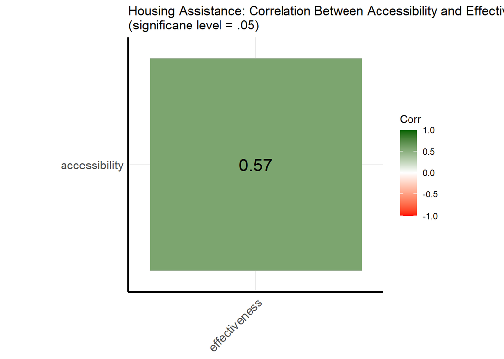

##### Mental Health

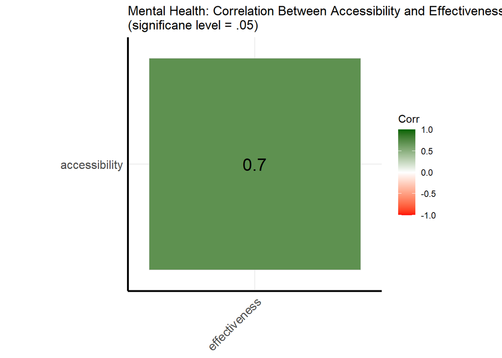

##### Youth Safety

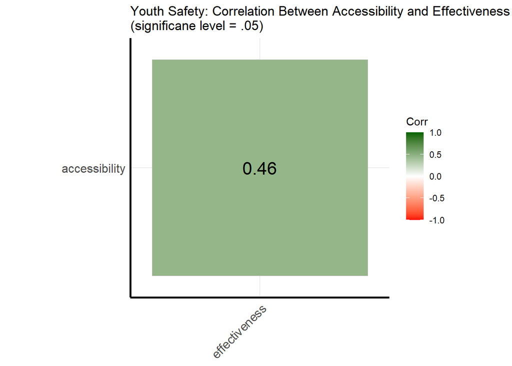

## Existing Services Supporting Communities and Women of Color

#### Org Q7. What are your organization’s primary focus areas?

##### All Organizations

| response | count | perc |
| --- | --- | --- |
| Arts, Culture and Humanities | 6 | 24% |
| Civic and Community | 10 | 40% |
| Civil Rights, Social Action and Advocacy | 12 | 48% |
| Education and Schools | 15 | 60% |
| Environment | 1 | 4% |
| Health | 3 | 12% |
| Human Services | 5 | 20% |
| Legal Services | 2 | 8% |
| Other (Please Specify) | 4 | 16% |
| Public Safety, Disaster Preparedness, and Response | 2 | 8% |
| Recreation, Sports and Leisure | 1 | 4% |
| Youth Development | 15 | 60% |

##### By Organization Type

| org_type | base_size | Arts, Culture and Humanities | Civic and Community | Civil Rights, Social Action and Advocacy | Education and Schools | Environment | Health | Human Services | Legal Services | Other (Please Specify) | Public Safety, Disaster Preparedness, and Response | Recreation, Sports and Leisure | Youth Development |
| --- | --- | --- | --- | --- | --- | --- | --- | --- | --- | --- | --- | --- | --- |
| Charity | 1 | NA | 100% | NA | NA | NA | NA | NA | 100% | NA | 100% | NA | 100% |
| Community-Based | 2 | NA | 50% | 100% | 50% | NA | NA | 50% | NA | NA | NA | NA | 50% |
| Foundation | 4 | 25% | 25% | 50% | 75% | 25% | NA | 25% | NA | 25% | 25% | 25% | 50% |
| Grassroots | 2 | NA | NA | NA | NA | NA | 50% | 50% | NA | 50% | NA | NA | NA |
| Not-for-profit | 15 | 33.33% | 46.67% | 53.33% | 73.33% | NA | 13.33% | 13.33% | 6.67% | 13.33% | NA | NA | 73.33% |

#### Org Q17. How do you determine the kind of support and programs you provide to the community?

##### All Organizations

| response | count | perc |
| --- | --- | --- |
| Analyze public data | 11 | 44% |
| analyze student academic/SEL and teacher obs data | 1 | 4% |
| Check availability of resources/monetary resources (like based on funders/grant requirements?) | 10 | 40% |
| Engaging Community and youth | 18 | 72% |
| Ensuring community is at the heart of our decisionmaking process. | 1 | 4% |
| Make observations | 15 | 60% |
| respond to the insights of the leaders we’re working with about their own communities | 1 | 4% |
| Survey members of the community | 11 | 44% |
| Survey your clients | 13 | 52% |

##### By Organization Type

| org_type | base_size | Analyze public data | analyze student academic/SEL and teacher obs data | Check availability of resources/monetary resources (like based on funders/grant requirements?) | Engaging Community and youth | Ensuring community is at the heart of our decisionmaking process. | Make observations | respond to the insights of the leaders we’re working with about their own communities | Survey members of the community | Survey your clients |
| --- | --- | --- | --- | --- | --- | --- | --- | --- | --- | --- |
| Community-Based | 2 | 50% | NA | NA | 100% | NA | 50% | NA | 50% | 50% |
| Foundation | 4 | 50% | NA | NA | 100% | 25% | 50% | 25% | 75% | 75% |
| Grassroots | 2 | 50% | NA | NA | 50% | NA | 50% | NA | 50% | 50% |
| Not-for-profit | 15 | 46.67% | 6.67% | 66.67% | 73.33% | NA | 73.33% | NA | 40% | 53.33% |

#### Org Q18. Our organization seeks community input when determining future goals and initiatives?

##### By Organization Type

| org_type | base_size | <NA> | Strongly Disagree | Somewhat Agree | Agree | Strongly Agree |
| --- | --- | --- | --- | --- | --- | --- |
| Charity | 1 | NA | NA | NA | NA | 100% |
| Community-Based | 2 | NA | NA | NA | NA | 100% |
| Foundation | 4 | NA | NA | 25% | NA | 75% |
| Grassroots | 2 | NA | 50% | NA | NA | 50% |
| Not-for-profit | 15 | 13.33% | NA | 33.33% | 20% | 33.33% |
| Political Organization | 1 | 100% | NA | NA | NA | NA |

#### Community Q17. In the past 12 months, which of the following issue areas has a community organization engaged you in?

##### All Respondents

###### Total

| response | n | percent |
| --- | --- | --- |
| Census | 66 | 17.1% |
| Affordable Housing | 49 | 12.7% |
| Social Justice | 46 | 11.9% |
| Women's Rights | 44 | 11.4% |
| Healthcare | 43 | 11.1% |
| Voting rights | 38 | 9.8% |
| Criminal Justice | 31 | 8.0% |
| LGBTQ+ Rights | 25 | 6.5% |
| Employment Rights | 23 | 5.9% |
| Immigration Rights | 22 | 5.7% |

###### Race

| race | Affordable Housing | Census | Criminal Justice | Employment Rights | Healthcare | Immigration Rights | LGBTQ+ Rights | Social Justice | Voting rights | Women’s Rights |
| --- | --- | --- | --- | --- | --- | --- | --- | --- | --- | --- |
| 2 or More Race/Ethnicities | 14.9% (11) | 13.5% (10) | 4.1% (3) | 9.5% (7) | 8.1% (6) | 4.1% (3) | 8.1% (6) | 13.5% (10) | 9.5% (7) | 14.9% (11) |
| American Indian or Alaska Native | 0.0% (0) | 0.0% (0) | 0.0% (0) | 0.0% (0) | 0.0% (0) | 0.0% (0) | 0.0% (0) | 100.0% (1) | 0.0% (0) | 0.0% (0) |
| Asian | 50.0% (1) | 0.0% (0) | 0.0% (0) | 0.0% (0) | 50.0% (1) | 0.0% (0) | 0.0% (0) | 0.0% (0) | 0.0% (0) | 0.0% (0) |
| Black or African American | 14.5% (20) | 13.0% (18) | 10.1% (14) | 6.5% (9) | 13.0% (18) | 1.4% (2) | 2.9% (4) | 15.2% (21) | 11.6% (16) | 11.6% (16) |
| Hispanic, Latino, or Spanish origin | 12.1% (11) | 20.9% (19) | 4.4% (4) | 5.5% (5) | 7.7% (7) | 14.3% (13) | 9.9% (9) | 6.6% (6) | 8.8% (8) | 9.9% (9) |
| Prefer not to say | 11.1% (2) | 22.2% (4) | 16.7% (3) | 0.0% (0) | 11.1% (2) | 0.0% (0) | 11.1% (2) | 16.7% (3) | 0.0% (0) | 11.1% (2) |
| White | 6.6% (4) | 24.6% (15) | 9.8% (6) | 3.3% (2) | 14.8% (9) | 4.9% (3) | 6.6% (4) | 8.2% (5) | 11.5% (7) | 9.8% (6) |
| NA | 0.0% (0) | 0.0% (0) | 50.0% (1) | 0.0% (0) | 0.0% (0) | 50.0% (1) | 0.0% (0) | 0.0% (0) | 0.0% (0) | 0.0% (0) |

###### Gender Identity

| gender_identity | Affordable Housing | Census | Criminal Justice | Employment Rights | Healthcare | Immigration Rights | LGBTQ+ Rights | Social Justice | Voting rights | Women’s Rights |
| --- | --- | --- | --- | --- | --- | --- | --- | --- | --- | --- |
| Female | 13.7% (46) | 15.2% (51) | 7.8% (26) | 6.9% (23) | 11.0% (37) | 4.8% (16) | 6.0% (20) | 11.3% (38) | 11.0% (37) | 12.2% (41) |
| Male | 5.7% (2) | 31.4% (11) | 2.9% (1) | 0.0% (0) | 14.3% (5) | 11.4% (4) | 8.6% (3) | 17.1% (6) | 2.9% (1) | 5.7% (2) |
| Prefer not to say | 9.1% (1) | 27.3% (3) | 27.3% (3) | 0.0% (0) | 9.1% (1) | 0.0% (0) | 9.1% (1) | 9.1% (1) | 0.0% (0) | 9.1% (1) |
| Transgender Male | 0.0% (0) | 0.0% (0) | 0.0% (0) | 0.0% (0) | 0.0% (0) | 33.3% (1) | 33.3% (1) | 33.3% (1) | 0.0% (0) | 0.0% (0) |
| NA | 0.0% (0) | 33.3% (1) | 33.3% (1) | 0.0% (0) | 0.0% (0) | 33.3% (1) | 0.0% (0) | 0.0% (0) | 0.0% (0) | 0.0% (0) |

###### Age Band

| age | Affordable Housing | Census | Criminal Justice | Employment Rights | Healthcare | Immigration Rights | LGBTQ+ Rights | Social Justice | Voting rights | Women’s Rights |
| --- | --- | --- | --- | --- | --- | --- | --- | --- | --- | --- |
| 18-24 | 5.9% (2) | 11.8% (4) | 11.8% (4) | 14.7% (5) | 8.8% (3) | 8.8% (3) | 11.8% (4) | 8.8% (3) | 5.9% (2) | 11.8% (4) |
| 25-34 | 13.9% (22) | 15.8% (25) | 7.0% (11) | 5.7% (9) | 11.4% (18) | 5.7% (9) | 7.0% (11) | 12.7% (20) | 8.9% (14) | 12.0% (19) |
| 35-44 | 10.3% (10) | 18.6% (18) | 9.3% (9) | 3.1% (3) | 9.3% (9) | 6.2% (6) | 8.2% (8) | 13.4% (13) | 9.3% (9) | 12.4% (12) |
| 45-54 | 18.2% (12) | 19.7% (13) | 7.6% (5) | 7.6% (5) | 9.1% (6) | 4.5% (3) | 3.0% (2) | 10.6% (7) | 7.6% (5) | 12.1% (8) |
| 55-64 | 5.0% (1) | 25.0% (5) | 5.0% (1) | 0.0% (0) | 25.0% (5) | 0.0% (0) | 0.0% (0) | 15.0% (3) | 20.0% (4) | 5.0% (1) |
| 65+ | 22.2% (2) | 11.1% (1) | 0.0% (0) | 11.1% (1) | 22.2% (2) | 0.0% (0) | 0.0% (0) | 0.0% (0) | 33.3% (3) | 0.0% (0) |
| Under 18 | 0.0% (0) | 0.0% (0) | 0.0% (0) | 0.0% (0) | 0.0% (0) | 0.0% (0) | 0.0% (0) | 0.0% (0) | 100.0% (1) | 0.0% (0) |
| NA | 0.0% (0) | 0.0% (0) | 50.0% (1) | 0.0% (0) | 0.0% (0) | 50.0% (1) | 0.0% (0) | 0.0% (0) | 0.0% (0) | 0.0% (0) |

###### Num of Children

| children_range | Affordable Housing | Census | Criminal Justice | Employment Rights | Healthcare | Immigration Rights | LGBTQ+ Rights | Social Justice | Voting rights | Women’s Rights |
| --- | --- | --- | --- | --- | --- | --- | --- | --- | --- | --- |
| 0 | 5.4% (3) | 17.9% (10) | 7.1% (4) | 7.1% (4) | 14.3% (8) | 5.4% (3) | 10.7% (6) | 10.7% (6) | 12.5% (7) | 8.9% (5) |
| 1-3 | 14.9% (37) | 17.7% (44) | 7.6% (19) | 5.2% (13) | 10.4% (26) | 4.4% (11) | 5.6% (14) | 12.9% (32) | 10.4% (26) | 10.8% (27) |
| 11+ | 25.0% (1) | 25.0% (1) | 0.0% (0) | 0.0% (0) | 25.0% (1) | 0.0% (0) | 0.0% (0) | 25.0% (1) | 0.0% (0) | 0.0% (0) |
| 4-6 | 9.5% (4) | 21.4% (9) | 2.4% (1) | 7.1% (3) | 11.9% (5) | 14.3% (6) | 2.4% (1) | 7.1% (3) | 7.1% (3) | 16.7% (7) |
| 7-10 | 14.3% (2) | 0.0% (0) | 21.4% (3) | 7.1% (1) | 7.1% (1) | 0.0% (0) | 14.3% (2) | 14.3% (2) | 7.1% (1) | 14.3% (2) |
| NA | 9.1% (2) | 9.1% (2) | 18.2% (4) | 9.1% (2) | 9.1% (2) | 9.1% (2) | 9.1% (2) | 9.1% (2) | 4.5% (1) | 13.6% (3) |

###### Is Children’s Caretaker

| childrens_caretaker | Affordable Housing | Census | Criminal Justice | Employment Rights | Healthcare | Immigration Rights | LGBTQ+ Rights | Social Justice | Voting rights | Women’s Rights |
| --- | --- | --- | --- | --- | --- | --- | --- | --- | --- | --- |
| No | 9.0% (8) | 19.1% (17) | 7.9% (7) | 5.6% (5) | 11.2% (10) | 5.6% (5) | 9.0% (8) | 12.4% (11) | 11.2% (10) | 9.0% (8) |
| Yes | 13.9% (41) | 16.6% (49) | 7.8% (23) | 6.1% (18) | 11.2% (33) | 5.4% (16) | 5.4% (16) | 11.9% (35) | 9.5% (28) | 12.2% (36) |
| NA | 0.0% (0) | 0.0% (0) | 33.3% (1) | 0.0% (0) | 0.0% (0) | 33.3% (1) | 33.3% (1) | 0.0% (0) | 0.0% (0) | 0.0% (0) |

###### Marital Status

| marital_status | Affordable Housing | Census | Criminal Justice | Employment Rights | Healthcare | Immigration Rights | LGBTQ+ Rights | Social Justice | Voting rights | Women’s Rights |
| --- | --- | --- | --- | --- | --- | --- | --- | --- | --- | --- |
| Divorced | 14.5% (9) | 19.4% (12) | 9.7% (6) | 6.5% (4) | 12.9% (8) | 3.2% (2) | 1.6% (1) | 11.3% (7) | 11.3% (7) | 9.7% (6) |
| Married or domestic partnership | 12.5% (20) | 18.8% (30) | 6.9% (11) | 4.4% (7) | 10.6% (17) | 8.8% (14) | 9.4% (15) | 10.0% (16) | 8.8% (14) | 10.0% (16) |
| Separated | 0.0% (0) | 0.0% (0) | 0.0% (0) | 0.0% (0) | 0.0% (0) | 0.0% (0) | 25.0% (1) | 50.0% (2) | 25.0% (1) | 0.0% (0) |
| Single, never married | 12.6% (18) | 15.4% (22) | 8.4% (12) | 7.0% (10) | 11.2% (16) | 3.5% (5) | 5.6% (8) | 12.6% (18) | 9.8% (14) | 14.0% (20) |
| Widowed | 12.5% (2) | 12.5% (2) | 6.2% (1) | 12.5% (2) | 12.5% (2) | 0.0% (0) | 0.0% (0) | 18.8% (3) | 12.5% (2) | 12.5% (2) |
| NA | 0.0% (0) | 0.0% (0) | 50.0% (1) | 0.0% (0) | 0.0% (0) | 50.0% (1) | 0.0% (0) | 0.0% (0) | 0.0% (0) | 0.0% (0) |

###### Education Level

| edu_level | Affordable Housing | Census | Criminal Justice | Employment Rights | Healthcare | Immigration Rights | LGBTQ+ Rights | Social Justice | Voting rights | Women’s Rights |
| --- | --- | --- | --- | --- | --- | --- | --- | --- | --- | --- |
| Associate degree | 16.7% (6) | 5.6% (2) | 5.6% (2) | 11.1% (4) | 11.1% (4) | 2.8% (1) | 11.1% (4) | 8.3% (3) | 13.9% (5) | 13.9% (5) |
| Bachelor’s degree | 9.2% (6) | 10.8% (7) | 10.8% (7) | 7.7% (5) | 12.3% (8) | 6.2% (4) | 6.2% (4) | 10.8% (7) | 13.8% (9) | 12.3% (8) |
| HS Grad or Eq | 10.8% (7) | 23.1% (15) | 4.6% (3) | 10.8% (7) | 7.7% (5) | 6.2% (4) | 9.2% (6) | 6.2% (4) | 6.2% (4) | 15.4% (10) |
| Master’s degree | 12.5% (2) | 25.0% (4) | 12.5% (2) | 0.0% (0) | 6.2% (1) | 6.2% (1) | 0.0% (0) | 18.8% (3) | 12.5% (2) | 6.2% (1) |
| No schooling completed | 11.1% (1) | 22.2% (2) | 11.1% (1) | 11.1% (1) | 11.1% (1) | 11.1% (1) | 0.0% (0) | 0.0% (0) | 11.1% (1) | 11.1% (1) |
| Professional degree | 0.0% (0) | 0.0% (0) | 0.0% (0) | 0.0% (0) | 0.0% (0) | 0.0% (0) | 0.0% (0) | 66.7% (2) | 33.3% (1) | 0.0% (0) |
| Some college credit, no degree | 11.9% (14) | 18.6% (22) | 8.5% (10) | 2.5% (3) | 11.0% (13) | 6.8% (8) | 5.9% (7) | 15.3% (18) | 11.0% (13) | 8.5% (10) |
| Some high school, no diploma | 15.8% (3) | 26.3% (5) | 5.3% (1) | 5.3% (1) | 5.3% (1) | 10.5% (2) | 10.5% (2) | 5.3% (1) | 0.0% (0) | 15.8% (3) |
| Trade/technical/vocational training | 18.5% (10) | 16.7% (9) | 7.4% (4) | 3.7% (2) | 18.5% (10) | 0.0% (0) | 3.7% (2) | 14.8% (8) | 5.6% (3) | 11.1% (6) |
| NA | 0.0% (0) | 0.0% (0) | 50.0% (1) | 0.0% (0) | 0.0% (0) | 50.0% (1) | 0.0% (0) | 0.0% (0) | 0.0% (0) | 0.0% (0) |

###### Household Income

| household_income | Affordable Housing | Census | Criminal Justice | Employment Rights | Healthcare | Immigration Rights | LGBTQ+ Rights | Social Justice | Voting rights | Women’s Rights |
| --- | --- | --- | --- | --- | --- | --- | --- | --- | --- | --- |
| Between $100,000 and $150,000 | 0.0% (0) | 0.0% (0) | 0.0% (0) | 0.0% (0) | 16.7% (1) | 16.7% (1) | 16.7% (1) | 16.7% (1) | 16.7% (1) | 16.7% (1) |
| Between $15,000 and $29,999 | 18.2% (12) | 18.2% (12) | 6.1% (4) | 4.5% (3) | 12.1% (8) | 4.5% (3) | 6.1% (4) | 10.6% (7) | 9.1% (6) | 10.6% (7) |
| Between $30,000 and $49,999 | 12.5% (17) | 16.9% (23) | 9.6% (13) | 4.4% (6) | 12.5% (17) | 5.9% (8) | 5.9% (8) | 11.8% (16) | 9.6% (13) | 11.0% (15) |
| Between $50,000 and $74,999 | 16.7% (5) | 30.0% (9) | 6.7% (2) | 3.3% (1) | 3.3% (1) | 6.7% (2) | 3.3% (1) | 10.0% (3) | 16.7% (5) | 3.3% (1) |
| Between $75,000 and $99,999 | 0.0% (0) | 6.2% (1) | 12.5% (2) | 6.2% (1) | 12.5% (2) | 12.5% (2) | 12.5% (2) | 12.5% (2) | 12.5% (2) | 12.5% (2) |
| Under $15,000 | 11.7% (15) | 15.6% (20) | 7.0% (9) | 9.4% (12) | 10.9% (14) | 3.9% (5) | 6.2% (8) | 13.3% (17) | 8.6% (11) | 13.3% (17) |
| NA | 0.0% (0) | 20.0% (1) | 20.0% (1) | 0.0% (0) | 0.0% (0) | 20.0% (1) | 20.0% (1) | 0.0% (0) | 0.0% (0) | 20.0% (1) |

###### City

| city | Affordable Housing | Census | Criminal Justice | Employment Rights | Healthcare | Immigration Rights | LGBTQ+ Rights | Social Justice | Voting rights | Women’s Rights |
| --- | --- | --- | --- | --- | --- | --- | --- | --- | --- | --- |
| Arvada | 0.0% (0) | 50.0% (1) | 0.0% (0) | 0.0% (0) | 0.0% (0) | 0.0% (0) | 0.0% (0) | 0.0% (0) | 50.0% (1) | 0.0% (0) |
| Aurora | 15.5% (23) | 15.5% (23) | 4.1% (6) | 6.1% (9) | 8.1% (12) | 7.4% (11) | 8.1% (12) | 11.5% (17) | 12.2% (18) | 11.5% (17) |
| Berkley | 0.0% (0) | 0.0% (0) | 0.0% (0) | 0.0% (0) | 0.0% (0) | 100.0% (1) | 0.0% (0) | 0.0% (0) | 0.0% (0) | 0.0% (0) |
| Brighton | 0.0% (0) | 100.0% (1) | 0.0% (0) | 0.0% (0) | 0.0% (0) | 0.0% (0) | 0.0% (0) | 0.0% (0) | 0.0% (0) | 0.0% (0) |
| Broomfield | 0.0% (0) | 100.0% (1) | 0.0% (0) | 0.0% (0) | 0.0% (0) | 0.0% (0) | 0.0% (0) | 0.0% (0) | 0.0% (0) | 0.0% (0) |
| Commerce City | 16.7% (1) | 0.0% (0) | 16.7% (1) | 16.7% (1) | 0.0% (0) | 16.7% (1) | 0.0% (0) | 0.0% (0) | 16.7% (1) | 16.7% (1) |
| Denver | 10.7% (23) | 18.1% (39) | 9.3% (20) | 5.6% (12) | 13.5% (29) | 3.7% (8) | 5.6% (12) | 13.5% (29) | 8.4% (18) | 11.6% (25) |
| Lakewood | 33.3% (1) | 0.0% (0) | 33.3% (1) | 0.0% (0) | 33.3% (1) | 0.0% (0) | 0.0% (0) | 0.0% (0) | 0.0% (0) | 0.0% (0) |
| Thornton | 50.0% (1) | 0.0% (0) | 50.0% (1) | 0.0% (0) | 0.0% (0) | 0.0% (0) | 0.0% (0) | 0.0% (0) | 0.0% (0) | 0.0% (0) |
| NA | 0.0% (0) | 12.5% (1) | 25.0% (2) | 12.5% (1) | 12.5% (1) | 12.5% (1) | 12.5% (1) | 0.0% (0) | 0.0% (0) | 12.5% (1) |

##### Women of Color Respondents

###### Total

| response | n | percent |
| --- | --- | --- |
| Affordable Housing | 42 | 15.0% |
| Census | 38 | 13.6% |
| Women's Rights | 35 | 12.5% |
| Social Justice | 33 | 11.8% |
| Voting rights | 31 | 11.1% |
| Healthcare | 28 | 10.0% |
| Criminal Justice | 21 | 7.5% |
| Employment Rights | 21 | 7.5% |
| LGBTQ+ Rights | 17 | 6.1% |
| Immigration Rights | 14 | 5.0% |

###### Race

| race | Affordable Housing | Census | Criminal Justice | Employment Rights | Healthcare | Immigration Rights | LGBTQ+ Rights | Social Justice | Voting rights | Women’s Rights |
| --- | --- | --- | --- | --- | --- | --- | --- | --- | --- | --- |
| 2 or More Race/Ethnicities | 16.4% (11) | 11.9% (8) | 4.5% (3) | 10.4% (7) | 7.5% (5) | 3.0% (2) | 9.0% (6) | 11.9% (8) | 10.4% (7) | 14.9% (10) |
| Asian | 50.0% (1) | 0.0% (0) | 0.0% (0) | 0.0% (0) | 50.0% (1) | 0.0% (0) | 0.0% (0) | 0.0% (0) | 0.0% (0) | 0.0% (0) |
| Black or African American | 14.7% (20) | 11.8% (16) | 10.3% (14) | 6.6% (9) | 13.2% (18) | 1.5% (2) | 2.9% (4) | 15.4% (21) | 11.8% (16) | 11.8% (16) |
| Hispanic, Latino, or Spanish origin | 13.3% (10) | 18.7% (14) | 5.3% (4) | 6.7% (5) | 5.3% (4) | 13.3% (10) | 9.3% (7) | 5.3% (4) | 10.7% (8) | 12.0% (9) |

###### Age Band

| age | Affordable Housing | Census | Criminal Justice | Employment Rights | Healthcare | Immigration Rights | LGBTQ+ Rights | Social Justice | Voting rights | Women’s Rights |
| --- | --- | --- | --- | --- | --- | --- | --- | --- | --- | --- |
| 18-24 | 0.0% (0) | 14.3% (3) | 9.5% (2) | 19.0% (4) | 4.8% (1) | 9.5% (2) | 9.5% (2) | 9.5% (2) | 9.5% (2) | 14.3% (3) |
| 25-34 | 16.8% (18) | 12.1% (13) | 7.5% (8) | 8.4% (9) | 11.2% (12) | 3.7% (4) | 4.7% (5) | 13.1% (14) | 9.3% (10) | 13.1% (14) |
| 35-44 | 13.7% (10) | 12.3% (9) | 8.2% (6) | 2.7% (2) | 8.2% (6) | 6.8% (5) | 11.0% (8) | 12.3% (9) | 11.0% (8) | 13.7% (10) |
| 45-54 | 19.6% (11) | 14.3% (8) | 8.9% (5) | 8.9% (5) | 8.9% (5) | 5.4% (3) | 3.6% (2) | 10.7% (6) | 7.1% (4) | 12.5% (7) |
| 55-64 | 6.7% (1) | 26.7% (4) | 0.0% (0) | 0.0% (0) | 20.0% (3) | 0.0% (0) | 0.0% (0) | 13.3% (2) | 26.7% (4) | 6.7% (1) |
| 65+ | 28.6% (2) | 14.3% (1) | 0.0% (0) | 14.3% (1) | 14.3% (1) | 0.0% (0) | 0.0% (0) | 0.0% (0) | 28.6% (2) | 0.0% (0) |
| Under 18 | 0.0% (0) | 0.0% (0) | 0.0% (0) | 0.0% (0) | 0.0% (0) | 0.0% (0) | 0.0% (0) | 0.0% (0) | 100.0% (1) | 0.0% (0) |

###### Num of Children

| children_range | Affordable Housing | Census | Criminal Justice | Employment Rights | Healthcare | Immigration Rights | LGBTQ+ Rights | Social Justice | Voting rights | Women’s Rights |
| --- | --- | --- | --- | --- | --- | --- | --- | --- | --- | --- |
| 0 | 8.1% (3) | 18.9% (7) | 5.4% (2) | 8.1% (3) | 13.5% (5) | 5.4% (2) | 8.1% (3) | 8.1% (3) | 16.2% (6) | 8.1% (3) |
| 1-3 | 16.8% (32) | 12.6% (24) | 7.4% (14) | 6.8% (13) | 8.9% (17) | 4.2% (8) | 5.8% (11) | 13.7% (26) | 11.1% (21) | 12.6% (24) |
| 11+ | 100.0% (1) | 0.0% (0) | 0.0% (0) | 0.0% (0) | 0.0% (0) | 0.0% (0) | 0.0% (0) | 0.0% (0) | 0.0% (0) | 0.0% (0) |
| 4-6 | 11.1% (3) | 22.2% (6) | 3.7% (1) | 7.4% (2) | 14.8% (4) | 11.1% (3) | 0.0% (0) | 3.7% (1) | 7.4% (2) | 18.5% (5) |
| 7-10 | 11.1% (1) | 0.0% (0) | 22.2% (2) | 11.1% (1) | 0.0% (0) | 0.0% (0) | 11.1% (1) | 22.2% (2) | 11.1% (1) | 11.1% (1) |
| NA | 12.5% (2) | 6.2% (1) | 12.5% (2) | 12.5% (2) | 12.5% (2) | 6.2% (1) | 12.5% (2) | 6.2% (1) | 6.2% (1) | 12.5% (2) |

###### Is Children’s Caretaker

| childrens_caretaker | Affordable Housing | Census | Criminal Justice | Employment Rights | Healthcare | Immigration Rights | LGBTQ+ Rights | Social Justice | Voting rights | Women’s Rights |
| --- | --- | --- | --- | --- | --- | --- | --- | --- | --- | --- |
| No | 12.7% (8) | 20.6% (13) | 6.3% (4) | 6.3% (4) | 11.1% (7) | 4.8% (3) | 7.9% (5) | 9.5% (6) | 14.3% (9) | 6.3% (4) |
| Yes | 15.7% (34) | 11.6% (25) | 7.9% (17) | 7.9% (17) | 9.7% (21) | 5.1% (11) | 5.1% (11) | 12.5% (27) | 10.2% (22) | 14.4% (31) |
| NA | 0.0% (0) | 0.0% (0) | 0.0% (0) | 0.0% (0) | 0.0% (0) | 0.0% (0) | 100.0% (1) | 0.0% (0) | 0.0% (0) | 0.0% (0) |

###### Marital Status

| marital_status | Affordable Housing | Census | Criminal Justice | Employment Rights | Healthcare | Immigration Rights | LGBTQ+ Rights | Social Justice | Voting rights | Women’s Rights |
| --- | --- | --- | --- | --- | --- | --- | --- | --- | --- | --- |
| Divorced | 17.3% (9) | 17.3% (9) | 11.5% (6) | 7.7% (4) | 13.5% (7) | 1.9% (1) | 1.9% (1) | 11.5% (6) | 9.6% (5) | 7.7% (4) |
| Married or domestic partnership | 14.0% (15) | 13.1% (14) | 6.5% (7) | 6.5% (7) | 8.4% (9) | 8.4% (9) | 9.3% (10) | 11.2% (12) | 10.3% (11) | 12.1% (13) |
| Separated | 0.0% (0) | 0.0% (0) | 0.0% (0) | 0.0% (0) | 0.0% (0) | 0.0% (0) | 25.0% (1) | 50.0% (2) | 25.0% (1) | 0.0% (0) |
| Single, never married | 15.1% (16) | 13.2% (14) | 7.5% (8) | 7.5% (8) | 11.3% (12) | 3.8% (4) | 4.7% (5) | 10.4% (11) | 11.3% (12) | 15.1% (16) |
| Widowed | 18.2% (2) | 9.1% (1) | 0.0% (0) | 18.2% (2) | 0.0% (0) | 0.0% (0) | 0.0% (0) | 18.2% (2) | 18.2% (2) | 18.2% (2) |

###### Education Level

| edu_level | Affordable Housing | Census | Criminal Justice | Employment Rights | Healthcare | Immigration Rights | LGBTQ+ Rights | Social Justice | Voting rights | Women’s Rights |
| --- | --- | --- | --- | --- | --- | --- | --- | --- | --- | --- |
| Associate degree | 20.0% (6) | 6.7% (2) | 6.7% (2) | 13.3% (4) | 10.0% (3) | 0.0% (0) | 10.0% (3) | 6.7% (2) | 13.3% (4) | 13.3% (4) |
| Bachelor’s degree | 9.1% (5) | 12.7% (7) | 9.1% (5) | 9.1% (5) | 10.9% (6) | 7.3% (4) | 7.3% (4) | 10.9% (6) | 10.9% (6) | 12.7% (7) |
| HS Grad or Eq | 13.3% (6) | 17.8% (8) | 4.4% (2) | 15.6% (7) | 6.7% (3) | 6.7% (3) | 6.7% (3) | 6.7% (3) | 8.9% (4) | 13.3% (6) |
| Master’s degree | 11.1% (1) | 22.2% (2) | 11.1% (1) | 0.0% (0) | 11.1% (1) | 0.0% (0) | 0.0% (0) | 22.2% (2) | 11.1% (1) | 11.1% (1) |
| No schooling completed | 12.5% (1) | 12.5% (1) | 12.5% (1) | 12.5% (1) | 12.5% (1) | 12.5% (1) | 0.0% (0) | 0.0% (0) | 12.5% (1) | 12.5% (1) |
| Professional degree | 0.0% (0) | 0.0% (0) | 0.0% (0) | 0.0% (0) | 0.0% (0) | 0.0% (0) | 0.0% (0) | 66.7% (2) | 33.3% (1) | 0.0% (0) |
| Some college credit, no degree | 14.3% (11) | 16.9% (13) | 9.1% (7) | 2.6% (2) | 6.5% (5) | 5.2% (4) | 3.9% (3) | 16.9% (13) | 14.3% (11) | 10.4% (8) |
| Some high school, no diploma | 21.4% (3) | 7.1% (1) | 7.1% (1) | 0.0% (0) | 7.1% (1) | 14.3% (2) | 14.3% (2) | 7.1% (1) | 0.0% (0) | 21.4% (3) |
| Trade/technical/vocational training | 23.1% (9) | 10.3% (4) | 5.1% (2) | 5.1% (2) | 20.5% (8) | 0.0% (0) | 5.1% (2) | 10.3% (4) | 7.7% (3) | 12.8% (5) |

###### Household Income

| household_income | Affordable Housing | Census | Criminal Justice | Employment Rights | Healthcare | Immigration Rights | LGBTQ+ Rights | Social Justice | Voting rights | Women’s Rights |
| --- | --- | --- | --- | --- | --- | --- | --- | --- | --- | --- |
| Between $15,000 and $29,999 | 22.4% (11) | 16.3% (8) | 4.1% (2) | 4.1% (2) | 12.2% (6) | 6.1% (3) | 4.1% (2) | 12.2% (6) | 8.2% (4) | 10.2% (5) |
| Between $30,000 and $49,999 | 14.9% (14) | 12.8% (12) | 8.5% (8) | 6.4% (6) | 10.6% (10) | 5.3% (5) | 5.3% (5) | 11.7% (11) | 11.7% (11) | 12.8% (12) |
| Between $50,000 and $74,999 | 17.4% (4) | 26.1% (6) | 8.7% (2) | 4.3% (1) | 4.3% (1) | 4.3% (1) | 0.0% (0) | 13.0% (3) | 17.4% (4) | 4.3% (1) |
| Between $75,000 and $99,999 | 0.0% (0) | 6.2% (1) | 12.5% (2) | 6.2% (1) | 12.5% (2) | 12.5% (2) | 12.5% (2) | 12.5% (2) | 12.5% (2) | 12.5% (2) |
| Under $15,000 | 13.7% (13) | 10.5% (10) | 7.4% (7) | 11.6% (11) | 9.5% (9) | 3.2% (3) | 7.4% (7) | 11.6% (11) | 10.5% (10) | 14.7% (14) |
| NA | 0.0% (0) | 33.3% (1) | 0.0% (0) | 0.0% (0) | 0.0% (0) | 0.0% (0) | 33.3% (1) | 0.0% (0) | 0.0% (0) | 33.3% (1) |

###### City

| city | Affordable Housing | Census | Criminal Justice | Employment Rights | Healthcare | Immigration Rights | LGBTQ+ Rights | Social Justice | Voting rights | Women’s Rights |
| --- | --- | --- | --- | --- | --- | --- | --- | --- | --- | --- |
| Aurora | 17.9% (20) | 13.4% (15) | 3.6% (4) | 8.0% (9) | 6.2% (7) | 6.2% (7) | 7.1% (8) | 11.6% (13) | 13.4% (15) | 12.5% (14) |
| Berkley | 0.0% (0) | 0.0% (0) | 0.0% (0) | 0.0% (0) | 0.0% (0) | 100.0% (1) | 0.0% (0) | 0.0% (0) | 0.0% (0) | 0.0% (0) |
| Commerce City | 16.7% (1) | 0.0% (0) | 16.7% (1) | 16.7% (1) | 0.0% (0) | 16.7% (1) | 0.0% (0) | 0.0% (0) | 16.7% (1) | 16.7% (1) |
| Denver | 12.5% (20) | 14.4% (23) | 10.0% (16) | 6.9% (11) | 13.1% (21) | 3.1% (5) | 5.6% (9) | 12.5% (20) | 9.4% (15) | 12.5% (20) |
| Thornton | 100.0% (1) | 0.0% (0) | 0.0% (0) | 0.0% (0) | 0.0% (0) | 0.0% (0) | 0.0% (0) | 0.0% (0) | 0.0% (0) | 0.0% (0) |

#### Community Q18. In the past 12 months, which of the following activities have you done?

##### All Respondents

###### Total

| response | count | perc |
| --- | --- | --- |
| Completed the 2020 Census | 121 | 63.68% |
| Protested | 42 | 22.11% |
| Signed a Petition | 88 | 46.32% |
| Voted | 70 | 36.84% |
| Wrote or Called a Government Official | 22 | 11.58% |

###### Race

| race | base_size | Completed the 2020 Census | Protested | Signed a Petition | Voted | Wrote or Called a Government Official |
| --- | --- | --- | --- | --- | --- | --- |
| 2 or More Race/Ethnicities | 31 | 74.19 % | 25.81 % | 67.74 % | 48.39 % | 12.9 % |
| American Indian or Alaska Native | 1 | 100 % | 100 % | 100 % | 100 % | NA |
| Asian | 1 | 100 % | NA | NA | NA | NA |
| Black or African American | 61 | 68.85 % | 29.51 % | 52.46 % | 50.82 % | 14.75 % |
| Hispanic, Latino, or Spanish origin | 39 | 84.62 % | 17.95 % | 38.46 % | 25.64 % | 5.13 % |
| Prefer not to say | 10 | 50 % | 40 % | 70 % | 20 % | NA |
| White | 23 | 69.57 % | 13.04 % | 52.17 % | 47.83 % | 30.43 % |
| NA | 24 | NA | 4.17 % | NA | NA | NA |

###### Gender Identity

| gender_identity | base_size | Completed the 2020 Census | Protested | Signed a Petition | Voted | Wrote or Called a Government Official |
| --- | --- | --- | --- | --- | --- | --- |
| Female | 142 | 73.24 % | 23.94 % | 53.52 % | 45.07 % | 13.38 % |
| Male | 17 | 76.47 % | 17.65 % | 47.06 % | 29.41 % | 11.76 % |
| Prefer not to say | 5 | 40 % | 40 % | 80 % | 20 % | NA |
| Transgender Male | 1 | 100 % | 100 % | NA | NA | 100 % |
| NA | 25 | 4 % | 8 % | NA | NA | NA |

###### Age Band

| age | base_size | Completed the 2020 Census | Protested | Signed a Petition | Voted | Wrote or Called a Government Official |
| --- | --- | --- | --- | --- | --- | --- |
| 18-24 | 12 | 66.67 % | 50 % | 41.67 % | 41.67 % | 16.67 % |
| 25-34 | 63 | 73.02 % | 25.4 % | 61.9 % | 33.33 % | 12.7 % |
| 35-44 | 48 | 68.75 % | 27.08 % | 39.58 % | 37.5 % | 10.42 % |
| 45-54 | 26 | 80.77 % | 15.38 % | 53.85 % | 50 % | 15.38 % |
| 55-64 | 11 | 63.64 % | 9.09 % | 63.64 % | 81.82 % | 18.18 % |
| 65+ | 5 | 100 % | 20 % | 80 % | 80 % | 20 % |
| Under 18 | 1 | 100 % | NA | NA | NA | NA |
| NA | 24 | NA | 4.17 % | NA | NA | NA |

###### Num of Children

| children_range | base_size | Completed the 2020 Census | Protested | Signed a Petition | Voted | Wrote or Called a Government Official |
| --- | --- | --- | --- | --- | --- | --- |
| 0 | 21 | 80.95 % | 42.86 % | 42.86 % | 52.38 % | 14.29 % |
| 1-3 | 111 | 72.97 % | 21.62 % | 55.86 % | 45.05 % | 16.22 % |
| 11+ | 2 | NA | NA | 100 % | NA | NA |
| 4-6 | 21 | 76.19 % | 9.52 % | 38.1 % | 23.81 % | NA |
| 7-10 | 4 | 50 % | 100 % | 75 % | 25 % | NA |
| NA | 31 | 16.13 % | 9.68 % | 12.9 % | 9.68 % | 3.23 % |

###### Is Children’s Caretaker

| childrens_caretaker | base_size | Completed the 2020 Census | Protested | Signed a Petition | Voted | Wrote or Called a Government Official |
| --- | --- | --- | --- | --- | --- | --- |
| No | 34 | 67.65 % | 32.35 % | 55.88 % | 41.18 % | 20.59 % |
| Yes | 131 | 74.05 % | 22.9 % | 52.67 % | 41.98 % | 11.45 % |
| NA | 25 | 4 % | 4 % | NA | 4 % | NA |

###### Marital Status

| marital_status | base_size | Completed the 2020 Census | Protested | Signed a Petition | Voted | Wrote or Called a Government Official |
| --- | --- | --- | --- | --- | --- | --- |
| Divorced | 25 | 68 % | 12 % | 68 % | 64 % | 24 % |
| Married or domestic partnership | 63 | 76.19 % | 20.63 % | 53.97 % | 33.33 % | 12.7 % |
| Separated | 3 | 33.33 % | NA | 100 % | 33.33 % | 33.33 % |
| Single, never married | 68 | 72.06 % | 33.82 % | 45.59 % | 38.24 % | 8.82 % |
| Widowed | 7 | 85.71 % | 28.57 % | 42.86 % | 85.71 % | 14.29 % |
| NA | 24 | NA | 4.17 % | NA | NA | NA |

###### Education Level

| edu_level | base_size | Completed the 2020 Census | Protested | Signed a Petition | Voted | Wrote or Called a Government Official |
| --- | --- | --- | --- | --- | --- | --- |
| Associate degree | 12 | 83.33 % | 33.33 % | 75 % | 66.67 % | 25 % |
| Bachelor’s degree | 19 | 73.68 % | 42.11 % | 52.63 % | 68.42 % | 21.05 % |
| HS Grad or Eq | 35 | 74.29 % | 14.29 % | 45.71 % | 22.86 % | 5.71 % |
| Master’s degree | 6 | 66.67 % | 33.33 % | 100 % | 83.33 % | 16.67 % |
| No schooling completed | 4 | 75 % | 25 % | NA | NA | NA |
| Professional degree | 2 | NA | NA | 50 % | 50 % | NA |
| Some college credit, no degree | 57 | 75.44 % | 26.32 % | 52.63 % | 50.88 % | 19.3 % |
| Some high school, no diploma | 11 | 81.82 % | 18.18 % | 18.18 % | 9.09 % | NA |
| Trade/technical/vocational training | 20 | 60 % | 20 % | 70 % | 25 % | 5 % |
| NA | 24 | NA | 4.17 % | NA | NA | NA |

###### Household Income

| household_income | base_size | Completed the 2020 Census | Protested | Signed a Petition | Voted | Wrote or Called a Government Official |
| --- | --- | --- | --- | --- | --- | --- |
| Between $100,000 and $150,000 | 1 | 100 % | NA | 100 % | 100 % | NA |
| Between $15,000 and $29,999 | 37 | 78.38 % | 21.62 % | 56.76 % | 43.24 % | 8.11 % |
| Between $30,000 and $49,999 | 50 | 70 % | 24 % | 64 % | 50 % | 20 % |
| Between $50,000 and $74,999 | 13 | 76.92 % | 30.77 % | 61.54 % | 61.54 % | 23.08 % |
| Between $75,000 and $99,999 | 3 | 100 % | 66.67 % | 33.33 % | 66.67 % | NA |
| Under $15,000 | 60 | 68.33 % | 23.33 % | 40 % | 30 % | 10 % |
| NA | 26 | 7.69 % | 7.69 % | 3.85 % | NA | NA |

###### City

| city | base_size | Completed the 2020 Census | Protested | Signed a Petition | Voted | Wrote or Called a Government Official |
| --- | --- | --- | --- | --- | --- | --- |
| Arvada | 1 | 100 % | NA | NA | NA | NA |
| Aurora | 67 | 73.13 % | 23.88 % | 53.73 % | 41.79 % | 10.45 % |
| Berkley | 1 | 100 % | NA | 100 % | 100 % | NA |
| Brighton | 1 | NA | NA | 100 % | NA | 100 % |
| Broomfield | 1 | NA | NA | 100 % | NA | NA |
| Commerce City | 1 | NA | 100 % | NA | NA | NA |
| Denver | 88 | 76.14 % | 25 % | 52.27 % | 45.45 % | 14.77 % |
| Lakewood | 2 | 50 % | NA | 50 % | NA | NA |
| Thornton | 2 | NA | 50 % | 50 % | NA | NA |
| NA | 26 | 7.69 % | 7.69 % | 3.85 % | 3.85 % | 3.85 % |

###### By Voting Importance

| response | Voting Is Important/Very Important | Voting Is Unimportant/Very Unimportant |
| --- | --- | --- |
| Completed the 2020 Census | 76.79% | 63.89% |
| Protested | 24.11% | 30.56% |
| Signed a Petition | 54.46% | 50% |
| Voted | 46.43% | 33.33% |
| Wrote or Called a Government Official | 11.61% | 16.67% |

##### Women of Color Respondents

###### Total

| response | count | perc |
| --- | --- | --- |
| Completed the 2020 Census | 88 | 75.21% |
| Protested | 30 | 25.64% |
| Signed a Petition | 62 | 52.99% |
| Voted | 54 | 46.15% |
| Wrote or Called a Government Official | 14 | 11.97% |

###### Race

| race | base_size | Completed the 2020 Census | Protested | Signed a Petition | Voted | Wrote or Called a Government Official |
| --- | --- | --- | --- | --- | --- | --- |
| 2 or More Race/Ethnicities | 27 | 77.78 % | 25.93 % | 70.37 % | 51.85 % | 14.81 % |
| Asian | 1 | 100 % | NA | NA | NA | NA |
| Black or African American | 58 | 68.97 % | 31.03 % | 53.45 % | 53.45 % | 15.52 % |
| Hispanic, Latino, or Spanish origin | 31 | 83.87 % | 16.13 % | 38.71 % | 29.03 % | 3.23 % |

###### Age Band

| age | base_size | Completed the 2020 Census | Protested | Signed a Petition | Voted | Wrote or Called a Government Official |
| --- | --- | --- | --- | --- | --- | --- |
| 18-24 | 8 | 62.5 % | 50 % | 37.5 % | 50 % | NA |
| 25-34 | 44 | 77.27 % | 27.27 % | 54.55 % | 29.55 % | 9.09 % |
| 35-44 | 31 | 74.19 % | 29.03 % | 38.71 % | 45.16 % | 9.68 % |
| 45-54 | 20 | 75 % | 15 % | 65 % | 65 % | 20 % |
| 55-64 | 9 | 66.67 % | 11.11 % | 77.78 % | 77.78 % | 22.22 % |
| 65+ | 4 | 100 % | 25 % | 75 % | 75 % | 25 % |
| Under 18 | 1 | 100 % | NA | NA | NA | NA |

###### Num of Children

| children_range | base_size | Completed the 2020 Census | Protested | Signed a Petition | Voted | Wrote or Called a Government Official |
| --- | --- | --- | --- | --- | --- | --- |
| 0 | 15 | 86.67 % | 40 % | 46.67 % | 53.33 % | 6.67 % |
| 1-3 | 79 | 74.68 % | 22.78 % | 55.7 % | 49.37 % | 15.19 % |
| 11+ | 1 | NA | NA | 100 % | NA | NA |
| 4-6 | 13 | 76.92 % | 7.69 % | 30.77 % | 23.08 % | NA |
| 7-10 | 3 | 66.67 % | 100 % | 66.67 % | 33.33 % | NA |
| NA | 6 | 66.67 % | 33.33 % | 66.67 % | 50 % | 16.67 % |

###### Is Children’s Caretaker

| childrens_caretaker | base_size | Completed the 2020 Census | Protested | Signed a Petition | Voted | Wrote or Called a Government Official |
| --- | --- | --- | --- | --- | --- | --- |
| No | 26 | 69.23 % | 30.77 % | 61.54 % | 42.31 % | 19.23 % |
| Yes | 90 | 76.67 % | 24.44 % | 51.11 % | 46.67 % | 10 % |
| NA | 1 | 100 % | NA | NA | 100 % | NA |

###### Marital Status

| marital_status | base_size | Completed the 2020 Census | Protested | Signed a Petition | Voted | Wrote or Called a Government Official |
| --- | --- | --- | --- | --- | --- | --- |
| Divorced | 20 | 70 % | 15 % | 70 % | 70 % | 20 % |
| Married or domestic partnership | 39 | 79.49 % | 23.08 % | 53.85 % | 35.9 % | 10.26 % |
| Separated | 3 | 33.33 % | NA | 100 % | 33.33 % | 33.33 % |
| Single, never married | 50 | 74 % | 32 % | 42 % | 42 % | 8 % |
| Widowed | 5 | 100 % | 40 % | 60 % | 80 % | 20 % |

###### Education Level

| edu_level | base_size | Completed the 2020 Census | Protested | Signed a Petition | Voted | Wrote or Called a Government Official |
| --- | --- | --- | --- | --- | --- | --- |
| Associate degree | 11 | 81.82 % | 36.36 % | 72.73 % | 63.64 % | 27.27 % |
| Bachelor’s degree | 13 | 76.92 % | 46.15 % | 61.54 % | 76.92 % | 30.77 % |
| HS Grad or Eq | 26 | 80.77 % | 7.69 % | 38.46 % | 26.92 % | 3.85 % |
| Master’s degree | 4 | 75 % | 50 % | 100 % | 75 % | NA |
| No schooling completed | 3 | 66.67 % | 33.33 % | NA | NA | NA |
| Professional degree | 2 | NA | NA | 50 % | 50 % | NA |
| Some college credit, no degree | 37 | 81.08 % | 27.03 % | 54.05 % | 56.76 % | 13.51 % |
| Some high school, no diploma | 6 | 66.67 % | 16.67 % | 16.67 % | NA | NA |
| Trade/technical/vocational training | 15 | 60 % | 26.67 % | 66.67 % | 33.33 % | 6.67 % |

###### Household Income

| household_income | base_size | Completed the 2020 Census | Protested | Signed a Petition | Voted | Wrote or Called a Government Official |
| --- | --- | --- | --- | --- | --- | --- |
| Between $15,000 and $29,999 | 29 | 79.31 % | 17.24 % | 58.62 % | 48.28 % | 6.9 % |
| Between $30,000 and $49,999 | 35 | 77.14 % | 28.57 % | 57.14 % | 57.14 % | 17.14 % |
| Between $50,000 and $74,999 | 9 | 77.78 % | 44.44 % | 66.67 % | 66.67 % | 22.22 % |
| Between $75,000 and $99,999 | 2 | 100 % | 100 % | 50 % | 100 % | NA |
| Under $15,000 | 40 | 67.5 % | 20 % | 42.5 % | 30 % | 10 % |
| NA | 2 | 100 % | 50 % | 50 % | NA | NA |

###### City

| city | base_size | Completed the 2020 Census | Protested | Signed a Petition | Voted | Wrote or Called a Government Official |
| --- | --- | --- | --- | --- | --- | --- |
| Aurora | 50 | 74 % | 22 % | 54 % | 44 % | 12 % |
| Berkley | 1 | 100 % | NA | 100 % | 100 % | NA |
| Commerce City | 1 | NA | 100 % | NA | NA | NA |
| Denver | 63 | 77.78 % | 28.57 % | 52.38 % | 49.21 % | 12.7 % |
| Lakewood | 1 | 100 % | NA | NA | NA | NA |
| Thornton | 1 | NA | NA | 100 % | NA | NA |

###### By Voting Importance

| response | Voting Is Important/Very Important | Voting Is Unimportant/Very Unimportant |
| --- | --- | --- |
| Completed the 2020 Census | 79.01% | 65.38% |
| Protested | 25.93% | 26.92% |
| Signed a Petition | 53.09% | 57.69% |
| Voted | 50.62% | 38.46% |
| Wrote or Called a Government Official | 8.64% | 23.08% |

## Community Advocacy

#### Community Q9. How easy is it for you to contact an elected official or community leader about an issue affecting you or your community?

##### All Respondents

###### Total

| response | n | percent |
| --- | --- | --- |
| Difficult | 41 | 24.1% |
| Easy | 15 | 8.8% |
| Somewhat Difficult | 47 | 27.6% |
| Somewhat Easy | 24 | 14.1% |
| Very Difficult | 38 | 22.4% |
| Very Easy | 5 | 2.9% |

###### Race

| race | Very Difficult | Difficult | Somewhat Difficult | Somewhat Easy | Easy | Very Easy |
| --- | --- | --- | --- | --- | --- | --- |
| 2 or More Race/Ethnicities | 29.0% (9) | 29.0% (9) | 32.3% (10) | 9.7% (3) | 0.0% (0) | 0.0% (0) |
| American Indian or Alaska Native | 0.0% (0) | 0.0% (0) | 100.0% (1) | 0.0% (0) | 0.0% (0) | 0.0% (0) |
| Asian | 0.0% (0) | 0.0% (0) | 100.0% (1) | 0.0% (0) | 0.0% (0) | 0.0% (0) |
| Black or African American | 21.3% (13) | 21.3% (13) | 23.0% (14) | 14.8% (9) | 16.4% (10) | 3.3% (2) |
| Hispanic, Latino, or Spanish origin | 23.1% (9) | 25.6% (10) | 35.9% (14) | 12.8% (5) | 0.0% (0) | 2.6% (1) |
| Prefer not to say | 10.0% (1) | 10.0% (1) | 40.0% (4) | 10.0% (1) | 20.0% (2) | 10.0% (1) |
| White | 21.7% (5) | 30.4% (7) | 13.0% (3) | 17.4% (4) | 13.0% (3) | 4.3% (1) |
| NA | 25.0% (1) | 25.0% (1) | 0.0% (0) | 50.0% (2) | 0.0% (0) | 0.0% (0) |

###### Gender Identity

| gender_identity | Very Difficult | Difficult | Somewhat Difficult | Somewhat Easy | Easy | Very Easy |
| --- | --- | --- | --- | --- | --- | --- |
| Female | 22.5% (32) | 23.2% (33) | 29.6% (42) | 14.1% (20) | 8.5% (12) | 2.1% (3) |
| Male | 29.4% (5) | 29.4% (5) | 17.6% (3) | 5.9% (1) | 11.8% (2) | 5.9% (1) |
| Prefer not to say | 0.0% (0) | 20.0% (1) | 20.0% (1) | 20.0% (1) | 20.0% (1) | 20.0% (1) |
| Transgender Male | 0.0% (0) | 0.0% (0) | 100.0% (1) | 0.0% (0) | 0.0% (0) | 0.0% (0) |
| NA | 20.0% (1) | 40.0% (2) | 0.0% (0) | 40.0% (2) | 0.0% (0) | 0.0% (0) |

###### Age Band

| age | Very Difficult | Difficult | Somewhat Difficult | Somewhat Easy | Easy | Very Easy |
| --- | --- | --- | --- | --- | --- | --- |
| 18-24 | 16.7% (2) | 25.0% (3) | 41.7% (5) | 0.0% (0) | 8.3% (1) | 8.3% (1) |
| 25-34 | 27.0% (17) | 19.0% (12) | 30.2% (19) | 11.1% (7) | 11.1% (7) | 1.6% (1) |
| 35-44 | 18.8% (9) | 31.2% (15) | 25.0% (12) | 14.6% (7) | 6.2% (3) | 4.2% (2) |
| 45-54 | 19.2% (5) | 23.1% (6) | 23.1% (6) | 23.1% (6) | 7.7% (2) | 3.8% (1) |
| 55-64 | 18.2% (2) | 18.2% (2) | 27.3% (3) | 18.2% (2) | 18.2% (2) | 0.0% (0) |
| 65+ | 20.0% (1) | 40.0% (2) | 40.0% (2) | 0.0% (0) | 0.0% (0) | 0.0% (0) |
| Under 18 | 100.0% (1) | 0.0% (0) | 0.0% (0) | 0.0% (0) | 0.0% (0) | 0.0% (0) |
| NA | 25.0% (1) | 25.0% (1) | 0.0% (0) | 50.0% (2) | 0.0% (0) | 0.0% (0) |

###### Num of Children

| children_range | Very Difficult | Difficult | Somewhat Difficult | Somewhat Easy | Easy | Very Easy |
| --- | --- | --- | --- | --- | --- | --- |
| 0 | 14.3% (3) | 9.5% (2) | 42.9% (9) | 23.8% (5) | 4.8% (1) | 4.8% (1) |
| 1-3 | 22.5% (25) | 27.9% (31) | 24.3% (27) | 12.6% (14) | 11.7% (13) | 0.9% (1) |
| 11+ | 0.0% (0) | 0.0% (0) | 50.0% (1) | 50.0% (1) | 0.0% (0) | 0.0% (0) |
| 4-6 | 23.8% (5) | 28.6% (6) | 38.1% (8) | 4.8% (1) | 4.8% (1) | 0.0% (0) |
| 7-10 | 50.0% (2) | 0.0% (0) | 0.0% (0) | 0.0% (0) | 0.0% (0) | 50.0% (2) |
| NA | 27.3% (3) | 18.2% (2) | 18.2% (2) | 27.3% (3) | 0.0% (0) | 9.1% (1) |

###### Is Children’s Caretaker

| childrens_caretaker | Very Difficult | Difficult | Somewhat Difficult | Somewhat Easy | Easy | Very Easy |
| --- | --- | --- | --- | --- | --- | --- |
| No | 17.6% (6) | 11.8% (4) | 32.4% (11) | 17.6% (6) | 11.8% (4) | 8.8% (3) |
| Yes | 23.7% (31) | 27.5% (36) | 26.7% (35) | 12.2% (16) | 8.4% (11) | 1.5% (2) |
| NA | 20.0% (1) | 20.0% (1) | 20.0% (1) | 40.0% (2) | 0.0% (0) | 0.0% (0) |

###### Marital Status

| marital_status | Very Difficult | Difficult | Somewhat Difficult | Somewhat Easy | Easy | Very Easy |
| --- | --- | --- | --- | --- | --- | --- |
| Divorced | 24.0% (6) | 24.0% (6) | 32.0% (8) | 8.0% (2) | 8.0% (2) | 4.0% (1) |
| Married or domestic partnership | 20.6% (13) | 27.0% (17) | 27.0% (17) | 14.3% (9) | 7.9% (5) | 3.2% (2) |
| Separated | 33.3% (1) | 0.0% (0) | 0.0% (0) | 33.3% (1) | 33.3% (1) | 0.0% (0) |
| Single, never married | 20.6% (14) | 23.5% (16) | 32.4% (22) | 11.8% (8) | 8.8% (6) | 2.9% (2) |
| Widowed | 42.9% (3) | 14.3% (1) | 0.0% (0) | 28.6% (2) | 14.3% (1) | 0.0% (0) |
| NA | 25.0% (1) | 25.0% (1) | 0.0% (0) | 50.0% (2) | 0.0% (0) | 0.0% (0) |

###### Education Level

[output not shown]

###### Household Income

| household_income | Very Difficult | Difficult | Somewhat Difficult | Somewhat Easy | Easy | Very Easy |
| --- | --- | --- | --- | --- | --- | --- |
| Between $100,000 and $150,000 | 0.0% (0) | 100.0% (1) | 0.0% (0) | 0.0% (0) | 0.0% (0) | 0.0% (0) |
| Between $15,000 and $29,999 | 18.9% (7) | 35.1% (13) | 24.3% (9) | 5.4% (2) | 16.2% (6) | 0.0% (0) |
| Between $30,000 and $49,999 | 18.0% (9) | 20.0% (10) | 30.0% (15) | 22.0% (11) | 4.0% (2) | 6.0% (3) |
| Between $50,000 and $74,999 | 7.7% (1) | 30.8% (4) | 23.1% (3) | 15.4% (2) | 23.1% (3) | 0.0% (0) |
| Between $75,000 and $99,999 | 0.0% (0) | 0.0% (0) | 33.3% (1) | 33.3% (1) | 0.0% (0) | 33.3% (1) |
| Under $15,000 | 33.3% (20) | 20.0% (12) | 28.3% (17) | 10.0% (6) | 6.7% (4) | 1.7% (1) |
| NA | 16.7% (1) | 16.7% (1) | 33.3% (2) | 33.3% (2) | 0.0% (0) | 0.0% (0) |

###### City

| city | Very Difficult | Difficult | Somewhat Difficult | Somewhat Easy | Easy | Very Easy |
| --- | --- | --- | --- | --- | --- | --- |
| Arvada | 0.0% (0) | 100.0% (1) | 0.0% (0) | 0.0% (0) | 0.0% (0) | 0.0% (0) |
| Aurora | 29.9% (20) | 26.9% (18) | 29.9% (20) | 6.0% (4) | 4.5% (3) | 3.0% (2) |
| Berkley | 0.0% (0) | 0.0% (0) | 0.0% (0) | 100.0% (1) | 0.0% (0) | 0.0% (0) |
| Brighton | 0.0% (0) | 0.0% (0) | 0.0% (0) | 100.0% (1) | 0.0% (0) | 0.0% (0) |
| Broomfield | 0.0% (0) | 100.0% (1) | 0.0% (0) | 0.0% (0) | 0.0% (0) | 0.0% (0) |
| Commerce City | 0.0% (0) | 0.0% (0) | 0.0% (0) | 100.0% (1) | 0.0% (0) | 0.0% (0) |
| Denver | 18.2% (16) | 21.6% (19) | 29.5% (26) | 14.8% (13) | 12.5% (11) | 3.4% (3) |
| Lakewood | 50.0% (1) | 50.0% (1) | 0.0% (0) | 0.0% (0) | 0.0% (0) | 0.0% (0) |
| Thornton | 0.0% (0) | 0.0% (0) | 50.0% (1) | 50.0% (1) | 0.0% (0) | 0.0% (0) |
| NA | 16.7% (1) | 16.7% (1) | 0.0% (0) | 50.0% (3) | 16.7% (1) | 0.0% (0) |

##### Women of Color Respondents

###### Total

| response | n | percent |
| --- | --- | --- |
| Difficult | 26 | 22.2% |
| Easy | 10 | 8.5% |
| Somewhat Difficult | 36 | 30.8% |
| Somewhat Easy | 16 | 13.7% |
| Very Difficult | 26 | 22.2% |
| Very Easy | 3 | 2.6% |

###### Race

| race | Very Difficult | Difficult | Somewhat Difficult | Somewhat Easy | Easy | Very Easy |
| --- | --- | --- | --- | --- | --- | --- |
| 2 or More Race/Ethnicities | 25.9% (7) | 25.9% (7) | 37.0% (10) | 11.1% (3) | 0.0% (0) | 0.0% (0) |
| Asian | 0.0% (0) | 0.0% (0) | 100.0% (1) | 0.0% (0) | 0.0% (0) | 0.0% (0) |
| Black or African American | 20.7% (12) | 20.7% (12) | 24.1% (14) | 13.8% (8) | 17.2% (10) | 3.4% (2) |
| Hispanic, Latino, or Spanish origin | 22.6% (7) | 22.6% (7) | 35.5% (11) | 16.1% (5) | 0.0% (0) | 3.2% (1) |

###### Age Band

| age | Very Difficult | Difficult | Somewhat Difficult | Somewhat Easy | Easy | Very Easy |
| --- | --- | --- | --- | --- | --- | --- |
| 18-24 | 0.0% (0) | 37.5% (3) | 50.0% (4) | 0.0% (0) | 0.0% (0) | 12.5% (1) |
| 25-34 | 31.8% (14) | 18.2% (8) | 29.5% (13) | 11.4% (5) | 9.1% (4) | 0.0% (0) |
| 35-44 | 16.1% (5) | 29.0% (9) | 29.0% (9) | 16.1% (5) | 6.5% (2) | 3.2% (1) |
| 45-54 | 15.0% (3) | 15.0% (3) | 25.0% (5) | 30.0% (6) | 10.0% (2) | 5.0% (1) |
| 55-64 | 22.2% (2) | 22.2% (2) | 33.3% (3) | 0.0% (0) | 22.2% (2) | 0.0% (0) |
| 65+ | 25.0% (1) | 25.0% (1) | 50.0% (2) | 0.0% (0) | 0.0% (0) | 0.0% (0) |
| Under 18 | 100.0% (1) | 0.0% (0) | 0.0% (0) | 0.0% (0) | 0.0% (0) | 0.0% (0) |

###### Num of Children

| children_range | Very Difficult | Difficult | Somewhat Difficult | Somewhat Easy | Easy | Very Easy |
| --- | --- | --- | --- | --- | --- | --- |
| 0 | 20.0% (3) | 6.7% (1) | 46.7% (7) | 20.0% (3) | 0.0% (0) | 6.7% (1) |
| 1-3 | 21.5% (17) | 27.8% (22) | 25.3% (20) | 12.7% (10) | 11.4% (9) | 1.3% (1) |
| 11+ | 0.0% (0) | 0.0% (0) | 0.0% (0) | 100.0% (1) | 0.0% (0) | 0.0% (0) |
| 4-6 | 15.4% (2) | 15.4% (2) | 53.8% (7) | 7.7% (1) | 7.7% (1) | 0.0% (0) |
| 7-10 | 66.7% (2) | 0.0% (0) | 0.0% (0) | 0.0% (0) | 0.0% (0) | 33.3% (1) |
| NA | 33.3% (2) | 16.7% (1) | 33.3% (2) | 16.7% (1) | 0.0% (0) | 0.0% (0) |

###### Is Children’s Caretaker

| childrens_caretaker | Very Difficult | Difficult | Somewhat Difficult | Somewhat Easy | Easy | Very Easy |
| --- | --- | --- | --- | --- | --- | --- |
| No | 19.2% (5) | 11.5% (3) | 34.6% (9) | 15.4% (4) | 11.5% (3) | 7.7% (2) |
| Yes | 23.3% (21) | 25.6% (23) | 28.9% (26) | 13.3% (12) | 7.8% (7) | 1.1% (1) |
| NA | 0.0% (0) | 0.0% (0) | 100.0% (1) | 0.0% (0) | 0.0% (0) | 0.0% (0) |

###### Marital Status

| marital_status | Very Difficult | Difficult | Somewhat Difficult | Somewhat Easy | Easy | Very Easy |
| --- | --- | --- | --- | --- | --- | --- |
| Divorced | 20.0% (4) | 20.0% (4) | 35.0% (7) | 10.0% (2) | 10.0% (2) | 5.0% (1) |
| Married or domestic partnership | 23.1% (9) | 20.5% (8) | 35.9% (14) | 15.4% (6) | 2.6% (1) | 2.6% (1) |
| Separated | 33.3% (1) | 0.0% (0) | 0.0% (0) | 33.3% (1) | 33.3% (1) | 0.0% (0) |
| Single, never married | 18.0% (9) | 26.0% (13) | 30.0% (15) | 14.0% (7) | 10.0% (5) | 2.0% (1) |
| Widowed | 60.0% (3) | 20.0% (1) | 0.0% (0) | 0.0% (0) | 20.0% (1) | 0.0% (0) |

###### Education Level

| edu_level | Very Difficult | Difficult | Somewhat Difficult | Somewhat Easy | Easy | Very Easy |
| --- | --- | --- | --- | --- | --- | --- |
| Associate degree | 36.4% (4) | 18.2% (2) | 18.2% (2) | 27.3% (3) | 0.0% (0) | 0.0% (0) |
| Bachelor’s degree | 30.8% (4) | 15.4% (2) | 30.8% (4) | 0.0% (0) | 7.7% (1) | 15.4% (2) |
| HS Grad or Eq | 23.1% (6) | 23.1% (6) | 34.6% (9) | 7.7% (2) | 11.5% (3) | 0.0% (0) |
| Master’s degree | 0.0% (0) | 50.0% (2) | 25.0% (1) | 25.0% (1) | 0.0% (0) | 0.0% (0) |
| No schooling completed | 33.3% (1) | 33.3% (1) | 0.0% (0) | 33.3% (1) | 0.0% (0) | 0.0% (0) |
| Professional degree | 0.0% (0) | 50.0% (1) | 50.0% (1) | 0.0% (0) | 0.0% (0) | 0.0% (0) |
| Some college credit, no degree | 13.5% (5) | 24.3% (9) | 29.7% (11) | 18.9% (7) | 13.5% (5) | 0.0% (0) |
| Some high school, no diploma | 50.0% (3) | 0.0% (0) | 33.3% (2) | 0.0% (0) | 0.0% (0) | 16.7% (1) |
| Trade/technical/vocational training | 20.0% (3) | 20.0% (3) | 40.0% (6) | 13.3% (2) | 6.7% (1) | 0.0% (0) |

###### Household Income

| household_income | Very Difficult | Difficult | Somewhat Difficult | Somewhat Easy | Easy | Very Easy |
| --- | --- | --- | --- | --- | --- | --- |
| Between $15,000 and $29,999 | 17.2% (5) | 37.9% (11) | 24.1% (7) | 6.9% (2) | 13.8% (4) | 0.0% (0) |
| Between $30,000 and $49,999 | 20.0% (7) | 20.0% (7) | 31.4% (11) | 22.9% (8) | 2.9% (1) | 2.9% (1) |
| Between $50,000 and $74,999 | 11.1% (1) | 22.2% (2) | 33.3% (3) | 22.2% (2) | 11.1% (1) | 0.0% (0) |
| Between $75,000 and $99,999 | 0.0% (0) | 0.0% (0) | 50.0% (1) | 0.0% (0) | 0.0% (0) | 50.0% (1) |
| Under $15,000 | 32.5% (13) | 15.0% (6) | 30.0% (12) | 10.0% (4) | 10.0% (4) | 2.5% (1) |
| NA | 0.0% (0) | 0.0% (0) | 100.0% (2) | 0.0% (0) | 0.0% (0) | 0.0% (0) |

###### City

| city | Very Difficult | Difficult | Somewhat Difficult | Somewhat Easy | Easy | Very Easy |
| --- | --- | --- | --- | --- | --- | --- |
| Aurora | 34.0% (17) | 22.0% (11) | 32.0% (16) | 6.0% (3) | 4.0% (2) | 2.0% (1) |
| Berkley | 0.0% (0) | 0.0% (0) | 0.0% (0) | 100.0% (1) | 0.0% (0) | 0.0% (0) |
| Commerce City | 0.0% (0) | 0.0% (0) | 0.0% (0) | 100.0% (1) | 0.0% (0) | 0.0% (0) |
| Denver | 14.3% (9) | 22.2% (14) | 31.7% (20) | 15.9% (10) | 12.7% (8) | 3.2% (2) |
| Lakewood | 0.0% (0) | 100.0% (1) | 0.0% (0) | 0.0% (0) | 0.0% (0) | 0.0% (0) |
| Thornton | 0.0% (0) | 0.0% (0) | 0.0% (0) | 100.0% (1) | 0.0% (0) | 0.0% (0) |

#### Community Q12. How important is voting to you?

##### All Respondents

###### Total

| response | n | percent |
| --- | --- | --- |
| Important | 32 | 18.9% |
| Somewhat Important | 17 | 10.1% |
| Somewhat Unimportant | 4 | 2.4% |
| Unimportant | 7 | 4.1% |
| Very Important | 80 | 47.3% |
| Very Unimportant | 29 | 17.2% |

###### Race

| race | Very Unimportant | Unimportant | Somewhat Unimportant | Somewhat Important | Important | Very Important |
| --- | --- | --- | --- | --- | --- | --- |
| 2 or More Race/Ethnicities | 22.6% (7) | 0.0% (0) | 0.0% (0) | 9.7% (3) | 29.0% (9) | 38.7% (12) |
| American Indian or Alaska Native | 0.0% (0) | 0.0% (0) | 0.0% (0) | 0.0% (0) | 0.0% (0) | 100.0% (1) |
| Asian | 0.0% (0) | 0.0% (0) | 100.0% (1) | 0.0% (0) | 0.0% (0) | 0.0% (0) |
| Black or African American | 19.7% (12) | 3.3% (2) | 1.6% (1) | 9.8% (6) | 19.7% (12) | 45.9% (28) |
| Hispanic, Latino, or Spanish origin | 15.4% (6) | 5.1% (2) | 0.0% (0) | 0.0% (0) | 17.9% (7) | 61.5% (24) |
| Prefer not to say | 30.0% (3) | 20.0% (2) | 0.0% (0) | 0.0% (0) | 10.0% (1) | 40.0% (4) |
| White | 4.5% (1) | 4.5% (1) | 4.5% (1) | 22.7% (5) | 13.6% (3) | 50.0% (11) |
| NA | 0.0% (0) | 0.0% (0) | 25.0% (1) | 75.0% (3) | 0.0% (0) | 0.0% (0) |

###### Gender Identity

| gender_identity | Very Unimportant | Unimportant | Somewhat Unimportant | Somewhat Important | Important | Very Important |
| --- | --- | --- | --- | --- | --- | --- |
| Female | 18.4% (26) | 3.5% (5) | 1.4% (2) | 8.5% (12) | 21.3% (30) | 46.8% (66) |
| Male | 5.9% (1) | 5.9% (1) | 5.9% (1) | 11.8% (2) | 11.8% (2) | 58.8% (10) |
| Prefer not to say | 20.0% (1) | 20.0% (1) | 0.0% (0) | 0.0% (0) | 0.0% (0) | 60.0% (3) |
| Transgender Male | 0.0% (0) | 0.0% (0) | 0.0% (0) | 0.0% (0) | 0.0% (0) | 100.0% (1) |
| NA | 20.0% (1) | 0.0% (0) | 20.0% (1) | 60.0% (3) | 0.0% (0) | 0.0% (0) |

###### Age Band

| age | Very Unimportant | Unimportant | Somewhat Unimportant | Somewhat Important | Important | Very Important |
| --- | --- | --- | --- | --- | --- | --- |
| 18-24 | 8.3% (1) | 0.0% (0) | 8.3% (1) | 8.3% (1) | 25.0% (3) | 50.0% (6) |
| 25-34 | 9.7% (6) | 8.1% (5) | 1.6% (1) | 14.5% (9) | 27.4% (17) | 38.7% (24) |
| 35-44 | 18.8% (9) | 4.2% (2) | 2.1% (1) | 6.2% (3) | 16.7% (8) | 52.1% (25) |
| 45-54 | 26.9% (7) | 0.0% (0) | 0.0% (0) | 3.8% (1) | 7.7% (2) | 61.5% (16) |
| 55-64 | 36.4% (4) | 0.0% (0) | 0.0% (0) | 0.0% (0) | 18.2% (2) | 45.5% (5) |
| 65+ | 40.0% (2) | 0.0% (0) | 0.0% (0) | 0.0% (0) | 0.0% (0) | 60.0% (3) |
| Under 18 | 0.0% (0) | 0.0% (0) | 0.0% (0) | 0.0% (0) | 0.0% (0) | 100.0% (1) |
| NA | 0.0% (0) | 0.0% (0) | 25.0% (1) | 75.0% (3) | 0.0% (0) | 0.0% (0) |

###### Num of Children

| children_range | Very Unimportant | Unimportant | Somewhat Unimportant | Somewhat Important | Important | Very Important |
| --- | --- | --- | --- | --- | --- | --- |
| 0 | 9.5% (2) | 4.8% (1) | 0.0% (0) | 4.8% (1) | 33.3% (7) | 47.6% (10) |
| 1-3 | 16.2% (18) | 5.4% (6) | 2.7% (3) | 9.9% (11) | 18.0% (20) | 47.7% (53) |
| 11+ | 50.0% (1) | 0.0% (0) | 0.0% (0) | 0.0% (0) | 50.0% (1) | 0.0% (0) |
| 4-6 | 30.0% (6) | 0.0% (0) | 0.0% (0) | 5.0% (1) | 10.0% (2) | 55.0% (11) |
| 7-10 | 0.0% (0) | 0.0% (0) | 0.0% (0) | 25.0% (1) | 0.0% (0) | 75.0% (3) |
| NA | 18.2% (2) | 0.0% (0) | 9.1% (1) | 27.3% (3) | 18.2% (2) | 27.3% (3) |

###### Is Children’s Caretaker

| childrens_caretaker | Very Unimportant | Unimportant | Somewhat Unimportant | Somewhat Important | Important | Very Important |
| --- | --- | --- | --- | --- | --- | --- |
| No | 17.6% (6) | 2.9% (1) | 0.0% (0) | 5.9% (2) | 29.4% (10) | 44.1% (15) |
| Yes | 17.7% (23) | 4.6% (6) | 2.3% (3) | 9.2% (12) | 16.9% (22) | 49.2% (64) |
| NA | 0.0% (0) | 0.0% (0) | 20.0% (1) | 60.0% (3) | 0.0% (0) | 20.0% (1) |

###### Marital Status

| marital_status | Very Unimportant | Unimportant | Somewhat Unimportant | Somewhat Important | Important | Very Important |
| --- | --- | --- | --- | --- | --- | --- |
| Divorced | 28.0% (7) | 0.0% (0) | 0.0% (0) | 12.0% (3) | 4.0% (1) | 56.0% (14) |
| Married or domestic partnership | 11.3% (7) | 3.2% (2) | 3.2% (2) | 9.7% (6) | 17.7% (11) | 54.8% (34) |
| Separated | 33.3% (1) | 0.0% (0) | 0.0% (0) | 33.3% (1) | 33.3% (1) | 0.0% (0) |
| Single, never married | 17.6% (12) | 7.4% (5) | 1.5% (1) | 5.9% (4) | 25.0% (17) | 42.6% (29) |
| Widowed | 28.6% (2) | 0.0% (0) | 0.0% (0) | 0.0% (0) | 28.6% (2) | 42.9% (3) |
| NA | 0.0% (0) | 0.0% (0) | 25.0% (1) | 75.0% (3) | 0.0% (0) | 0.0% (0) |

###### Education Level

[output not shown]

###### Household Income

| household_income | Very Unimportant | Unimportant | Somewhat Unimportant | Somewhat Important | Important | Very Important |
| --- | --- | --- | --- | --- | --- | --- |
| Between $15,000 and $29,999 | 18.9% (7) | 5.4% (2) | 2.7% (1) | 8.1% (3) | 13.5% (5) | 51.4% (19) |
| Between $30,000 and $49,999 | 16.0% (8) | 2.0% (1) | 0.0% (0) | 10.0% (5) | 18.0% (9) | 54.0% (27) |
| Between $50,000 and $74,999 | 0.0% (0) | 0.0% (0) | 0.0% (0) | 7.7% (1) | 0.0% (0) | 92.3% (12) |
| Between $75,000 and $99,999 | 0.0% (0) | 0.0% (0) | 0.0% (0) | 0.0% (0) | 66.7% (2) | 33.3% (1) |
| Under $15,000 | 23.3% (14) | 6.7% (4) | 3.3% (2) | 8.3% (5) | 25.0% (15) | 33.3% (20) |
| NA | 0.0% (0) | 0.0% (0) | 16.7% (1) | 50.0% (3) | 16.7% (1) | 16.7% (1) |

###### City

| city | Very Unimportant | Unimportant | Somewhat Unimportant | Somewhat Important | Important | Very Important |
| --- | --- | --- | --- | --- | --- | --- |
| Arvada | 0.0% (0) | 0.0% (0) | 0.0% (0) | 0.0% (0) | 0.0% (0) | 100.0% (1) |
| Aurora | 16.7% (11) | 6.1% (4) | 1.5% (1) | 7.6% (5) | 19.7% (13) | 48.5% (32) |
| Berkley | 0.0% (0) | 0.0% (0) | 0.0% (0) | 0.0% (0) | 0.0% (0) | 100.0% (1) |
| Brighton | 0.0% (0) | 0.0% (0) | 0.0% (0) | 0.0% (0) | 100.0% (1) | 0.0% (0) |
| Broomfield | 0.0% (0) | 0.0% (0) | 0.0% (0) | 100.0% (1) | 0.0% (0) | 0.0% (0) |
| Commerce City | 100.0% (1) | 0.0% (0) | 0.0% (0) | 0.0% (0) | 0.0% (0) | 0.0% (0) |
| Denver | 18.2% (16) | 2.3% (2) | 1.1% (1) | 9.1% (8) | 20.5% (18) | 48.9% (43) |
| Lakewood | 0.0% (0) | 0.0% (0) | 50.0% (1) | 0.0% (0) | 0.0% (0) | 50.0% (1) |
| Thornton | 50.0% (1) | 50.0% (1) | 0.0% (0) | 0.0% (0) | 0.0% (0) | 0.0% (0) |
| NA | 0.0% (0) | 0.0% (0) | 16.7% (1) | 50.0% (3) | 0.0% (0) | 33.3% (2) |

##### Women of Color Respondents

###### Total

| response | n | percent |
| --- | --- | --- |
| Important | 26 | 22.2% |
| Somewhat Important | 9 | 7.7% |
| Somewhat Unimportant | 1 | 0.9% |
| Unimportant | 3 | 2.6% |
| Very Important | 55 | 47.0% |
| Very Unimportant | 23 | 19.7% |

###### Race

| race | Very Unimportant | Unimportant | Somewhat Unimportant | Somewhat Important | Important | Very Important |
| --- | --- | --- | --- | --- | --- | --- |
| 2 or More Race/Ethnicities | 25.9% (7) | 0.0% (0) | 0.0% (0) | 11.1% (3) | 29.6% (8) | 33.3% (9) |
| Asian | 0.0% (0) | 0.0% (0) | 100.0% (1) | 0.0% (0) | 0.0% (0) | 0.0% (0) |
| Black or African American | 20.7% (12) | 3.4% (2) | 0.0% (0) | 10.3% (6) | 20.7% (12) | 44.8% (26) |
| Hispanic, Latino, or Spanish origin | 12.9% (4) | 3.2% (1) | 0.0% (0) | 0.0% (0) | 19.4% (6) | 64.5% (20) |

###### Age Band

| age | Very Unimportant | Unimportant | Somewhat Unimportant | Somewhat Important | Important | Very Important |
| --- | --- | --- | --- | --- | --- | --- |
| 18-24 | 0.0% (0) | 0.0% (0) | 0.0% (0) | 12.5% (1) | 37.5% (3) | 50.0% (4) |
| 25-34 | 13.6% (6) | 4.5% (2) | 2.3% (1) | 13.6% (6) | 31.8% (14) | 34.1% (15) |
| 35-44 | 19.4% (6) | 3.2% (1) | 0.0% (0) | 6.5% (2) | 19.4% (6) | 51.6% (16) |
| 45-54 | 30.0% (6) | 0.0% (0) | 0.0% (0) | 0.0% (0) | 10.0% (2) | 60.0% (12) |
| 55-64 | 33.3% (3) | 0.0% (0) | 0.0% (0) | 0.0% (0) | 11.1% (1) | 55.6% (5) |
| 65+ | 50.0% (2) | 0.0% (0) | 0.0% (0) | 0.0% (0) | 0.0% (0) | 50.0% (2) |
| Under 18 | 0.0% (0) | 0.0% (0) | 0.0% (0) | 0.0% (0) | 0.0% (0) | 100.0% (1) |

###### Num of Children

| children_range | Very Unimportant | Unimportant | Somewhat Unimportant | Somewhat Important | Important | Very Important |
| --- | --- | --- | --- | --- | --- | --- |
| 0 | 6.7% (1) | 0.0% (0) | 0.0% (0) | 6.7% (1) | 40.0% (6) | 46.7% (7) |
| 1-3 | 19.0% (15) | 3.8% (3) | 1.3% (1) | 7.6% (6) | 20.3% (16) | 48.1% (38) |
| 11+ | 100.0% (1) | 0.0% (0) | 0.0% (0) | 0.0% (0) | 0.0% (0) | 0.0% (0) |
| 4-6 | 30.8% (4) | 0.0% (0) | 0.0% (0) | 7.7% (1) | 15.4% (2) | 46.2% (6) |
| 7-10 | 0.0% (0) | 0.0% (0) | 0.0% (0) | 33.3% (1) | 0.0% (0) | 66.7% (2) |
| NA | 33.3% (2) | 0.0% (0) | 0.0% (0) | 0.0% (0) | 33.3% (2) | 33.3% (2) |

###### Is Children’s Caretaker

| childrens_caretaker | Very Unimportant | Unimportant | Somewhat Unimportant | Somewhat Important | Important | Very Important |
| --- | --- | --- | --- | --- | --- | --- |
| No | 19.2% (5) | 0.0% (0) | 0.0% (0) | 7.7% (2) | 34.6% (9) | 38.5% (10) |
| Yes | 20.0% (18) | 3.3% (3) | 1.1% (1) | 7.8% (7) | 18.9% (17) | 48.9% (44) |
| NA | 0.0% (0) | 0.0% (0) | 0.0% (0) | 0.0% (0) | 0.0% (0) | 100.0% (1) |

###### Marital Status

| marital_status | Very Unimportant | Unimportant | Somewhat Unimportant | Somewhat Important | Important | Very Important |
| --- | --- | --- | --- | --- | --- | --- |
| Divorced | 35.0% (7) | 0.0% (0) | 0.0% (0) | 15.0% (3) | 5.0% (1) | 45.0% (9) |
| Married or domestic partnership | 12.8% (5) | 0.0% (0) | 0.0% (0) | 5.1% (2) | 20.5% (8) | 61.5% (24) |
| Separated | 33.3% (1) | 0.0% (0) | 0.0% (0) | 33.3% (1) | 33.3% (1) | 0.0% (0) |
| Single, never married | 18.0% (9) | 6.0% (3) | 2.0% (1) | 6.0% (3) | 30.0% (15) | 38.0% (19) |
| Widowed | 20.0% (1) | 0.0% (0) | 0.0% (0) | 0.0% (0) | 20.0% (1) | 60.0% (3) |

###### Education Level

| edu_level | Very Unimportant | Unimportant | Somewhat Unimportant | Somewhat Important | Important | Very Important |
| --- | --- | --- | --- | --- | --- | --- |
| Associate degree | 18.2% (2) | 0.0% (0) | 0.0% (0) | 9.1% (1) | 27.3% (3) | 45.5% (5) |
| Bachelor’s degree | 23.1% (3) | 0.0% (0) | 0.0% (0) | 7.7% (1) | 30.8% (4) | 38.5% (5) |
| HS Grad or Eq | 15.4% (4) | 7.7% (2) | 0.0% (0) | 7.7% (2) | 23.1% (6) | 46.2% (12) |
| Master’s degree | 25.0% (1) | 0.0% (0) | 0.0% (0) | 0.0% (0) | 25.0% (1) | 50.0% (2) |
| No schooling completed | 33.3% (1) | 0.0% (0) | 0.0% (0) | 0.0% (0) | 0.0% (0) | 66.7% (2) |
| Professional degree | 0.0% (0) | 0.0% (0) | 0.0% (0) | 0.0% (0) | 0.0% (0) | 100.0% (2) |
| Some college credit, no degree | 16.2% (6) | 2.7% (1) | 2.7% (1) | 8.1% (3) | 10.8% (4) | 59.5% (22) |
| Some high school, no diploma | 33.3% (2) | 0.0% (0) | 0.0% (0) | 16.7% (1) | 50.0% (3) | 0.0% (0) |
| Trade/technical/vocational training | 26.7% (4) | 0.0% (0) | 0.0% (0) | 6.7% (1) | 33.3% (5) | 33.3% (5) |

###### Household Income

| household_income | Very Unimportant | Unimportant | Somewhat Unimportant | Somewhat Important | Important | Very Important |
| --- | --- | --- | --- | --- | --- | --- |
| Between $15,000 and $29,999 | 20.7% (6) | 3.4% (1) | 0.0% (0) | 10.3% (3) | 13.8% (4) | 51.7% (15) |
| Between $30,000 and $49,999 | 17.1% (6) | 0.0% (0) | 0.0% (0) | 5.7% (2) | 17.1% (6) | 60.0% (21) |
| Between $50,000 and $74,999 | 0.0% (0) | 0.0% (0) | 0.0% (0) | 0.0% (0) | 0.0% (0) | 100.0% (9) |
| Between $75,000 and $99,999 | 0.0% (0) | 0.0% (0) | 0.0% (0) | 0.0% (0) | 100.0% (2) | 0.0% (0) |
| Under $15,000 | 27.5% (11) | 5.0% (2) | 2.5% (1) | 10.0% (4) | 32.5% (13) | 22.5% (9) |
| NA | 0.0% (0) | 0.0% (0) | 0.0% (0) | 0.0% (0) | 50.0% (1) | 50.0% (1) |

###### City

| city | Very Unimportant | Unimportant | Somewhat Unimportant | Somewhat Important | Important | Very Important |
| --- | --- | --- | --- | --- | --- | --- |
| Aurora | 14.0% (7) | 4.0% (2) | 0.0% (0) | 10.0% (5) | 22.0% (11) | 50.0% (25) |
| Berkley | 0.0% (0) | 0.0% (0) | 0.0% (0) | 0.0% (0) | 0.0% (0) | 100.0% (1) |
| Commerce City | 100.0% (1) | 0.0% (0) | 0.0% (0) | 0.0% (0) | 0.0% (0) | 0.0% (0) |
| Denver | 22.2% (14) | 1.6% (1) | 1.6% (1) | 6.3% (4) | 23.8% (15) | 44.4% (28) |
| Lakewood | 0.0% (0) | 0.0% (0) | 0.0% (0) | 0.0% (0) | 0.0% (0) | 100.0% (1) |
| Thornton | 100.0% (1) | 0.0% (0) | 0.0% (0) | 0.0% (0) | 0.0% (0) | 0.0% (0) |

#### Community Q10. Are you legally able to vote?

##### All Respondents

###### Total

| response | n | percent |
| --- | --- | --- |
| No | 21 | 12.4% |
| Unsure | 2 | 1.2% |
| Yes | 147 | 86.5% |

###### Race

| race | No | Unsure | Yes |
| --- | --- | --- | --- |
| 2 or More Race/Ethnicities | 3.2% (1) | 0.0% (0) | 96.8% (30) |
| American Indian or Alaska Native | 0.0% (0) | 0.0% (0) | 100.0% (1) |
| Asian | 0.0% (0) | 0.0% (0) | 100.0% (1) |
| Black or African American | 4.9% (3) | 1.6% (1) | 93.4% (57) |
| Hispanic, Latino, or Spanish origin | 35.9% (14) | 2.6% (1) | 61.5% (24) |
| Prefer not to say | 0.0% (0) | 0.0% (0) | 100.0% (10) |
| White | 8.7% (2) | 0.0% (0) | 91.3% (21) |
| NA | 25.0% (1) | 0.0% (0) | 75.0% (3) |

###### Gender Identity

| gender_identity | No | Unsure | Yes |
| --- | --- | --- | --- |
| Female | 11.3% (16) | 1.4% (2) | 87.3% (124) |
| Male | 17.6% (3) | 0.0% (0) | 82.4% (14) |
| Prefer not to say | 0.0% (0) | 0.0% (0) | 100.0% (5) |
| Transgender Male | 0.0% (0) | 0.0% (0) | 100.0% (1) |
| NA | 40.0% (2) | 0.0% (0) | 60.0% (3) |

###### Age Band

| age | No | Unsure | Yes |
| --- | --- | --- | --- |
| 18-24 | 16.7% (2) | 0.0% (0) | 83.3% (10) |
| 25-34 | 9.5% (6) | 1.6% (1) | 88.9% (56) |
| 35-44 | 20.8% (10) | 2.1% (1) | 77.1% (37) |
| 45-54 | 3.8% (1) | 0.0% (0) | 96.2% (25) |
| 55-64 | 0.0% (0) | 0.0% (0) | 100.0% (11) |
| 65+ | 0.0% (0) | 0.0% (0) | 100.0% (5) |
| Under 18 | 100.0% (1) | 0.0% (0) | 0.0% (0) |
| NA | 25.0% (1) | 0.0% (0) | 75.0% (3) |

###### Num of Children

| children_range | No | Unsure | Yes |
| --- | --- | --- | --- |
| 0 | 9.5% (2) | 0.0% (0) | 90.5% (19) |
| 1-3 | 9.9% (11) | 1.8% (2) | 88.3% (98) |
| 11+ | 0.0% (0) | 0.0% (0) | 100.0% (2) |
| 4-6 | 14.3% (3) | 0.0% (0) | 85.7% (18) |
| 7-10 | 50.0% (2) | 0.0% (0) | 50.0% (2) |
| NA | 27.3% (3) | 0.0% (0) | 72.7% (8) |

###### Is Children’s Caretaker

| childrens_caretaker | No | Unsure | Yes |
| --- | --- | --- | --- |
| No | 17.6% (6) | 2.9% (1) | 79.4% (27) |
| Yes | 10.7% (14) | 0.8% (1) | 88.5% (116) |
| NA | 20.0% (1) | 0.0% (0) | 80.0% (4) |

###### Marital Status

| marital_status | No | Unsure | Yes |
| --- | --- | --- | --- |
| Divorced | 0.0% (0) | 0.0% (0) | 100.0% (25) |
| Married or domestic partnership | 15.9% (10) | 0.0% (0) | 84.1% (53) |
| Separated | 0.0% (0) | 0.0% (0) | 100.0% (3) |
| Single, never married | 14.7% (10) | 1.5% (1) | 83.8% (57) |
| Widowed | 0.0% (0) | 14.3% (1) | 85.7% (6) |
| NA | 25.0% (1) | 0.0% (0) | 75.0% (3) |

###### Education Level

[output not shown]

###### Household Income

| household_income | No | Unsure | Yes |
| --- | --- | --- | --- |
| Between $100,000 and $150,000 | 0.0% (0) | 0.0% (0) | 100.0% (1) |
| Between $15,000 and $29,999 | 16.2% (6) | 0.0% (0) | 83.8% (31) |
| Between $30,000 and $49,999 | 12.0% (6) | 0.0% (0) | 88.0% (44) |
| Between $50,000 and $74,999 | 15.4% (2) | 0.0% (0) | 84.6% (11) |
| Between $75,000 and $99,999 | 0.0% (0) | 0.0% (0) | 100.0% (3) |
| Under $15,000 | 8.3% (5) | 3.3% (2) | 88.3% (53) |
| NA | 33.3% (2) | 0.0% (0) | 66.7% (4) |

###### City

| city | No | Unsure | Yes |
| --- | --- | --- | --- |
| Arvada | 0.0% (0) | 0.0% (0) | 100.0% (1) |
| Aurora | 19.4% (13) | 3.0% (2) | 77.6% (52) |
| Berkley | 0.0% (0) | 0.0% (0) | 100.0% (1) |
| Brighton | 0.0% (0) | 0.0% (0) | 100.0% (1) |
| Broomfield | 0.0% (0) | 0.0% (0) | 100.0% (1) |
| Commerce City | 0.0% (0) | 0.0% (0) | 100.0% (1) |
| Denver | 8.0% (7) | 0.0% (0) | 92.0% (81) |
| Lakewood | 0.0% (0) | 0.0% (0) | 100.0% (2) |
| Thornton | 0.0% (0) | 0.0% (0) | 100.0% (2) |
| NA | 16.7% (1) | 0.0% (0) | 83.3% (5) |

##### Women of Color Respondents

###### Total

| response | n | percent |
| --- | --- | --- |
| No | 15 | 12.8% |
| Unsure | 2 | 1.7% |
| Yes | 100 | 85.5% |

###### Race

| race | No | Unsure | Yes |
| --- | --- | --- | --- |
| 2 or More Race/Ethnicities | 3.7% (1) | 0.0% (0) | 96.3% (26) |
| Asian | 0.0% (0) | 0.0% (0) | 100.0% (1) |
| Black or African American | 5.2% (3) | 1.7% (1) | 93.1% (54) |
| Hispanic, Latino, or Spanish origin | 35.5% (11) | 3.2% (1) | 61.3% (19) |

###### Age Band

| age | No | Unsure | Yes |
| --- | --- | --- | --- |
| 18-24 | 25.0% (2) | 0.0% (0) | 75.0% (6) |
| 25-34 | 11.4% (5) | 2.3% (1) | 86.4% (38) |
| 35-44 | 19.4% (6) | 3.2% (1) | 77.4% (24) |
| 45-54 | 5.0% (1) | 0.0% (0) | 95.0% (19) |
| 55-64 | 0.0% (0) | 0.0% (0) | 100.0% (9) |
| 65+ | 0.0% (0) | 0.0% (0) | 100.0% (4) |
| Under 18 | 100.0% (1) | 0.0% (0) | 0.0% (0) |

###### Num of Children

| children_range | No | Unsure | Yes |
| --- | --- | --- | --- |
| 0 | 13.3% (2) | 0.0% (0) | 86.7% (13) |
| 1-3 | 10.1% (8) | 2.5% (2) | 87.3% (69) |
| 11+ | 0.0% (0) | 0.0% (0) | 100.0% (1) |
| 4-6 | 15.4% (2) | 0.0% (0) | 84.6% (11) |
| 7-10 | 66.7% (2) | 0.0% (0) | 33.3% (1) |
| NA | 16.7% (1) | 0.0% (0) | 83.3% (5) |

###### Is Children’s Caretaker

| childrens_caretaker | No | Unsure | Yes |
| --- | --- | --- | --- |
| No | 19.2% (5) | 3.8% (1) | 76.9% (20) |
| Yes | 11.1% (10) | 1.1% (1) | 87.8% (79) |
| NA | 0.0% (0) | 0.0% (0) | 100.0% (1) |

###### Marital Status

| marital_status | No | Unsure | Yes |
| --- | --- | --- | --- |
| Divorced | 0.0% (0) | 0.0% (0) | 100.0% (20) |
| Married or domestic partnership | 17.9% (7) | 0.0% (0) | 82.1% (32) |
| Separated | 0.0% (0) | 0.0% (0) | 100.0% (3) |
| Single, never married | 16.0% (8) | 2.0% (1) | 82.0% (41) |
| Widowed | 0.0% (0) | 20.0% (1) | 80.0% (4) |

###### Education Level

| edu_level | No | Unsure | Yes |
| --- | --- | --- | --- |
| Associate degree | 0.0% (0) | 0.0% (0) | 100.0% (11) |
| Bachelor’s degree | 7.7% (1) | 0.0% (0) | 92.3% (12) |
| HS Grad or Eq | 19.2% (5) | 7.7% (2) | 73.1% (19) |
| Master’s degree | 0.0% (0) | 0.0% (0) | 100.0% (4) |
| No schooling completed | 66.7% (2) | 0.0% (0) | 33.3% (1) |
| Professional degree | 0.0% (0) | 0.0% (0) | 100.0% (2) |
| Some college credit, no degree | 10.8% (4) | 0.0% (0) | 89.2% (33) |
| Some high school, no diploma | 33.3% (2) | 0.0% (0) | 66.7% (4) |
| Trade/technical/vocational training | 6.7% (1) | 0.0% (0) | 93.3% (14) |

###### Household Income

| household_income | No | Unsure | Yes |
| --- | --- | --- | --- |
| Between $15,000 and $29,999 | 17.2% (5) | 0.0% (0) | 82.8% (24) |
| Between $30,000 and $49,999 | 11.4% (4) | 0.0% (0) | 88.6% (31) |
| Between $50,000 and $74,999 | 11.1% (1) | 0.0% (0) | 88.9% (8) |
| Between $75,000 and $99,999 | 0.0% (0) | 0.0% (0) | 100.0% (2) |
| Under $15,000 | 10.0% (4) | 5.0% (2) | 85.0% (34) |
| NA | 50.0% (1) | 0.0% (0) | 50.0% (1) |

###### City

| city | No | Unsure | Yes |
| --- | --- | --- | --- |
| Aurora | 20.0% (10) | 4.0% (2) | 76.0% (38) |
| Berkley | 0.0% (0) | 0.0% (0) | 100.0% (1) |
| Commerce City | 0.0% (0) | 0.0% (0) | 100.0% (1) |
| Denver | 7.9% (5) | 0.0% (0) | 92.1% (58) |
| Lakewood | 0.0% (0) | 0.0% (0) | 100.0% (1) |
| Thornton | 0.0% (0) | 0.0% (0) | 100.0% (1) |

#### Community Q11. Are you registered to vote? (Among those legally able to vote)

##### All Respondents

###### Total

| response | n | percent |
| --- | --- | --- |
| No | 10 | 6.8% |
| Unsure | 6 | 4.1% |
| Yes | 131 | 89.1% |

###### Race

| race | No | Unsure | Yes |
| --- | --- | --- | --- |
| 2 or More Race/Ethnicities | 3.3% (1) | 3.3% (1) | 93.3% (28) |
| American Indian or Alaska Native | 0.0% (0) | 0.0% (0) | 100.0% (1) |
| Asian | 0.0% (0) | 0.0% (0) | 100.0% (1) |
| Black or African American | 8.8% (5) | 3.5% (2) | 87.7% (50) |
| Hispanic, Latino, or Spanish origin | 4.2% (1) | 8.3% (2) | 87.5% (21) |
| Prefer not to say | 10.0% (1) | 0.0% (0) | 90.0% (9) |
| White | 4.8% (1) | 4.8% (1) | 90.5% (19) |
| NA | 33.3% (1) | 0.0% (0) | 66.7% (2) |

###### Gender Identity

| gender_identity | No | Unsure | Yes |
| --- | --- | --- | --- |
| Female | 6.5% (8) | 4.0% (5) | 89.5% (111) |
| Male | 7.1% (1) | 0.0% (0) | 92.9% (13) |
| Prefer not to say | 0.0% (0) | 0.0% (0) | 100.0% (5) |
| Transgender Male | 0.0% (0) | 100.0% (1) | 0.0% (0) |
| NA | 33.3% (1) | 0.0% (0) | 66.7% (2) |

###### Age Band

| age | No | Unsure | Yes |
| --- | --- | --- | --- |
| 18-24 | 0.0% (0) | 10.0% (1) | 90.0% (9) |
| 25-34 | 10.7% (6) | 5.4% (3) | 83.9% (47) |
| 35-44 | 2.7% (1) | 2.7% (1) | 94.6% (35) |
| 45-54 | 4.0% (1) | 0.0% (0) | 96.0% (24) |
| 55-64 | 9.1% (1) | 0.0% (0) | 90.9% (10) |
| 65+ | 0.0% (0) | 20.0% (1) | 80.0% (4) |
| NA | 33.3% (1) | 0.0% (0) | 66.7% (2) |

###### Num of Children

| children_range | No | Unsure | Yes |
| --- | --- | --- | --- |
| 0 | 10.5% (2) | 5.3% (1) | 84.2% (16) |
| 1-3 | 6.1% (6) | 3.1% (3) | 90.8% (89) |
| 11+ | 0.0% (0) | 0.0% (0) | 100.0% (2) |
| 4-6 | 5.6% (1) | 11.1% (2) | 83.3% (15) |
| 7-10 | 0.0% (0) | 0.0% (0) | 100.0% (2) |
| NA | 12.5% (1) | 0.0% (0) | 87.5% (7) |

###### Is Children’s Caretaker

| childrens_caretaker | No | Unsure | Yes |
| --- | --- | --- | --- |
| No | 7.4% (2) | 7.4% (2) | 85.2% (23) |
| Yes | 6.0% (7) | 3.4% (4) | 90.5% (105) |
| NA | 25.0% (1) | 0.0% (0) | 75.0% (3) |

###### Marital Status

| marital_status | No | Unsure | Yes |
| --- | --- | --- | --- |
| Divorced | 0.0% (0) | 8.0% (2) | 92.0% (23) |
| Married or domestic partnership | 7.5% (4) | 1.9% (1) | 90.6% (48) |
| Separated | 0.0% (0) | 0.0% (0) | 100.0% (3) |
| Single, never married | 8.8% (5) | 5.3% (3) | 86.0% (49) |
| Widowed | 0.0% (0) | 0.0% (0) | 100.0% (6) |
| NA | 33.3% (1) | 0.0% (0) | 66.7% (2) |

###### Education Level

[output not shown]

###### Household Income

| household_income | No | Unsure | Yes |
| --- | --- | --- | --- |
| Between $100,000 and $150,000 | 0.0% (0) | 0.0% (0) | 100.0% (1) |
| Between $15,000 and $29,999 | 9.7% (3) | 3.2% (1) | 87.1% (27) |
| Between $30,000 and $49,999 | 0.0% (0) | 2.3% (1) | 97.7% (43) |
| Between $50,000 and $74,999 | 9.1% (1) | 0.0% (0) | 90.9% (10) |
| Between $75,000 and $99,999 | 0.0% (0) | 0.0% (0) | 100.0% (3) |
| Under $15,000 | 9.4% (5) | 7.5% (4) | 83.0% (44) |
| NA | 25.0% (1) | 0.0% (0) | 75.0% (3) |

###### City

| city | No | Unsure | Yes |
| --- | --- | --- | --- |
| Arvada | 0.0% (0) | 0.0% (0) | 100.0% (1) |
| Aurora | 11.5% (6) | 0.0% (0) | 88.5% (46) |
| Berkley | 0.0% (0) | 0.0% (0) | 100.0% (1) |
| Brighton | 0.0% (0) | 100.0% (1) | 0.0% (0) |
| Broomfield | 0.0% (0) | 0.0% (0) | 100.0% (1) |
| Commerce City | 0.0% (0) | 0.0% (0) | 100.0% (1) |
| Denver | 3.7% (3) | 6.2% (5) | 90.1% (73) |
| Lakewood | 0.0% (0) | 0.0% (0) | 100.0% (2) |
| Thornton | 0.0% (0) | 0.0% (0) | 100.0% (2) |
| NA | 20.0% (1) | 0.0% (0) | 80.0% (4) |

##### Women of Color Respondents

###### Total

| response | n | percent |
| --- | --- | --- |
| No | 6 | 6.0% |
| Unsure | 4 | 4.0% |
| Yes | 90 | 90.0% |

###### Race

| race | No | Unsure | Yes |
| --- | --- | --- | --- |
| 2 or More Race/Ethnicities | 3.8% (1) | 3.8% (1) | 92.3% (24) |
| Asian | 0.0% (0) | 0.0% (0) | 100.0% (1) |
| Black or African American | 7.4% (4) | 3.7% (2) | 88.9% (48) |
| Hispanic, Latino, or Spanish origin | 5.3% (1) | 5.3% (1) | 89.5% (17) |

###### Age Band

| age | No | Unsure | Yes |
| --- | --- | --- | --- |
| 18-24 | 0.0% (0) | 0.0% (0) | 100.0% (6) |
| 25-34 | 13.2% (5) | 5.3% (2) | 81.6% (31) |
| 35-44 | 0.0% (0) | 4.2% (1) | 95.8% (23) |
| 45-54 | 0.0% (0) | 0.0% (0) | 100.0% (19) |
| 55-64 | 11.1% (1) | 0.0% (0) | 88.9% (8) |
| 65+ | 0.0% (0) | 25.0% (1) | 75.0% (3) |

###### Num of Children

| children_range | No | Unsure | Yes |
| --- | --- | --- | --- |
| 0 | 7.7% (1) | 0.0% (0) | 92.3% (12) |
| 1-3 | 5.8% (4) | 2.9% (2) | 91.3% (63) |
| 11+ | 0.0% (0) | 0.0% (0) | 100.0% (1) |
| 4-6 | 9.1% (1) | 18.2% (2) | 72.7% (8) |
| 7-10 | 0.0% (0) | 0.0% (0) | 100.0% (1) |
| NA | 0.0% (0) | 0.0% (0) | 100.0% (5) |

###### Is Children’s Caretaker

| childrens_caretaker | No | Unsure | Yes |
| --- | --- | --- | --- |
| No | 5.0% (1) | 5.0% (1) | 90.0% (18) |
| Yes | 6.3% (5) | 3.8% (3) | 89.9% (71) |
| NA | 0.0% (0) | 0.0% (0) | 100.0% (1) |

###### Marital Status

| marital_status | No | Unsure | Yes |
| --- | --- | --- | --- |
| Divorced | 0.0% (0) | 10.0% (2) | 90.0% (18) |
| Married or domestic partnership | 6.2% (2) | 0.0% (0) | 93.8% (30) |
| Separated | 0.0% (0) | 0.0% (0) | 100.0% (3) |
| Single, never married | 9.8% (4) | 4.9% (2) | 85.4% (35) |
| Widowed | 0.0% (0) | 0.0% (0) | 100.0% (4) |

###### Education Level

| edu_level | No | Unsure | Yes |
| --- | --- | --- | --- |
| Associate degree | 0.0% (0) | 0.0% (0) | 100.0% (11) |
| Bachelor’s degree | 0.0% (0) | 0.0% (0) | 100.0% (12) |
| HS Grad or Eq | 26.3% (5) | 5.3% (1) | 68.4% (13) |
| Master’s degree | 0.0% (0) | 0.0% (0) | 100.0% (4) |
| No schooling completed | 0.0% (0) | 0.0% (0) | 100.0% (1) |
| Professional degree | 0.0% (0) | 0.0% (0) | 100.0% (2) |
| Some college credit, no degree | 0.0% (0) | 3.0% (1) | 97.0% (32) |
| Some high school, no diploma | 0.0% (0) | 0.0% (0) | 100.0% (4) |
| Trade/technical/vocational training | 7.1% (1) | 14.3% (2) | 78.6% (11) |

###### Household Income

| household_income | No | Unsure | Yes |
| --- | --- | --- | --- |
| Between $15,000 and $29,999 | 8.3% (2) | 4.2% (1) | 87.5% (21) |
| Between $30,000 and $49,999 | 0.0% (0) | 0.0% (0) | 100.0% (31) |
| Between $50,000 and $74,999 | 12.5% (1) | 0.0% (0) | 87.5% (7) |
| Between $75,000 and $99,999 | 0.0% (0) | 0.0% (0) | 100.0% (2) |
| Under $15,000 | 8.8% (3) | 8.8% (3) | 82.4% (28) |
| NA | 0.0% (0) | 0.0% (0) | 100.0% (1) |

###### City

| city | No | Unsure | Yes |
| --- | --- | --- | --- |
| Aurora | 10.5% (4) | 0.0% (0) | 89.5% (34) |
| Berkley | 0.0% (0) | 0.0% (0) | 100.0% (1) |
| Commerce City | 0.0% (0) | 0.0% (0) | 100.0% (1) |
| Denver | 3.4% (2) | 6.9% (4) | 89.7% (52) |
| Lakewood | 0.0% (0) | 0.0% (0) | 100.0% (1) |
| Thornton | 0.0% (0) | 0.0% (0) | 100.0% (1) |

#### Community Q13. How difficult is it for you to vote? (Among those who are legally able to vote)

##### All Respondents

###### Total

| response | n | percent |
| --- | --- | --- |
| Difficult | 4 | 2.7% |
| Easy | 41 | 27.9% |
| Somewhat Difficult | 19 | 12.9% |
| Somewhat Easy | 27 | 18.4% |
| Very Difficult | 5 | 3.4% |
| Very Easy | 51 | 34.7% |

###### Race

| race | Very Difficult | Difficult | Somewhat Difficult | Somewhat Easy | Easy |
| --- | --- | --- | --- | --- | --- |
| 2 or More Race/Ethnicities | 0.0% (0) | 6.7% (2) | 13.3% (4) | 23.3% (7) | 20.0% (6) |
| American Indian or Alaska Native | 0.0% (0) | 0.0% (0) | 0.0% (0) | 100.0% (1) | 0.0% (0) |
| Asian | 0.0% (0) | 0.0% (0) | 100.0% (1) | 0.0% (0) | 0.0% (0) |
| Black or African American | 3.5% (2) | 1.8% (1) | 12.3% (7) | 10.5% (6) | 31.6% (18) |
| Hispanic, Latino, or Spanish origin | 8.3% (2) | 0.0% (0) | 8.3% (2) | 16.7% (4) | 33.3% (8) |
| Prefer not to say | 10.0% (1) | 0.0% (0) | 10.0% (1) | 20.0% (2) | 20.0% (2) |
| White | 0.0% (0) | 4.8% (1) | 19.0% (4) | 28.6% (6) | 23.8% (5) |
| NA | 0.0% (0) | 0.0% (0) | 0.0% (0) | 33.3% (1) | 66.7% (2) |

###### Gender Identity

| gender_identity | Very Difficult | Difficult | Somewhat Difficult | Somewhat Easy | Easy |
| --- | --- | --- | --- | --- | --- |
| Female | 3.2% (4) | 3.2% (4) | 12.9% (16) | 16.9% (21) | 26.6% (33) |
| Male | 0.0% (0) | 0.0% (0) | 21.4% (3) | 28.6% (4) | 42.9% (6) |
| Prefer not to say | 20.0% (1) | 0.0% (0) | 0.0% (0) | 20.0% (1) | 0.0% (0) |
| Transgender Male | 0.0% (0) | 0.0% (0) | 0.0% (0) | 0.0% (0) | 0.0% (0) |
| NA | 0.0% (0) | 0.0% (0) | 0.0% (0) | 33.3% (1) | 66.7% (2) |

###### Age Band

| age | Very Difficult | Difficult | Somewhat Difficult | Somewhat Easy | Easy |
| --- | --- | --- | --- | --- | --- |
| 18-24 | 10.0% (1) | 0.0% (0) | 20.0% (2) | 20.0% (2) | 20.0% (2) |
| 25-34 | 5.4% (3) | 5.4% (3) | 17.9% (10) | 14.3% (8) | 32.1% (18) |
| 35-44 | 2.7% (1) | 2.7% (1) | 8.1% (3) | 24.3% (9) | 18.9% (7) |
| 45-54 | 0.0% (0) | 0.0% (0) | 8.0% (2) | 20.0% (5) | 28.0% (7) |
| 55-64 | 0.0% (0) | 0.0% (0) | 9.1% (1) | 18.2% (2) | 45.5% (5) |
| 65+ | 0.0% (0) | 0.0% (0) | 20.0% (1) | 0.0% (0) | 0.0% (0) |
| NA | 0.0% (0) | 0.0% (0) | 0.0% (0) | 33.3% (1) | 66.7% (2) |

###### Num of Children

| children_range | Very Difficult | Difficult | Somewhat Difficult | Somewhat Easy | Easy |
| --- | --- | --- | --- | --- | --- |
| 0 | 5.3% (1) | 0.0% (0) | 15.8% (3) | 10.5% (2) | 47.4% (9) |
| 1-3 | 3.1% (3) | 3.1% (3) | 8.2% (8) | 20.4% (20) | 26.5% (26) |
| 11+ | 0.0% (0) | 0.0% (0) | 0.0% (0) | 50.0% (1) | 50.0% (1) |
| 4-6 | 5.6% (1) | 0.0% (0) | 38.9% (7) | 11.1% (2) | 11.1% (2) |
| 7-10 | 0.0% (0) | 0.0% (0) | 0.0% (0) | 50.0% (1) | 0.0% (0) |
| NA | 0.0% (0) | 12.5% (1) | 12.5% (1) | 12.5% (1) | 37.5% (3) |

###### Is Children’s Caretaker

| childrens_caretaker | Very Difficult | Difficult | Somewhat Difficult | Somewhat Easy | Easy |
| --- | --- | --- | --- | --- | --- |
| No | 3.7% (1) | 3.7% (1) | 18.5% (5) | 7.4% (2) | 44.4% (12) |
| Yes | 3.4% (4) | 2.6% (3) | 12.1% (14) | 20.7% (24) | 22.4% (26) |
| NA | 0.0% (0) | 0.0% (0) | 0.0% (0) | 25.0% (1) | 75.0% (3) |

###### Marital Status

| marital_status | Very Difficult | Difficult | Somewhat Difficult | Somewhat Easy | Easy |
| --- | --- | --- | --- | --- | --- |
| Divorced | 0.0% (0) | 4.0% (1) | 16.0% (4) | 4.0% (1) | 24.0% (6) |
| Married or domestic partnership | 3.8% (2) | 0.0% (0) | 9.4% (5) | 26.4% (14) | 24.5% (13) |
| Separated | 0.0% (0) | 0.0% (0) | 0.0% (0) | 0.0% (0) | 100.0% (3) |
| Single, never married | 5.3% (3) | 5.3% (3) | 17.5% (10) | 14.0% (8) | 26.3% (15) |
| Widowed | 0.0% (0) | 0.0% (0) | 0.0% (0) | 50.0% (3) | 33.3% (2) |
| NA | 0.0% (0) | 0.0% (0) | 0.0% (0) | 33.3% (1) | 66.7% (2) |

###### Education Level

[output not shown]

###### Household Income

| household_income | Very Difficult | Difficult | Somewhat Difficult | Somewhat Easy | Easy |
| --- | --- | --- | --- | --- | --- |
| Between $100,000 and $150,000 | 0.0% (0) | 0.0% (0) | 0.0% (0) | 0.0% (0) | 100.0% (1) |
| Between $15,000 and $29,999 | 0.0% (0) | 0.0% (0) | 3.2% (1) | 25.8% (8) | 38.7% (12) |
| Between $30,000 and $49,999 | 0.0% (0) | 2.3% (1) | 15.9% (7) | 9.1% (4) | 25.0% (11) |
| Between $50,000 and $74,999 | 0.0% (0) | 0.0% (0) | 18.2% (2) | 27.3% (3) | 9.1% (1) |
| Between $75,000 and $99,999 | 0.0% (0) | 0.0% (0) | 0.0% (0) | 0.0% (0) | 66.7% (2) |
| Under $15,000 | 9.4% (5) | 5.7% (3) | 17.0% (9) | 18.9% (10) | 22.6% (12) |
| NA | 0.0% (0) | 0.0% (0) | 0.0% (0) | 50.0% (2) | 50.0% (2) |

###### City

| city | Very Difficult | Difficult | Somewhat Difficult | Somewhat Easy | Easy |
| --- | --- | --- | --- | --- | --- |
| Arvada | 0.0% (0) | 0.0% (0) | 100.0% (1) | 0.0% (0) | 0.0% (0) |
| Aurora | 1.9% (1) | 3.8% (2) | 7.7% (4) | 17.3% (9) | 30.8% (16) |
| Berkley | 0.0% (0) | 0.0% (0) | 0.0% (0) | 0.0% (0) | 0.0% (0) |
| Brighton | 0.0% (0) | 0.0% (0) | 100.0% (1) | 0.0% (0) | 0.0% (0) |
| Broomfield | 0.0% (0) | 0.0% (0) | 0.0% (0) | 100.0% (1) | 0.0% (0) |
| Commerce City | 100.0% (1) | 0.0% (0) | 0.0% (0) | 0.0% (0) | 0.0% (0) |
| Denver | 2.5% (2) | 2.5% (2) | 16.0% (13) | 18.5% (15) | 24.7% (20) |
| Lakewood | 0.0% (0) | 0.0% (0) | 0.0% (0) | 50.0% (1) | 0.0% (0) |
| Thornton | 50.0% (1) | 0.0% (0) | 0.0% (0) | 0.0% (0) | 50.0% (1) |
| NA | 0.0% (0) | 0.0% (0) | 0.0% (0) | 20.0% (1) | 80.0% (4) |

##### Women of Color Respondents

###### Total

| response | n | percent |
| --- | --- | --- |
| Difficult | 3 | 3.0% |
| Easy | 27 | 27.0% |
| Somewhat Difficult | 11 | 11.0% |
| Somewhat Easy | 15 | 15.0% |
| Very Difficult | 4 | 4.0% |
| Very Easy | 40 | 40.0% |

###### Race

| race | Very Difficult | Difficult | Somewhat Difficult | Somewhat Easy | Easy |
| --- | --- | --- | --- | --- | --- |
| 2 or More Race/Ethnicities | 0.0% (0) | 7.7% (2) | 11.5% (3) | 26.9% (7) | 15.4% (4) |
| Asian | 0.0% (0) | 0.0% (0) | 100.0% (1) | 0.0% (0) | 0.0% (0) |
| Black or African American | 3.7% (2) | 1.9% (1) | 11.1% (6) | 9.3% (5) | 31.5% (17) |
| Hispanic, Latino, or Spanish origin | 10.5% (2) | 0.0% (0) | 5.3% (1) | 15.8% (3) | 31.6% (6) |

###### Age Band

| age | Very Difficult | Difficult | Somewhat Difficult | Somewhat Easy | Easy |
| --- | --- | --- | --- | --- | --- |
| 18-24 | 16.7% (1) | 0.0% (0) | 16.7% (1) | 16.7% (1) | 16.7% (1) |
| 25-34 | 7.9% (3) | 7.9% (3) | 15.8% (6) | 10.5% (4) | 28.9% (11) |
| 35-44 | 0.0% (0) | 0.0% (0) | 8.3% (2) | 20.8% (5) | 25.0% (6) |
| 45-54 | 0.0% (0) | 0.0% (0) | 0.0% (0) | 21.1% (4) | 26.3% (5) |
| 55-64 | 0.0% (0) | 0.0% (0) | 11.1% (1) | 11.1% (1) | 44.4% (4) |
| 65+ | 0.0% (0) | 0.0% (0) | 25.0% (1) | 0.0% (0) | 0.0% (0) |

###### Num of Children

| children_range | Very Difficult | Difficult | Somewhat Difficult | Somewhat Easy | Easy |
| --- | --- | --- | --- | --- | --- |
| 0 | 7.7% (1) | 0.0% (0) | 15.4% (2) | 7.7% (1) | 46.2% (6) |
| 1-3 | 2.9% (2) | 2.9% (2) | 7.2% (5) | 17.4% (12) | 27.5% (19) |
| 11+ | 0.0% (0) | 0.0% (0) | 0.0% (0) | 0.0% (0) | 100.0% (1) |
| 4-6 | 9.1% (1) | 0.0% (0) | 27.3% (3) | 9.1% (1) | 0.0% (0) |
| 7-10 | 0.0% (0) | 0.0% (0) | 0.0% (0) | 100.0% (1) | 0.0% (0) |
| NA | 0.0% (0) | 20.0% (1) | 20.0% (1) | 0.0% (0) | 20.0% (1) |

###### Is Children’s Caretaker

| childrens_caretaker | Very Difficult | Difficult | Somewhat Difficult | Somewhat Easy | Easy |
| --- | --- | --- | --- | --- | --- |
| No | 5.0% (1) | 5.0% (1) | 15.0% (3) | 5.0% (1) | 45.0% (9) |
| Yes | 3.8% (3) | 2.5% (2) | 10.1% (8) | 17.7% (14) | 21.5% (17) |
| NA | 0.0% (0) | 0.0% (0) | 0.0% (0) | 0.0% (0) | 100.0% (1) |

###### Marital Status

| marital_status | Very Difficult | Difficult | Somewhat Difficult | Somewhat Easy | Easy |
| --- | --- | --- | --- | --- | --- |
| Divorced | 0.0% (0) | 5.0% (1) | 10.0% (2) | 5.0% (1) | 30.0% (6) |
| Married or domestic partnership | 3.1% (1) | 0.0% (0) | 9.4% (3) | 25.0% (8) | 18.8% (6) |
| Separated | 0.0% (0) | 0.0% (0) | 0.0% (0) | 0.0% (0) | 100.0% (3) |
| Single, never married | 7.3% (3) | 4.9% (2) | 14.6% (6) | 9.8% (4) | 26.8% (11) |
| Widowed | 0.0% (0) | 0.0% (0) | 0.0% (0) | 50.0% (2) | 25.0% (1) |

###### Education Level

| edu_level | Very Difficult | Difficult | Somewhat Difficult | Somewhat Easy | Easy |
| --- | --- | --- | --- | --- | --- |
| Associate degree | 0.0% (0) | 0.0% (0) | 0.0% (0) | 9.1% (1) | 27.3% (3) |
| Bachelor’s degree | 0.0% (0) | 8.3% (1) | 16.7% (2) | 8.3% (1) | 25.0% (3) |
| HS Grad or Eq | 15.8% (3) | 0.0% (0) | 5.3% (1) | 26.3% (5) | 21.1% (4) |
| Master’s degree | 0.0% (0) | 0.0% (0) | 0.0% (0) | 25.0% (1) | 50.0% (2) |
| No schooling completed | 100.0% (1) | 0.0% (0) | 0.0% (0) | 0.0% (0) | 0.0% (0) |
| Professional degree | 0.0% (0) | 0.0% (0) | 0.0% (0) | 0.0% (0) | 50.0% (1) |
| Some college credit, no degree | 0.0% (0) | 6.1% (2) | 12.1% (4) | 9.1% (3) | 27.3% (9) |
| Some high school, no diploma | 0.0% (0) | 0.0% (0) | 0.0% (0) | 75.0% (3) | 0.0% (0) |
| Trade/technical/vocational training | 0.0% (0) | 0.0% (0) | 28.6% (4) | 7.1% (1) | 35.7% (5) |

###### Household Income

| household_income | Very Difficult | Difficult | Somewhat Difficult | Somewhat Easy | Easy |
| --- | --- | --- | --- | --- | --- |
| Between $15,000 and $29,999 | 0.0% (0) | 0.0% (0) | 0.0% (0) | 25.0% (6) | 37.5% (9) |
| Between $30,000 and $49,999 | 0.0% (0) | 0.0% (0) | 12.9% (4) | 3.2% (1) | 29.0% (9) |
| Between $50,000 and $74,999 | 0.0% (0) | 0.0% (0) | 25.0% (2) | 12.5% (1) | 12.5% (1) |
| Between $75,000 and $99,999 | 0.0% (0) | 0.0% (0) | 0.0% (0) | 0.0% (0) | 50.0% (1) |
| Under $15,000 | 11.8% (4) | 8.8% (3) | 14.7% (5) | 17.6% (6) | 20.6% (7) |
| NA | 0.0% (0) | 0.0% (0) | 0.0% (0) | 100.0% (1) | 0.0% (0) |

###### City

| city | Very Difficult | Difficult | Somewhat Difficult | Somewhat Easy | Easy |
| --- | --- | --- | --- | --- | --- |
| Aurora | 2.6% (1) | 5.3% (2) | 7.9% (3) | 15.8% (6) | 28.9% (11) |
| Berkley | 0.0% (0) | 0.0% (0) | 0.0% (0) | 0.0% (0) | 0.0% (0) |
| Commerce City | 100.0% (1) | 0.0% (0) | 0.0% (0) | 0.0% (0) | 0.0% (0) |
| Denver | 3.4% (2) | 1.7% (1) | 13.8% (8) | 15.5% (9) | 25.9% (15) |
| Lakewood | 0.0% (0) | 0.0% (0) | 0.0% (0) | 0.0% (0) | 0.0% (0) |
| Thornton | 0.0% (0) | 0.0% (0) | 0.0% (0) | 0.0% (0) | 100.0% (1) |

##### All Respondents

###### Total

| response | count |
| --- | --- |
| Can't get off work to vote | 4 |
| Lack of language access | 4 |
| Polling place closures/consolidations | 3 |
| Reduced voting hours | 1 |
| Voter ID requirements | 16 |
| Voter roll purges | 2 |

###### Race

| race | base_size | Can’t get off work to vote | Lack of language access | Polling place closures/consolidations | Reduced voting hours | Voter ID requirements | Voter roll purges |
| --- | --- | --- | --- | --- | --- | --- | --- |
| 2 or More Race/Ethnicities | 3 | 33.33% | 33.33% | NA | NA | 33.33% | NA |
| Black or African American | 7 | 28.57% | 14.29% | 14.29% | NA | 28.57% | 14.29% |
| Hispanic, Latino, or Spanish origin | 14 | 7.14% | 7.14% | 7.14% | 7.14% | 64.29% | 7.14% |
| Prefer not to say | 2 | NA | 50% | NA | NA | 50% | NA |
| White | 3 | NA | NA | 33.33% | NA | 66.67% | NA |
| NA | 1 | NA | NA | NA | NA | 100% | NA |

###### Gender Identity

| gender_identity | base_size | Can’t get off work to vote | Lack of language access | Polling place closures/consolidations | Reduced voting hours | Voter ID requirements | Voter roll purges |
| --- | --- | --- | --- | --- | --- | --- | --- |
| Female | 24 | 16.67% | 12.5% | 12.5% | 4.17% | 45.83% | 8.33% |
| Male | 3 | NA | NA | NA | NA | 100% | NA |
| Prefer not to say | 2 | NA | 50% | NA | NA | 50% | NA |
| NA | 1 | NA | NA | NA | NA | 100% | NA |

###### Age Band

| age | base_size | Can’t get off work to vote | Lack of language access | Polling place closures/consolidations | Reduced voting hours | Voter ID requirements | Voter roll purges |
| --- | --- | --- | --- | --- | --- | --- | --- |
| 18-24 | 4 | NA | 25% | NA | NA | 50% | 25% |
| 25-34 | 13 | 23.08% | 15.38% | 15.38% | NA | 38.46% | 7.69% |
| 35-44 | 10 | NA | 10% | 10% | NA | 80% | NA |
| 45-54 | 2 | 50% | NA | NA | 50% | NA | NA |
| NA | 1 | NA | NA | NA | NA | 100% | NA |

###### Num of Children

| children_range | base_size | Can’t get off work to vote | Lack of language access | Polling place closures/consolidations | Reduced voting hours | Voter ID requirements | Voter roll purges |
| --- | --- | --- | --- | --- | --- | --- | --- |
| 0 | 5 | NA | 20% | NA | NA | 60% | 20% |
| 1-3 | 16 | 18.75% | 12.5% | 12.5% | 6.25% | 43.75% | 6.25% |
| 4-6 | 2 | NA | NA | NA | NA | 100% | NA |
| 7-10 | 3 | 33.33% | NA | 33.33% | NA | 33.33% | NA |
| NA | 4 | NA | 25% | NA | NA | 75% | NA |

###### Is Children’s Caretaker

| childrens_caretaker | base_size | Can’t get off work to vote | Lack of language access | Polling place closures/consolidations | Reduced voting hours | Voter ID requirements | Voter roll purges |
| --- | --- | --- | --- | --- | --- | --- | --- |
| No | 8 | NA | 25% | NA | NA | 62.5% | 12.5% |
| Yes | 21 | 19.05% | 9.52% | 14.29% | 4.76% | 47.62% | 4.76% |
| NA | 1 | NA | NA | NA | NA | 100% | NA |

###### Marital Status

| marital_status | base_size | Can’t get off work to vote | Lack of language access | Polling place closures/consolidations | Reduced voting hours | Voter ID requirements | Voter roll purges |
| --- | --- | --- | --- | --- | --- | --- | --- |
| Divorced | 1 | 100% | NA | NA | NA | NA | NA |
| Married or domestic partnership | 13 | 7.69% | 15.38% | 7.69% | NA | 61.54% | 7.69% |
| Single, never married | 15 | 13.33% | 13.33% | 13.33% | 6.67% | 46.67% | 6.67% |
| NA | 1 | NA | NA | NA | NA | 100% | NA |

###### Education Level

[output not shown]

###### Household Income

| household_income | base_size | Can’t get off work to vote | Lack of language access | Polling place closures/consolidations | Reduced voting hours | Voter ID requirements | Voter roll purges |
| --- | --- | --- | --- | --- | --- | --- | --- |
| Between $15,000 and $29,999 | 6 | 16.67% | NA | NA | 16.67% | 66.67% | NA |
| Between $30,000 and $49,999 | 5 | NA | NA | 20% | NA | 80% | NA |
| Between $50,000 and $74,999 | 4 | 25% | NA | 25% | NA | 50% | NA |
| Under $15,000 | 13 | 15.38% | 30.77% | 7.69% | NA | 30.77% | 15.38% |
| NA | 2 | NA | NA | NA | NA | 100% | NA |

###### City

| city | base_size | Can’t get off work to vote | Lack of language access | Polling place closures/consolidations | Reduced voting hours | Voter ID requirements | Voter roll purges |
| --- | --- | --- | --- | --- | --- | --- | --- |
| Aurora | 14 | 21.43% | 7.14% | 14.29% | 7.14% | 50% | NA |
| Commerce City | 2 | NA | 50% | NA | NA | NA | 50% |
| Denver | 11 | 9.09% | 9.09% | 9.09% | NA | 63.64% | 9.09% |
| Thornton | 2 | NA | 50% | NA | NA | 50% | NA |
| NA | 1 | NA | NA | NA | NA | 100% | NA |

##### Women of Color Respondents

###### Total

| response | count |
| --- | --- |
| Can't get off work to vote | 4 |
| Lack of language access | 3 |
| Polling place closures/consolidations | 2 |
| Reduced voting hours | 1 |
| Voter ID requirements | 10 |
| Voter roll purges | 2 |

###### Race

| race | base_size | Can’t get off work to vote | Lack of language access | Polling place closures/consolidations | Reduced voting hours | Voter ID requirements | Voter roll purges |
| --- | --- | --- | --- | --- | --- | --- | --- |
| 2 or More Race/Ethnicities | 3 | 33.33% | 33.33% | NA | NA | 33.33% | NA |
| Black or African American | 7 | 28.57% | 14.29% | 14.29% | NA | 28.57% | 14.29% |
| Hispanic, Latino, or Spanish origin | 12 | 8.33% | 8.33% | 8.33% | 8.33% | 58.33% | 8.33% |

###### Age Band

[output not shown]

###### Num of Children

[output not shown]

###### Is Children’s Caretaker

[output not shown]

###### Marital Status

[output not shown]

###### Education Level

[output not shown]

###### Household Income

[output not shown]

###### City

[output not shown]

#### Community Q15. How likely are you to vote in the upcoming November election?

##### All Respondents

###### Total

| response | n | percent |
| --- | --- | --- |
| Likely | 27 | 18.8% |
| Not at All Likely | 9 | 6.2% |
| Somewhat Likely | 13 | 9.0% |
| Somewhat Unlikely | 2 | 1.4% |
| Unlikely | 2 | 1.4% |
| Very Likely | 91 | 63.2% |

###### Race

| race | Not at All Likely | Unlikely | Somewhat Unlikely | Somewhat Likely | Likely | Very Likely |
| --- | --- | --- | --- | --- | --- | --- |
| 2 or More Race/Ethnicities | 3.3% (1) | 3.3% (1) | 0.0% (0) | 3.3% (1) | 30.0% (9) | 60.0% (18) |
| American Indian or Alaska Native | 0.0% (0) | 0.0% (0) | 0.0% (0) | 0.0% (0) | 0.0% (0) | 100.0% (1) |
| Asian | 0.0% (0) | 0.0% (0) | 0.0% (0) | 100.0% (1) | 0.0% (0) | 0.0% (0) |
| Black or African American | 7.0% (4) | 0.0% (0) | 1.8% (1) | 10.5% (6) | 15.8% (9) | 64.9% (37) |
| Hispanic, Latino, or Spanish origin | 8.3% (2) | 0.0% (0) | 0.0% (0) | 12.5% (3) | 12.5% (3) | 66.7% (16) |
| Prefer not to say | 20.0% (2) | 10.0% (1) | 0.0% (0) | 10.0% (1) | 10.0% (1) | 50.0% (5) |
| White | 0.0% (0) | 0.0% (0) | 4.8% (1) | 4.8% (1) | 23.8% (5) | 66.7% (14) |

###### Gender Identity

| gender_identity | Not at All Likely | Unlikely | Somewhat Unlikely | Somewhat Likely | Likely | Very Likely |
| --- | --- | --- | --- | --- | --- | --- |
| Female | 5.6% (7) | 1.6% (2) | 0.8% (1) | 8.9% (11) | 17.7% (22) | 65.3% (81) |
| Male | 7.1% (1) | 0.0% (0) | 7.1% (1) | 7.1% (1) | 35.7% (5) | 42.9% (6) |
| Prefer not to say | 20.0% (1) | 0.0% (0) | 0.0% (0) | 0.0% (0) | 0.0% (0) | 80.0% (4) |
| Transgender Male | 0.0% (0) | 0.0% (0) | 0.0% (0) | 100.0% (1) | 0.0% (0) | 0.0% (0) |

###### Age Band

| age | Not at All Likely | Unlikely | Somewhat Unlikely | Somewhat Likely | Likely | Very Likely |
| --- | --- | --- | --- | --- | --- | --- |
| 18-24 | 10.0% (1) | 0.0% (0) | 0.0% (0) | 20.0% (2) | 30.0% (3) | 40.0% (4) |
| 25-34 | 8.9% (5) | 3.6% (2) | 0.0% (0) | 12.5% (7) | 21.4% (12) | 53.6% (30) |
| 35-44 | 8.1% (3) | 0.0% (0) | 2.7% (1) | 8.1% (3) | 18.9% (7) | 62.2% (23) |
| 45-54 | 0.0% (0) | 0.0% (0) | 4.0% (1) | 0.0% (0) | 16.0% (4) | 80.0% (20) |
| 55-64 | 0.0% (0) | 0.0% (0) | 0.0% (0) | 0.0% (0) | 9.1% (1) | 90.9% (10) |
| 65+ | 0.0% (0) | 0.0% (0) | 0.0% (0) | 20.0% (1) | 0.0% (0) | 80.0% (4) |

###### Num of Children

| children_range | Not at All Likely | Unlikely | Somewhat Unlikely | Somewhat Likely | Likely | Very Likely |
| --- | --- | --- | --- | --- | --- | --- |
| 0 | 5.3% (1) | 5.3% (1) | 0.0% (0) | 10.5% (2) | 15.8% (3) | 63.2% (12) |
| 1-3 | 4.1% (4) | 0.0% (0) | 2.0% (2) | 7.1% (7) | 20.4% (20) | 66.3% (65) |
| 11+ | 0.0% (0) | 0.0% (0) | 0.0% (0) | 50.0% (1) | 50.0% (1) | 0.0% (0) |
| 4-6 | 22.2% (4) | 0.0% (0) | 0.0% (0) | 16.7% (3) | 5.6% (1) | 55.6% (10) |
| 7-10 | 0.0% (0) | 0.0% (0) | 0.0% (0) | 0.0% (0) | 0.0% (0) | 100.0% (2) |
| NA | 0.0% (0) | 20.0% (1) | 0.0% (0) | 0.0% (0) | 40.0% (2) | 40.0% (2) |

###### Is Children’s Caretaker

| childrens_caretaker | Not at All Likely | Unlikely | Somewhat Unlikely | Somewhat Likely | Likely | Very Likely |
| --- | --- | --- | --- | --- | --- | --- |
| No | 0.0% (0) | 7.4% (2) | 0.0% (0) | 11.1% (3) | 18.5% (5) | 63.0% (17) |
| Yes | 7.8% (9) | 0.0% (0) | 1.7% (2) | 8.6% (10) | 19.0% (22) | 62.9% (73) |
| NA | 0.0% (0) | 0.0% (0) | 0.0% (0) | 0.0% (0) | 0.0% (0) | 100.0% (1) |

###### Marital Status

| marital_status | Not at All Likely | Unlikely | Somewhat Unlikely | Somewhat Likely | Likely | Very Likely |
| --- | --- | --- | --- | --- | --- | --- |
| Divorced | 4.0% (1) | 0.0% (0) | 0.0% (0) | 4.0% (1) | 8.0% (2) | 84.0% (21) |
| Married or domestic partnership | 7.5% (4) | 0.0% (0) | 3.8% (2) | 5.7% (3) | 24.5% (13) | 58.5% (31) |
| Separated | 0.0% (0) | 0.0% (0) | 0.0% (0) | 0.0% (0) | 66.7% (2) | 33.3% (1) |
| Single, never married | 7.0% (4) | 3.5% (2) | 0.0% (0) | 15.8% (9) | 15.8% (9) | 57.9% (33) |
| Widowed | 0.0% (0) | 0.0% (0) | 0.0% (0) | 0.0% (0) | 16.7% (1) | 83.3% (5) |

###### Education Level

[output not shown]

###### Household Income

| household_income | Not at All Likely | Unlikely | Somewhat Unlikely | Somewhat Likely | Likely | Very Likely |
| --- | --- | --- | --- | --- | --- | --- |
| Between $100,000 and $150,000 | 0.0% (0) | 0.0% (0) | 0.0% (0) | 0.0% (0) | 0.0% (0) | 100.0% (1) |
| Between $15,000 and $29,999 | 6.5% (2) | 3.2% (1) | 0.0% (0) | 3.2% (1) | 12.9% (4) | 74.2% (23) |
| Between $30,000 and $49,999 | 4.5% (2) | 0.0% (0) | 0.0% (0) | 9.1% (4) | 15.9% (7) | 70.5% (31) |
| Between $50,000 and $74,999 | 0.0% (0) | 0.0% (0) | 0.0% (0) | 0.0% (0) | 18.2% (2) | 81.8% (9) |
| Between $75,000 and $99,999 | 0.0% (0) | 0.0% (0) | 0.0% (0) | 0.0% (0) | 33.3% (1) | 66.7% (2) |
| Under $15,000 | 9.4% (5) | 1.9% (1) | 3.8% (2) | 15.1% (8) | 22.6% (12) | 47.2% (25) |
| NA | 0.0% (0) | 0.0% (0) | 0.0% (0) | 0.0% (0) | 100.0% (1) | 0.0% (0) |

###### City

| city | Not at All Likely | Unlikely | Somewhat Unlikely | Somewhat Likely | Likely | Very Likely |
| --- | --- | --- | --- | --- | --- | --- |
| Arvada | 0.0% (0) | 0.0% (0) | 0.0% (0) | 0.0% (0) | 0.0% (0) | 100.0% (1) |
| Aurora | 9.6% (5) | 3.8% (2) | 1.9% (1) | 5.8% (3) | 17.3% (9) | 61.5% (32) |
| Berkley | 0.0% (0) | 0.0% (0) | 0.0% (0) | 0.0% (0) | 0.0% (0) | 100.0% (1) |
| Brighton | 0.0% (0) | 0.0% (0) | 0.0% (0) | 0.0% (0) | 100.0% (1) | 0.0% (0) |
| Broomfield | 0.0% (0) | 0.0% (0) | 0.0% (0) | 0.0% (0) | 0.0% (0) | 100.0% (1) |
| Commerce City | 0.0% (0) | 0.0% (0) | 0.0% (0) | 100.0% (1) | 0.0% (0) | 0.0% (0) |
| Denver | 3.7% (3) | 0.0% (0) | 1.2% (1) | 11.1% (9) | 17.3% (14) | 66.7% (54) |
| Lakewood | 0.0% (0) | 0.0% (0) | 0.0% (0) | 0.0% (0) | 50.0% (1) | 50.0% (1) |
| Thornton | 50.0% (1) | 0.0% (0) | 0.0% (0) | 0.0% (0) | 50.0% (1) | 0.0% (0) |
| NA | 0.0% (0) | 0.0% (0) | 0.0% (0) | 0.0% (0) | 50.0% (1) | 50.0% (1) |

##### Women of Color Respondents

###### Total

| response | n | percent |
| --- | --- | --- |
| Likely | 18 | 18.0% |
| Not at All Likely | 6 | 6.0% |
| Somewhat Likely | 9 | 9.0% |
| Unlikely | 1 | 1.0% |
| Very Likely | 66 | 66.0% |

###### Race

| race | Not at All Likely | Unlikely | Somewhat Likely | Likely | Very Likely |
| --- | --- | --- | --- | --- | --- |
| 2 or More Race/Ethnicities | 3.8% (1) | 3.8% (1) | 3.8% (1) | 26.9% (7) | 61.5% (16) |
| Asian | 0.0% (0) | 0.0% (0) | 100.0% (1) | 0.0% (0) | 0.0% (0) |
| Black or African American | 7.4% (4) | 0.0% (0) | 11.1% (6) | 14.8% (8) | 66.7% (36) |
| Hispanic, Latino, or Spanish origin | 5.3% (1) | 0.0% (0) | 5.3% (1) | 15.8% (3) | 73.7% (14) |

###### Age Band

| age | Not at All Likely | Unlikely | Somewhat Likely | Likely | Very Likely |
| --- | --- | --- | --- | --- | --- |
| 18-24 | 0.0% (0) | 0.0% (0) | 16.7% (1) | 33.3% (2) | 50.0% (3) |
| 25-34 | 13.2% (5) | 2.6% (1) | 15.8% (6) | 18.4% (7) | 50.0% (19) |
| 35-44 | 4.2% (1) | 0.0% (0) | 4.2% (1) | 25.0% (6) | 66.7% (16) |
| 45-54 | 0.0% (0) | 0.0% (0) | 0.0% (0) | 10.5% (2) | 89.5% (17) |
| 55-64 | 0.0% (0) | 0.0% (0) | 0.0% (0) | 11.1% (1) | 88.9% (8) |
| 65+ | 0.0% (0) | 0.0% (0) | 25.0% (1) | 0.0% (0) | 75.0% (3) |

###### Num of Children

| children_range | Not at All Likely | Unlikely | Somewhat Likely | Likely | Very Likely |
| --- | --- | --- | --- | --- | --- |
| 0 | 7.7% (1) | 0.0% (0) | 7.7% (1) | 23.1% (3) | 61.5% (8) |
| 1-3 | 4.3% (3) | 0.0% (0) | 7.2% (5) | 15.9% (11) | 72.5% (50) |
| 11+ | 0.0% (0) | 0.0% (0) | 0.0% (0) | 100.0% (1) | 0.0% (0) |
| 4-6 | 18.2% (2) | 0.0% (0) | 27.3% (3) | 9.1% (1) | 45.5% (5) |
| 7-10 | 0.0% (0) | 0.0% (0) | 0.0% (0) | 0.0% (0) | 100.0% (1) |
| NA | 0.0% (0) | 20.0% (1) | 0.0% (0) | 40.0% (2) | 40.0% (2) |

###### Is Children’s Caretaker

| childrens_caretaker | Not at All Likely | Unlikely | Somewhat Likely | Likely | Very Likely |
| --- | --- | --- | --- | --- | --- |
| No | 0.0% (0) | 5.0% (1) | 10.0% (2) | 25.0% (5) | 60.0% (12) |
| Yes | 7.6% (6) | 0.0% (0) | 8.9% (7) | 16.5% (13) | 67.1% (53) |
| NA | 0.0% (0) | 0.0% (0) | 0.0% (0) | 0.0% (0) | 100.0% (1) |

###### Marital Status

| marital_status | Not at All Likely | Unlikely | Somewhat Likely | Likely | Very Likely |
| --- | --- | --- | --- | --- | --- |
| Divorced | 5.0% (1) | 0.0% (0) | 5.0% (1) | 10.0% (2) | 80.0% (16) |
| Married or domestic partnership | 6.2% (2) | 0.0% (0) | 6.2% (2) | 18.8% (6) | 68.8% (22) |
| Separated | 0.0% (0) | 0.0% (0) | 0.0% (0) | 66.7% (2) | 33.3% (1) |
| Single, never married | 7.3% (3) | 2.4% (1) | 14.6% (6) | 17.1% (7) | 58.5% (24) |
| Widowed | 0.0% (0) | 0.0% (0) | 0.0% (0) | 25.0% (1) | 75.0% (3) |

###### Education Level

| edu_level | Not at All Likely | Unlikely | Somewhat Likely | Likely | Very Likely |
| --- | --- | --- | --- | --- | --- |
| Associate degree | 9.1% (1) | 0.0% (0) | 0.0% (0) | 18.2% (2) | 72.7% (8) |
| Bachelor’s degree | 0.0% (0) | 8.3% (1) | 8.3% (1) | 8.3% (1) | 75.0% (9) |
| HS Grad or Eq | 21.1% (4) | 0.0% (0) | 15.8% (3) | 21.1% (4) | 42.1% (8) |
| Master’s degree | 0.0% (0) | 0.0% (0) | 0.0% (0) | 0.0% (0) | 100.0% (4) |
| No schooling completed | 0.0% (0) | 0.0% (0) | 100.0% (1) | 0.0% (0) | 0.0% (0) |
| Professional degree | 0.0% (0) | 0.0% (0) | 0.0% (0) | 0.0% (0) | 100.0% (2) |
| Some college credit, no degree | 0.0% (0) | 0.0% (0) | 6.1% (2) | 15.2% (5) | 78.8% (26) |
| Some high school, no diploma | 25.0% (1) | 0.0% (0) | 0.0% (0) | 75.0% (3) | 0.0% (0) |
| Trade/technical/vocational training | 0.0% (0) | 0.0% (0) | 14.3% (2) | 21.4% (3) | 64.3% (9) |

###### Household Income

| household_income | Not at All Likely | Unlikely | Somewhat Likely | Likely | Very Likely |
| --- | --- | --- | --- | --- | --- |
| Between $15,000 and $29,999 | 8.3% (2) | 0.0% (0) | 4.2% (1) | 8.3% (2) | 79.2% (19) |
| Between $30,000 and $49,999 | 3.2% (1) | 0.0% (0) | 3.2% (1) | 16.1% (5) | 77.4% (24) |
| Between $50,000 and $74,999 | 0.0% (0) | 0.0% (0) | 0.0% (0) | 12.5% (1) | 87.5% (7) |
| Between $75,000 and $99,999 | 0.0% (0) | 0.0% (0) | 0.0% (0) | 0.0% (0) | 100.0% (2) |
| Under $15,000 | 8.8% (3) | 2.9% (1) | 20.6% (7) | 26.5% (9) | 41.2% (14) |
| NA | 0.0% (0) | 0.0% (0) | 0.0% (0) | 100.0% (1) | 0.0% (0) |

###### City

| city | Not at All Likely | Unlikely | Somewhat Likely | Likely | Very Likely |
| --- | --- | --- | --- | --- | --- |
| Aurora | 7.9% (3) | 2.6% (1) | 5.3% (2) | 18.4% (7) | 65.8% (25) |
| Berkley | 0.0% (0) | 0.0% (0) | 0.0% (0) | 0.0% (0) | 100.0% (1) |
| Commerce City | 0.0% (0) | 0.0% (0) | 100.0% (1) | 0.0% (0) | 0.0% (0) |
| Denver | 5.2% (3) | 0.0% (0) | 10.3% (6) | 17.2% (10) | 67.2% (39) |
| Lakewood | 0.0% (0) | 0.0% (0) | 0.0% (0) | 0.0% (0) | 100.0% (1) |
| Thornton | 0.0% (0) | 0.0% (0) | 0.0% (0) | 100.0% (1) | 0.0% (0) |

#### Community Q16. Do you want to be involved in decisions that impact you and your community?

##### All Respondents

###### Total

| response | n | percent |
| --- | --- | --- |
| No | 28 | 17.0% |
| Yes | 137 | 83.0% |

###### Race

| race | No | Yes |
| --- | --- | --- |
| 2 or More Race/Ethnicities | 6.5% (2) | 93.5% (29) |
| American Indian or Alaska Native | 0.0% (0) | 100.0% (1) |
| Asian | 100.0% (1) | 0.0% (0) |
| Black or African American | 13.1% (8) | 86.9% (53) |
| Hispanic, Latino, or Spanish origin | 23.7% (9) | 76.3% (29) |
| Prefer not to say | 22.2% (2) | 77.8% (7) |
| White | 21.7% (5) | 78.3% (18) |
| NA | 100.0% (1) | 0.0% (0) |

###### Gender Identity

| gender_identity | No | Yes |
| --- | --- | --- |
| Female | 16.4% (23) | 83.6% (117) |
| Male | 17.6% (3) | 82.4% (14) |
| Prefer not to say | 20.0% (1) | 80.0% (4) |
| Transgender Male | 0.0% (0) | 100.0% (1) |
| NA | 50.0% (1) | 50.0% (1) |

###### Age Band

| age | No | Yes |
| --- | --- | --- |
| 18-24 | 16.7% (2) | 83.3% (10) |
| 25-34 | 17.5% (11) | 82.5% (52) |
| 35-44 | 17.0% (8) | 83.0% (39) |
| 45-54 | 20.0% (5) | 80.0% (20) |
| 55-64 | 9.1% (1) | 90.9% (10) |
| 65+ | 0.0% (0) | 100.0% (5) |
| Under 18 | 0.0% (0) | 100.0% (1) |
| NA | 100.0% (1) | 0.0% (0) |

###### Num of Children

| children_range | No | Yes |
| --- | --- | --- |
| 0 | 14.3% (3) | 85.7% (18) |
| 1-3 | 16.4% (18) | 83.6% (92) |
| 11+ | 50.0% (1) | 50.0% (1) |
| 4-6 | 20.0% (4) | 80.0% (16) |
| 7-10 | 25.0% (1) | 75.0% (3) |
| NA | 12.5% (1) | 87.5% (7) |

###### Is Children’s Caretaker

| childrens_caretaker | No | Yes |
| --- | --- | --- |
| No | 17.6% (6) | 82.4% (28) |
| Yes | 16.3% (21) | 83.7% (108) |
| NA | 50.0% (1) | 50.0% (1) |

###### Marital Status

| marital_status | No | Yes |
| --- | --- | --- |
| Divorced | 4.0% (1) | 96.0% (24) |
| Married or domestic partnership | 22.6% (14) | 77.4% (48) |
| Separated | 0.0% (0) | 100.0% (3) |
| Single, never married | 16.4% (11) | 83.6% (56) |
| Widowed | 14.3% (1) | 85.7% (6) |
| NA | 100.0% (1) | 0.0% (0) |

###### Education Level

| edu_level | No | Yes |
| --- | --- | --- |
| Associate degree | 8.3% (1) | 91.7% (11) |
| Bachelor’s degree | 5.3% (1) | 94.7% (18) |
| HS Grad or Eq | 25.7% (9) | 74.3% (26) |
| Master’s degree | 16.7% (1) | 83.3% (5) |
| No schooling completed | 75.0% (3) | 25.0% (1) |
| Professional degree | 0.0% (0) | 100.0% (2) |
| Some college credit, no degree | 14.3% (8) | 85.7% (48) |
| Some high school, no diploma | 30.0% (3) | 70.0% (7) |
| Trade/technical/vocational training | 5.0% (1) | 95.0% (19) |
| NA | 100.0% (1) | 0.0% (0) |

###### Household Income

| household_income | No | Yes |
| --- | --- | --- |
| Between $100,000 and $150,000 | 0.0% (0) | 100.0% (1) |
| Between $15,000 and $29,999 | 27.0% (10) | 73.0% (27) |
| Between $30,000 and $49,999 | 6.1% (3) | 93.9% (46) |
| Between $50,000 and $74,999 | 0.0% (0) | 100.0% (13) |
| Between $75,000 and $99,999 | 0.0% (0) | 100.0% (3) |
| Under $15,000 | 23.7% (14) | 76.3% (45) |
| NA | 33.3% (1) | 66.7% (2) |

###### City

| city | No | Yes |
| --- | --- | --- |
| Arvada | 0.0% (0) | 100.0% (1) |
| Aurora | 15.4% (10) | 84.6% (55) |
| Berkley | 0.0% (0) | 100.0% (1) |
| Brighton | 0.0% (0) | 100.0% (1) |
| Broomfield | 0.0% (0) | 100.0% (1) |
| Commerce City | 100.0% (1) | 0.0% (0) |
| Denver | 14.8% (13) | 85.2% (75) |
| Lakewood | 0.0% (0) | 100.0% (2) |
| Thornton | 100.0% (2) | 0.0% (0) |
| NA | 66.7% (2) | 33.3% (1) |

##### Women of Color Respondents

###### Total

| response | n | percent |
| --- | --- | --- |
| No | 18 | 15.5% |
| Yes | 98 | 84.5% |

###### Race

| race | No | Yes |
| --- | --- | --- |
| 2 or More Race/Ethnicities | 7.4% (2) | 92.6% (25) |
| Asian | 100.0% (1) | 0.0% (0) |
| Black or African American | 12.1% (7) | 87.9% (51) |
| Hispanic, Latino, or Spanish origin | 26.7% (8) | 73.3% (22) |

###### Age Band

| age | No | Yes |
| --- | --- | --- |
| 18-24 | 12.5% (1) | 87.5% (7) |
| 25-34 | 15.9% (7) | 84.1% (37) |
| 35-44 | 16.7% (5) | 83.3% (25) |
| 45-54 | 20.0% (4) | 80.0% (16) |
| 55-64 | 11.1% (1) | 88.9% (8) |
| 65+ | 0.0% (0) | 100.0% (4) |
| Under 18 | 0.0% (0) | 100.0% (1) |

###### Num of Children

| children_range | No | Yes |
| --- | --- | --- |
| 0 | 13.3% (2) | 86.7% (13) |
| 1-3 | 13.9% (11) | 86.1% (68) |
| 11+ | 100.0% (1) | 0.0% (0) |
| 4-6 | 25.0% (3) | 75.0% (9) |
| 7-10 | 33.3% (1) | 66.7% (2) |
| NA | 0.0% (0) | 100.0% (6) |

###### Is Children’s Caretaker

| childrens_caretaker | No | Yes |
| --- | --- | --- |
| No | 19.2% (5) | 80.8% (21) |
| Yes | 14.6% (13) | 85.4% (76) |
| NA | 0.0% (0) | 100.0% (1) |

###### Marital Status

| marital_status | No | Yes |
| --- | --- | --- |
| Divorced | 5.0% (1) | 95.0% (19) |
| Married or domestic partnership | 21.1% (8) | 78.9% (30) |
| Separated | 0.0% (0) | 100.0% (3) |
| Single, never married | 16.0% (8) | 84.0% (42) |
| Widowed | 20.0% (1) | 80.0% (4) |

###### Education Level

| edu_level | No | Yes |
| --- | --- | --- |
| Associate degree | 9.1% (1) | 90.9% (10) |
| Bachelor’s degree | 0.0% (0) | 100.0% (13) |
| HS Grad or Eq | 26.9% (7) | 73.1% (19) |
| Master’s degree | 25.0% (1) | 75.0% (3) |
| No schooling completed | 66.7% (2) | 33.3% (1) |
| Professional degree | 0.0% (0) | 100.0% (2) |
| Some college credit, no degree | 10.8% (4) | 89.2% (33) |
| Some high school, no diploma | 40.0% (2) | 60.0% (3) |
| Trade/technical/vocational training | 6.7% (1) | 93.3% (14) |

###### Household Income

| household_income | No | Yes |
| --- | --- | --- |
| Between $15,000 and $29,999 | 24.1% (7) | 75.9% (22) |
| Between $30,000 and $49,999 | 2.9% (1) | 97.1% (33) |
| Between $50,000 and $74,999 | 0.0% (0) | 100.0% (9) |
| Between $75,000 and $99,999 | 0.0% (0) | 100.0% (2) |
| Under $15,000 | 25.0% (10) | 75.0% (30) |
| NA | 0.0% (0) | 100.0% (2) |

###### City

| city | No | Yes |
| --- | --- | --- |
| Aurora | 14.3% (7) | 85.7% (42) |
| Berkley | 0.0% (0) | 100.0% (1) |
| Commerce City | 100.0% (1) | 0.0% (0) |
| Denver | 14.3% (9) | 85.7% (54) |
| Lakewood | 0.0% (0) | 100.0% (1) |
| Thornton | 100.0% (1) | 0.0% (0) |

#### Organizational Public Policy

##### Org Q19. Does your organization aspire to create policy which impacts your community members?

###### All Organizations

| response | count | perc |
| --- | --- | --- |
| No | 5 | 20% |
| Yes | 17 | 68% |
| NA | 3 | 12% |

###### By Organization Type

| org_type | base_size | No | Yes |
| --- | --- | --- | --- |
| Charity | 1 | NA | 100% |
| Community-Based | 2 | 50% | 50% |
| Foundation | 4 | 25% | 75% |
| Grassroots | 2 | NA | 100% |
| Not-for-profit | 13 | 23.08% | 76.92% |

##### Org Q20. Average number of times in the past 12 months that organizations met with government officials to influence policy impacting their communities.

###### All Organizations

| avg |
| --- |
| 25 |

###### Histogram

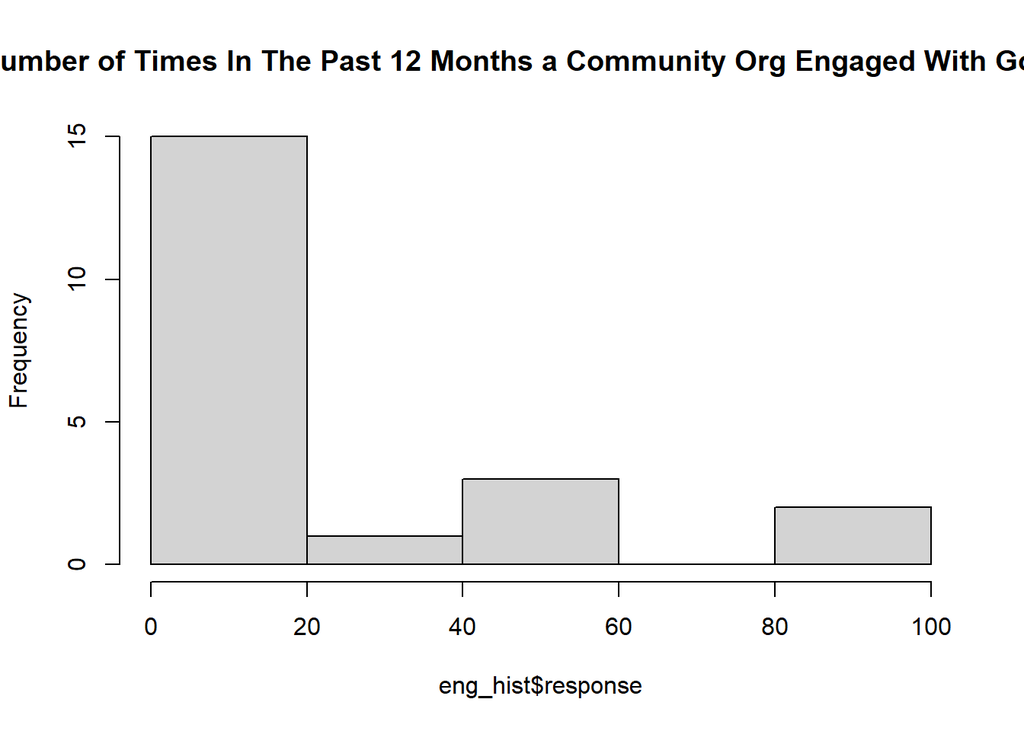

###### By Organization Type

| org_type | base_size | avg |
| --- | --- | --- |
| Charity | 1 | 56 |
| Community-Based | 2 | 15 |
| Foundation | 4 | 17 |
| Grassroots | 2 | 14 |
| Not-for-profit | 15 | 28 |
| Political Organization | 1 | NaN |

###### By Focal Area

| focal_areas | base_size | avg |
| --- | --- | --- |
| Education and Schools | 15 | 27 |
| Youth Development | 15 | 28 |
| Civil Rights, Social Action and Advocacy | 12 | 27 |
| Civic and Community | 10 | 29 |
| Arts, Culture and Humanities | 6 | 45 |
| Human Services | 5 | 10 |
| Other (Please Specify) | 4 | 44 |
| Health | 3 | 39 |
| Legal Services | 2 | 35 |
| Public Safety, Disaster Preparedness, and Response | 2 | 36 |

[output cut: 2 more lines]

##### Org Q21. Does your organization create opportunities for community members to engage with local leaders on issues important to them?

###### All Organizations

| response | count | perc |
| --- | --- | --- |
| No | 3 | 12% |
| Yes | 19 | 76% |
| NA | 3 | 12% |

###### By Organization Type

| org_type | base_size | No | Yes |
| --- | --- | --- | --- |
| Charity | 1 | NA | 100% |
| Community-Based | 2 | NA | 100% |
| Foundation | 4 | NA | 100% |
| Grassroots | 2 | NA | 100% |
| Not-for-profit | 13 | 23.08% | 76.92% |